# Analysis with Missing Data

2023-03-29

To do:

- post-hoc power analyses
- figure out logistic regression interaction analyses
- add effect sizes to simple effects analyses

# Data Import & Cleaning

## Import data

```r
raw_psych_hum_subj <- import("data/raw/raw_psych_hum_subj.csv")
raw_mktg_hum_subj <- import("data/raw/raw_mktg_hum_subj.csv")
raw_gen_uo_pop <- import("data/raw/raw_gen_uo_pop.csv")
pre_fall22 <- import("data/prescreen/dittersdorf_matches_f22.csv")
pre_winter23 <- import("data/prescreen/dittersdorf_matches_w23.csv")
pre_spring23 <- import("data/prescreen/dittersdorf_matches_s23.csv")
participant_list <- import("data/prescreen/dittersdorf_participants.csv")
```

## Change variables types

```r
raw_psych_hum_subj <- raw_psych_hum_subj %>%
  mutate(Age = as.integer(Age),
         Gender = as.factor(Gender),
         framing_condition_DO = as.factor(framing_condition_DO),
         norm_condition_DO = as.factor(norm_condition_DO),
         consumer_behaviors = as.factor(consumer_behaviors),
         skepticism = as.factor(skepticism),
         id = as.factor(id))

raw_mktg_hum_subj <- raw_mktg_hum_subj %>%
  mutate(Age = as.integer(Age),
         Gender = as.factor(Gender),
         Gender_5_TEXT = as.character(Gender_5_TEXT),
         Class_Lvl_7_TEXT = as.character(Class_Lvl_7_TEXT),
         Pol_Ornt_8_TEXT = as.character(Pol_Ornt_8_TEXT),
         Ethnicity_8_TEXT = as.character(Ethnicity_8_TEXT),
         skept_open = as.character(skept_open),
         skepticism = as.factor(skepticism),
         id = as.factor(id),
         framing_condition_DO = as.factor(framing_condition_DO),
         norm_condition_DO = as.factor(norm_condition_DO),
         consumer_behaviors = as.factor(consumer_behaviors))

raw_gen_uo_pop <- raw_gen_uo_pop %>%
  mutate(Gender = as.factor(Gender),
         Gender_5_TEXT = as.character(Gender_5_TEXT),
         Class_Lvl_7_TEXT = as.character(Class_Lvl_7_TEXT),
         Pol_Ornt_8_TEXT = as.character(Pol_Ornt_8_TEXT),
         skept_open = as.character(skept_open),
         skepticism = as.factor(skepticism),
         id = as.factor(id),
         framing_condition_DO = as.factor(framing_condition_DO),
         norm_condition_DO = as.factor(norm_condition_DO),
         consumer_behaviors = as.factor(consumer_behaviors))
```

Variables from prescreen:

- Values:
  - respecting, unity, protecting, preventing, equality, peace, justice, helpful, power, wealth, authority, influential, ambition, pleasures, enjoying, gratification
- Socially Desirable Responding:
  - honest, like, disturbing, regret, lose-out, rational, confident, lover, lies, cover-up, advantage, get-even, behind-back, private-talk, take-things, gossip

## Combine prescreen data

Specify unique variables to combine prescreen data sets

```r
# Create unique full_name variable
pre_fall22$full_name <- paste(pre_fall22$first_name, pre_fall22$last_name, sep="_")

pre_winter23$full_name <- paste(pre_winter23$first_name, pre_winter23$last_name, sep="_")

pre_spring23$full_name <- paste(pre_spring23$first_name, pre_spring23$last_name, sep="_")

participant_list$full_name <- paste(participant_list$first_name, participant_list$last_name, sep="_")

# Create column indicating which data set rows came from

pre_fall22 <- pre_fall22 %>%
  mutate(term = "fall22")

pre_winter23 <- pre_winter23 %>%
  mutate(term = "winter23")

pre_spring23 <- pre_spring23 %>%
  mutate(term = "spring23")
```

Combine prescreen data

```r
combine1 <- smartbind(pre_fall22, pre_winter23)
combined_prescreen <- smartbind(combine1, pre_spring23)

# nrow(pre_fall22) + nrow(pre_winter23) + nrow(pre_spring23) # n = 1167

combined_prescreen_unique <- combined_prescreen[!duplicated(combined_prescreen$full_name), ] # keeps first row (fall22)
```

Subset key variables

```r
combined_prescreen_key <- combined_prescreen_unique %>%
  select(full_name, term, respecting:gratification, honest:gossip)

participant_list_key <- participant_list %>%
  select(full_name, survey_id)
```

Merge with participant list

```r
merged_prescreen <- merge(combined_prescreen_key, participant_list_key, by = "full_name")
```

Convert variable types in prescreen data

Rename values & socially desirable items in prescreen data to match names in main data:

## Combine all data

- First, combine Psych Hum Subj data with Prescreen data based on `id`
- Second, add Mktg Hum Subj data
- Third, add gen UO Pop data

```r
combine1 <- merge(raw_psych_hum_subj, merged_prescreen, by = "id")
combine2 <- smartbind(combine1, raw_mktg_hum_subj)
combine3 <- smartbind(combine2, raw_gen_uo_pop)
```

## Remove duplicate cases

Identify duplicate cases

```r
# first, add unique row #s
combine3 <- combine3 %>%
  mutate(row = 1:nrow(combine3))

combine3[duplicated(combine3$id),] # Only rows 1 through 858 have unique id #s

# write.csv(combine3, "combined_data.csv")
```

Row IDs to remove:

- 13 (participant’s second time completing study)
- 134 (participant didn’t complete study first time)
- 145 (participant didn’t complete study first time)
- 308 (participant’s second time completing study)
- 672 (participant’s second time completing study)
- 743 (participant didn’t complete study first time)
- 790 (participant didn’t complete study first time)
- 800 (participant didn’t complete study first time)

Remove duplicate rows after resolving:

```r
combine3 <- combine3 %>%
  filter(!row %in% c(13, 134, 145, 308, 672, 743, 790, 800))
```

## Remove rows of all NAs

Identify completely missing rows:

```r
key_vars <- combine3 %>%
  select(row, big_2_1:big_2_65, consumer_intentions_1:consumer_intentions_9, consumer_behaviors, clothing_interest_1:clothing_interest_20, ingroup_ident_1:ingroup_ident_14, values_1:values_16, socially_desirable_1:socially_desirable_16)

ncol(key_vars) # number of columns - the row # column = 141

all_NA_rows <- key_vars[rowSums(is.na(key_vars)) == 141,] # identify rows with 142 NAs (all missing values), row numbers are preserved

all_NA_rows
```

Removing rows of fully missing data

```r
data <- combine3 %>%
  filter(!row %in% c(859, 860, 900, 926, 927, 941, 1139, 1141, 1142, 1143, 1144, 1146, 1149, 1150, 1152)) %>% # remove rows containing all NAs
  select(-StartDate, -EndDate, -Status, -Progress, -"Duration (in seconds)", -Finished, -RecordedDate, -ResponseId, -DistributionChannel, -UserLanguage, -big_2_DO, -consumer_intentions_DO, -consumer_behaviors_DO, -clothing_interest_DO, -ingroup_ident_DO, -full_name, -code, -socially_desirable_DO, -values_DO, -email_giftcard, -term) # removing variables not in analysis
```

Rename variables

```r
data <- data %>%
  rename("framing_condition" = "framing_condition_DO",
         "norm_condition" = "norm_condition_DO")

levels(data$framing_condition)
```

```
## [1] ""                 "control_framing"  "pro_env_framing"  "self_enh_framing"
```

```r
levels(data$norm_condition)
```

```
## [1] ""                 "control_norm"     "convention_norm"  "descriptive_norm"
## [5] "moral_norm"       "social_norm"
```

```r
data$framing_condition <- droplevels(data$framing_condition)
data$norm_condition <- droplevels(data$norm_condition)

levels(data$framing_condition)
```

```
## [1] "control_framing"  "pro_env_framing"  "self_enh_framing"
```

```r
levels(data$norm_condition)
```

```
## [1] "control_norm"     "convention_norm"  "descriptive_norm" "moral_norm"
## [5] "social_norm"
```

```r
levels(data$skepticism)
```

```
## [1] "1" "2"
```

## Inspect final data

```r
str(data, list.len = ncol(data))

# write.csv(data, "final_data.csv")
```

# Outliers & Missingness

## Univariate Outliers

Detecting potential data entry outliers:

```
##                       vars    n   mean     sd median trimmed    mad min  max
## big_2_1                  1 1130   3.55   1.13      4    3.63   1.48   1    5
## big_2_2                  2 1127   4.24   0.82      4    4.36   1.48   1    5
## big_2_3                  3 1129   2.61   1.21      2    2.56   1.48   1    5
## big_2_4                  4 1130   2.98   1.18      3    2.99   1.48   1    5
## big_2_5                  5 1128   2.52   1.22      2    2.46   1.48   1    5
## big_2_6                  6 1125   3.08   1.15      3    3.09   1.48   1    5
## big_2_7                  7 1126   4.56   0.64      5    4.65   0.00   1    5
## big_2_8                  8 1128   2.99   1.10      3    3.04   1.48   1    5
## big_2_9                  9 1129   3.43   1.06      4    3.45   1.48   1    5
## big_2_10                10 1123   4.24   0.80      4    4.35   1.48   1    5
## big_2_11                11 1125   2.10   1.00      2    1.97   1.48   1    5
## big_2_12                12 1123   2.85   1.04      3    2.88   1.48   1    5
## big_2_13                13 1129   4.03   0.84      4    4.12   0.00   1    5
## big_2_14                14 1128   3.10   1.21      3    3.13   1.48   1    5
## big_2_15                15 1125   3.66   0.92      4    3.71   1.48   1    5
## big_2_16                16 1128   3.21   1.20      3    3.24   1.48   1    5
## big_2_17                17 1128   2.20   1.34      2    2.00   1.48   1    5
## big_2_18                18 1129   3.80   0.99      4    3.90   1.48   1    5
## big_2_19                19 1126   3.51   1.03      4    3.56   1.48   1    5
## big_2_20                20 1125   3.92   1.12      4    4.07   1.48   1    5
## big_2_21                21 1130   3.20   1.12      3    3.22   1.48   1    5
## big_2_22                22 1125   2.23   1.07      2    2.14   1.48   1    5
## big_2_23                23 1122   3.53   1.14      4    3.59   1.48   1    5
## big_2_24                24 1130   3.39   1.19      4    3.46   1.48   1    5
## big_2_25                25 1128   2.12   1.10      2    1.98   1.48   1    5
## big_2_26                26 1129   2.49   1.19      2    2.42   1.48   1    5
## big_2_27                27 1127   3.90   1.04      4    4.02   1.48   1    5
## big_2_28                28 1128   2.95   1.11      3    3.01   1.48   1    5
## big_2_29                29 1126   3.19   1.18      3    3.21   1.48   1    5
## big_2_30                30 1128   2.28   1.11      2    2.19   1.48   1    5
## big_2_31                31 1130   3.67   1.12      4    3.76   1.48   1    5
## big_2_32                32 1127   4.01   0.91      4    4.12   1.48   1    5
## big_2_33                33 1129   3.54   1.16      4    3.60   1.48   1    5
## big_2_34                34 1129   3.79   1.16      4    3.92   1.48   1    5
## big_2_35                35 1128   4.06   0.95      4    4.19   1.48   1    5
## big_2_36                36 1127   2.65   1.02      3    2.64   1.48   1    5
## big_2_37                37 1126   2.61   1.13      2    2.60   1.48   1    5
## big_2_38                38 1127   3.88   0.95      4    4.00   1.48   1    5
## big_2_39                39 1128   3.01   1.18      3    3.01   1.48   1    5
```

[output cut: 247 more lines]

```
## socially_desirable_3      6 -0.43    -0.74 0.05
## socially_desirable_4      6  0.68    -0.19 0.05
## socially_desirable_5      6 -0.34    -0.83 0.05
## socially_desirable_6      6 -0.27    -0.46 0.04
## socially_desirable_7      6 -0.40    -0.46 0.04
## socially_desirable_8      6 -0.49    -0.66 0.05
## socially_desirable_9      6 -0.71     0.06 0.04
## socially_desirable_10     6  0.40    -0.19 0.04
## socially_desirable_11     6  0.33    -1.05 0.05
## socially_desirable_12     6  0.24    -0.88 0.05
## socially_desirable_13     6 -0.47    -0.77 0.05
## socially_desirable_14     6  0.34    -0.69 0.05
## socially_desirable_15     6 -0.65    -0.63 0.05
## socially_desirable_16     6  0.35    -0.74 0.05
## row                    1155  0.01    -1.20 9.84
```

Check if any values fall outside of possible scale options.

Boxplots

Histograms

Demographics

Age

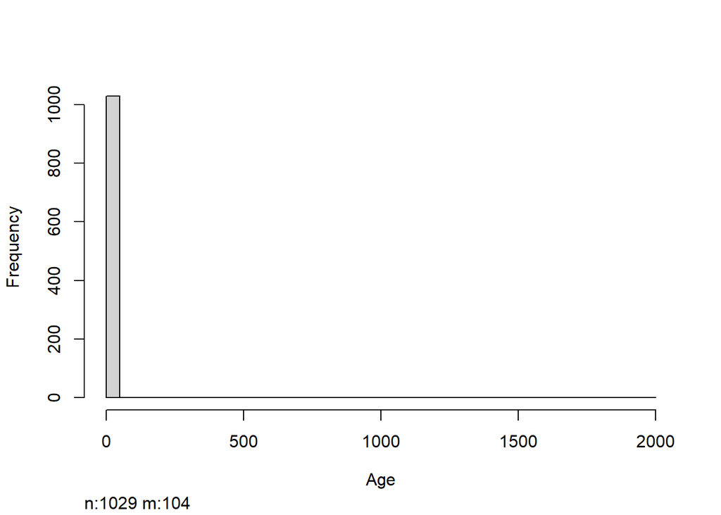

```
##    vars    n mean    sd median trimmed  mad min  max range  skew kurtosis   se
## X1    1 1029 21.8 61.73     19   19.67 1.48  18 1999  1981 31.94  1019.96 1.92
```

```
##           id big_2_1 big_2_2 big_2_3 big_2_4 big_2_5 big_2_6 big_2_7 big_2_8
## 1:1053 43012       2       2       4       4       2       3       4       4
##        big_2_9 big_2_10 big_2_11 big_2_12 big_2_13 big_2_14 big_2_15 big_2_16
## 1:1053       4        4        2        4        4        3        3        5
##        big_2_17 big_2_18 big_2_19 big_2_20 big_2_21 big_2_22 big_2_23 big_2_24
## 1:1053        3        4        5        4        3        3        4        5
##        big_2_25 big_2_26 big_2_27 big_2_28 big_2_29 big_2_30 big_2_31 big_2_32
## 1:1053        3        4        3        4        3        4        4        1
##        big_2_33 big_2_34 big_2_35 big_2_36 big_2_37 big_2_38 big_2_39 big_2_40
## 1:1053        4        4        3        3        3        3        3        4
##        big_2_41 big_2_42 big_2_43 big_2_44 big_2_45 big_2_46 big_2_47 big_2_48
## 1:1053        2        4        3        4        3        2        5        3
##        big_2_49 big_2_50 big_2_51 big_2_52 big_2_53 big_2_54 big_2_55 big_2_56
## 1:1053        2        2        4        4        3        3        2        3
##        big_2_57 big_2_58 big_2_59 big_2_60 big_2_61 big_2_62 big_2_63 big_2_64
## 1:1053        2        4        3        2        4        4        1        3
##        big_2_65 consumer_intentions_1 consumer_intentions_2
## 1:1053        4                     2                     5
##        consumer_intentions_3 consumer_intentions_4 consumer_intentions_5
## 1:1053                     2                     6                     2
##        consumer_intentions_6 consumer_intentions_7 consumer_intentions_8
## 1:1053                     1                     7                     1
##        consumer_intentions_9 consumer_behaviors clothing_interest_1
## 1:1053                     7                  1                   4
##        clothing_interest_2 clothing_interest_3 clothing_interest_4
## 1:1053                   4                   3                   4
##        clothing_interest_5 clothing_interest_6 clothing_interest_7
## 1:1053                   2                   3                   1
##        clothing_interest_8 clothing_interest_9 clothing_interest_10
## 1:1053                   4                   5                    3
##        clothing_interest_11 clothing_interest_12 clothing_interest_13
## 1:1053                    4                    2                    4
##        clothing_interest_14 clothing_interest_15 clothing_interest_16
## 1:1053                    1                    2                    2
##        clothing_interest_17 clothing_interest_18 clothing_interest_19
## 1:1053                    4                    1                    2
##        clothing_interest_20 ingroup_ident_1 ingroup_ident_2 ingroup_ident_3
## 1:1053                    2               1               1               2
##        ingroup_ident_4 ingroup_ident_5 ingroup_ident_6 ingroup_ident_7
## 1:1053               4               4               4               4
```

[output cut: 11 more lines]

```
## 1:1053  self_enh_framing     moral_norm        2        0        1        1
##        values_5 values_6 values_7 values_8 values_9 values_10 values_11
## 1:1053        1        2        1        0        3         3         3
##        values_12 values_13 values_14 values_15 values_16 socially_desirable_1
## 1:1053         1         1         1         2         2                    5
##        socially_desirable_2 socially_desirable_3 socially_desirable_4
## 1:1053                    7                    5                    4
##        socially_desirable_5 socially_desirable_6 socially_desirable_7
## 1:1053                    3                    5                    6
##        socially_desirable_8 socially_desirable_9 socially_desirable_10
## 1:1053                    5                    6                     6
##        socially_desirable_11 socially_desirable_12 socially_desirable_13
## 1:1053                     5                     4                     4
##        socially_desirable_14 socially_desirable_15 socially_desirable_16  row
## 1:1053                     2                     5                     3 1053
```

```
##        Age
## 1:1053  24
```

Income

- 1 = $0-9,999
- 2 = $10,000 - 19,999
- 3 = $20,000 - 29,999
- 4 = $30,000 - 39,999
- 5 = $40,000 - 49.999
- 6 = $50,000 - 59,999
- 7 = $60,000 - 69,999
- 8 = $70,000 - 79,999
- 9 = $80,000 - 89,999
- 10 = $90,000 - 99,999
- 11 = $100,000 or more

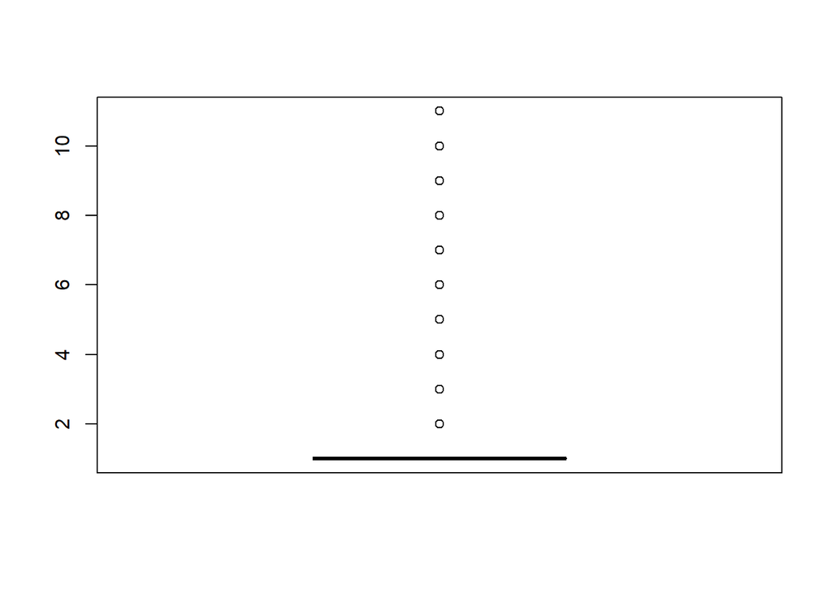

```r
data %>%
  select(Income) %>%
  boxplot()
```

```r
describe(data$Income)
```

```
##    vars    n mean   sd median trimmed mad min max range skew kurtosis   se
## X1    1 1133 1.63 1.78      1    1.16   0   1  11    10  3.9    15.67 0.05
```

```r
table(data$Income)
```

```
##
##   1   2   3   4   5   6   7   8   9  10  11
## 876 143  36  18  10   5  10   6   6   1  22
```

```r
data %>%
  filter(Income == 11 | Income == 10 | Income == 9 | Income == 8 | Income == 7) %>%
  select(Income, Age, Employment, Class_Lvl)
```

```
##        Income Age Employment Class_Lvl
## 1:28       11  21          3         4
## 1:41        7  20          2         3
## 1:60       11  21          3         3
## 1:146      11  20          4         2
## 1:149      10  20          4         2
## 1:164      11  20          4         2
## 1:184      11  20          4         1
## 1:195       7  19          1         2
## 1:211      11  18          3         1
## 1:226       8  19          3         1
## 1:241       7  18          3         1
## 1:261      11  18          4         1
## 1:282      11  21          1         2
## 1:284       9  NA          4         1
## 1:295      11  20          3         3
## 1:299       9  18          4         1
## 1:350       7  NA          3         1
## 1:352       9  50          2         6
## 1:423      11  18          4         1
## 1:429       8  NA          4         1
## 1:443       8  19          3         1
## 1:526      11  19          1         1
## 1:588      11  18          3         1
## 1:605      11  19          3         1
## 1:639      11  19          3         1
## 1:641       9  NA          3         1
## 1:651       7  22          1         4
## 1:661      11  19          3         1
## 1:689      11  19          4         1
## 1:704      11  18          4         1
## 1:723       7  18          4         1
## 1:759      11  19          4         1
## 1:782      11  18          3         1
## 1:797      11  18          4         1
## 1:802       7  18          3         1
## 1:932       9  22          1         4
## 1:948       8  22          1         4
## 1:950       7  22          1         4
## 1:951       7  22          2         4
## 1:1013     11  25          4         5
## 1:1074      7  21          1         4
## 1:1130     11  22          4         3
## 1:1134      9  22          2         4
## 2:2         8  28          2         2
## 2:6         8  20          1         3
```

Employment

- 1 = Employed, working 1-39 hrs/wk
- 2 = Employed, working 40+ hrs/wk
- 3 = Not employed, looking for work
- 4 = Not employed, NOT looking for work
- 5 = Retired
- 6 = Not able to work

Class Level

- 1 = Freshman
- 2 = Sophomore
- 3 = Junior
- 4 = Senior
- 5 = Graduate student
- 6 = Not applicable
- 7 = Other

Gender

- 1 = woman
- 2 = man
- 3 = non-binary
- 4 = I prefer not to identify
- 5 = other (please specify)

```r
levels(data$Gender) <- c("Woman", "Man", "Non-binary", "I prefer not to identify", "Other")

table(data$Gender)
```

```
##
##                    Woman                      Man               Non-binary
##                      674                      418                       24
## I prefer not to identify                    Other
##                       11                        6
```

```r
data %>%
  filter(Gender == 5) %>%
  select(Gender_5_TEXT)
```

```
## [1] Gender_5_TEXT
## <0 rows> (or 0-length row.names)
```

## Missing Values

### Consumer Intentions & Behaviors

### Clothing Interest

```r
data %>%
  select(clothing_interest_1:clothing_interest_20) %>%
  vis_miss()
```

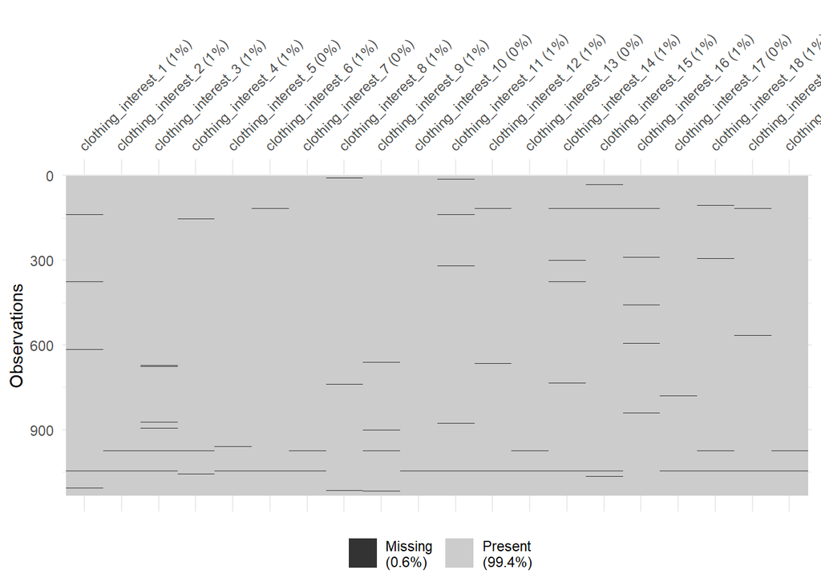

### Ingroup Identification

```r
data %>%
  select(ingroup_ident_1:ingroup_ident_14) %>%
  vis_miss()
```

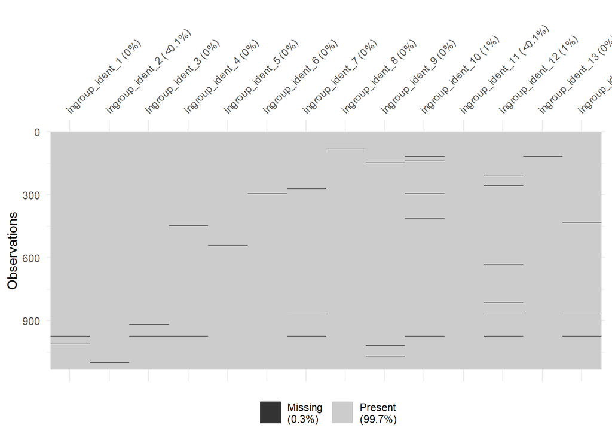

### Values

```r
data %>%
  select(values_1:values_16) %>%
  vis_miss()
```

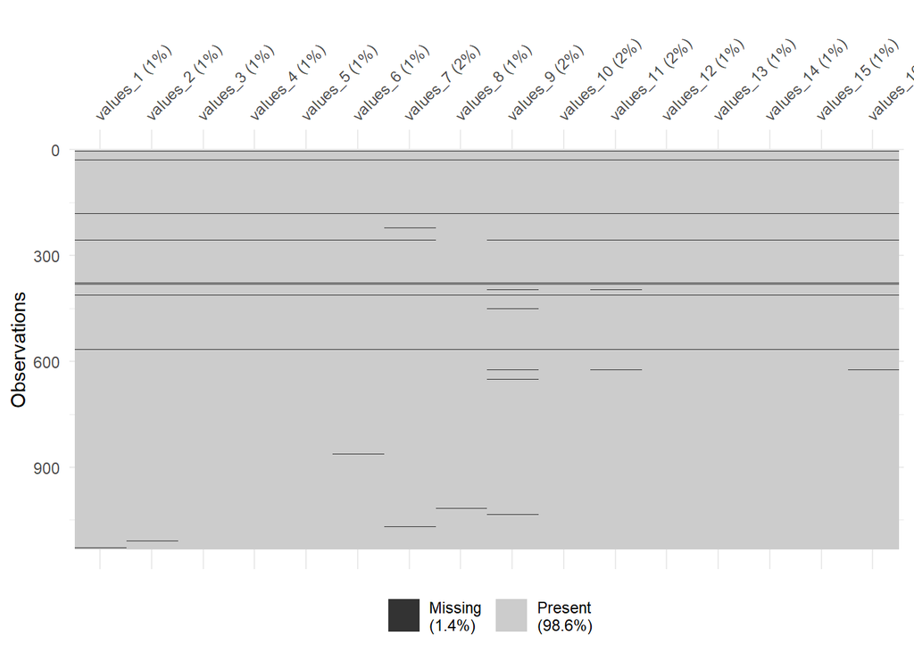

### Socially Desirable Responding

```r
data %>%
  select(socially_desirable_1:socially_desirable_16) %>%
  vis_miss()
```

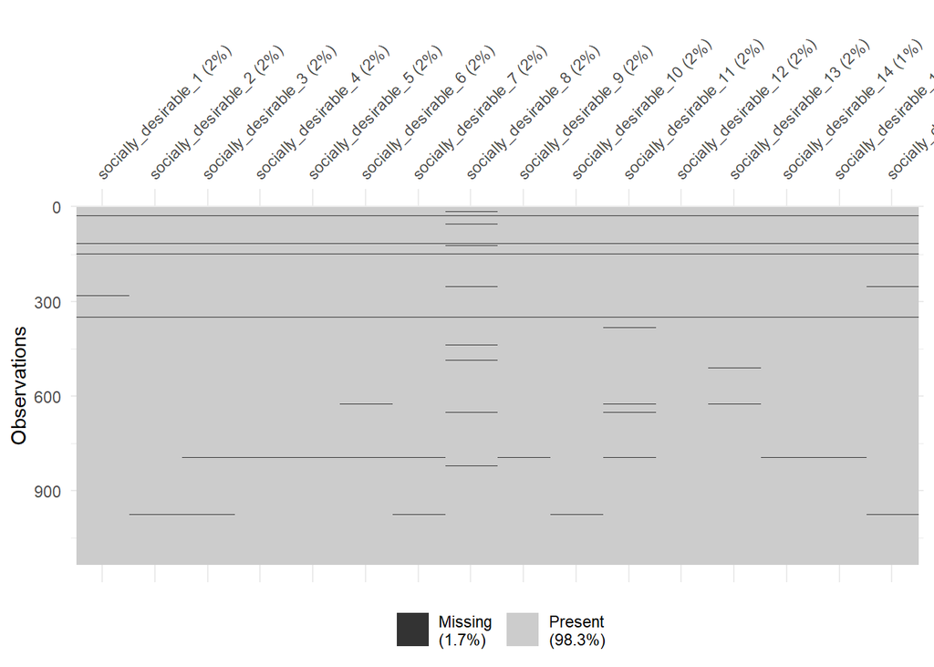

### Demographics

```r
data %>%
  select(Age, Gender, Income) %>%
  vis_miss()
```

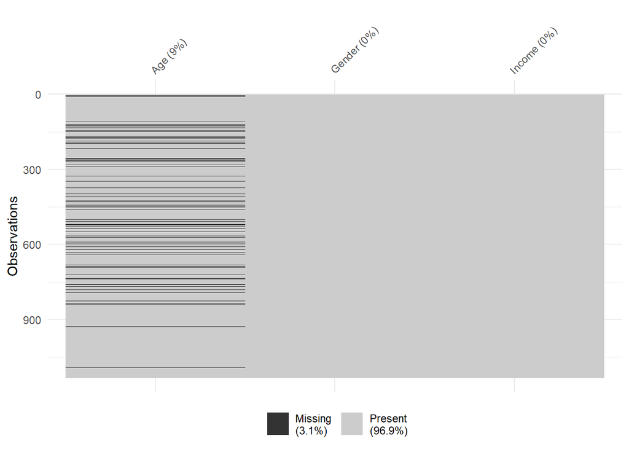

### Personality

```r
data %>%
  select(big_2_1:big_2_65) %>%
  vis_miss()
```

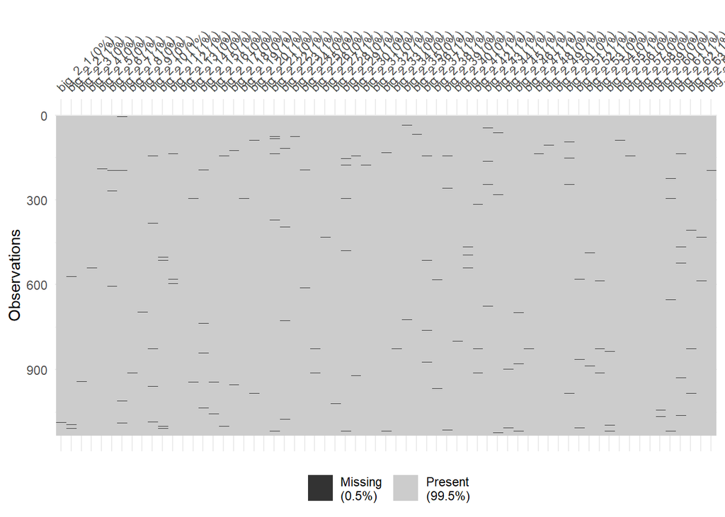

### All variables

```r
data %>%
  select(consumer_intentions_1:consumer_behaviors, clothing_interest_1:clothing_interest_20, ingroup_ident_1:ingroup_ident_14, values_1:values_16, socially_desirable_1:socially_desirable_16, Age, Gender, Income, big_2_1:big_2_65) %>%
  vis_miss(sort_miss = TRUE)
```

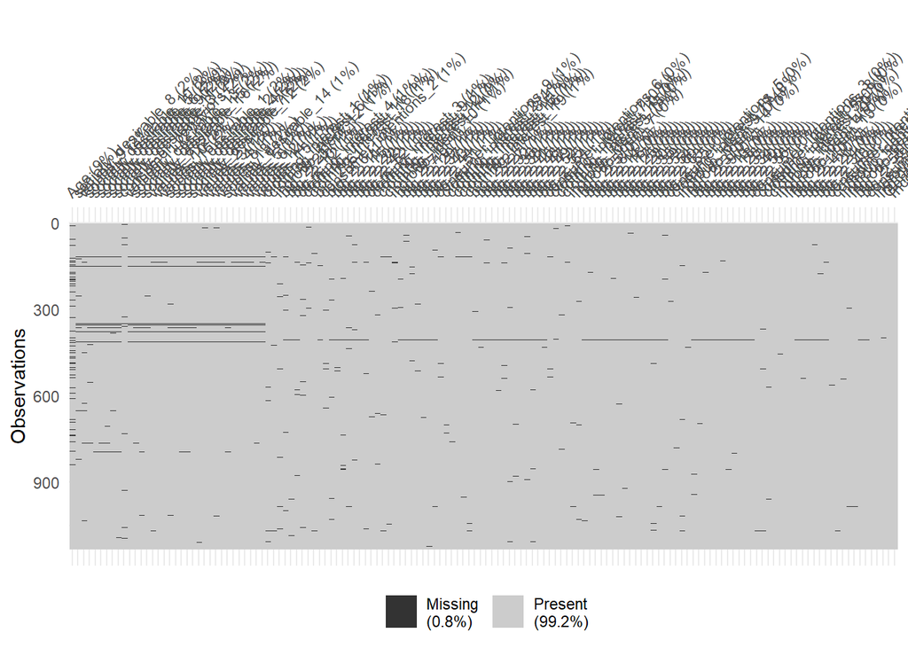

Less than 1% of total data is missing (0.8% missing).

### MCAR Test

A non-significant test suggests the data *is* missing completely at random.

```r
test_of_mcar <- data %>%
  select(consumer_intentions_1:consumer_behaviors, clothing_interest_1:clothing_interest_20, ingroup_ident_1:ingroup_ident_14, values_1:values_16, socially_desirable_1:socially_desirable_16, Age, Gender, Income, big_2_1:big_2_65) %>%
  mcar_test()

test_of_mcar$statistic
test_of_mcar$df # Critical values are 8565.53 and 9086.26
test_of_mcar$p.value
```

[output not shown]

# Aggregate Variables

## Personality

### Reverse-code

```r
data_R <- data %>%
  mutate(across(c(big_2_11,
                  big_2_16,
                  big_2_26,
                  big_2_31,
                  big_2_36,
                  big_2_51,
                  big_2_12,
                  big_2_17,
                  big_2_22,
                  big_2_37,
                  big_2_42,
                  big_2_47,
                  big_2_3,
                  big_2_8,
                  big_2_23,
                  big_2_28,
                  big_2_48,
                  big_2_58,
                  big_2_4,
                  big_2_9,
                  big_2_24,
                  big_2_29,
                  big_2_44,
                  big_2_49,
                  big_2_5,
                  big_2_25,
                  big_2_30,
                  big_2_45,
                  big_2_50,
                  big_2_55,
                  big_2_63), ~6 - .)) # replace '6' with the max possible value plus 1 for any particular scale
```

### Average items

```r
data_R$extraversion <- data_R %>%
  select(big_2_1, big_2_6, big_2_11, big_2_16, big_2_21, big_2_26, big_2_31, big_2_36, big_2_41, big_2_46, big_2_51, big_2_56) %>%
  rowMeans(na.rm = TRUE)


data_R$conscientiousness <- data_R %>%
  select(big_2_3, big_2_8, big_2_13, big_2_18, big_2_23, big_2_28, big_2_33, big_2_38, big_2_43, big_2_48, big_2_53, big_2_58) %>%
  rowMeans(na.rm = TRUE)


data_R$agreeableness <- data_R %>%
  select(big_2_2, big_2_7, big_2_12, big_2_17, big_2_22, big_2_27, big_2_32, big_2_37, big_2_42, big_2_47, big_2_52, big_2_57) %>%
  rowMeans(na.rm = TRUE)


data_R$neuroticism <- data_R %>%
  select(big_2_4, big_2_9, big_2_14, big_2_19, big_2_24, big_2_29, big_2_34, big_2_39, big_2_44, big_2_49, big_2_54, big_2_59) %>%
  rowMeans(na.rm = TRUE)


data_R$openness <- data_R %>%
  select(big_2_5, big_2_10, big_2_15, big_2_20, big_2_25, big_2_30, big_2_35, big_2_40, big_2_45, big_2_50, big_2_55, big_2_60) %>%
  rowMeans(na.rm = TRUE)


data_R$honesty <- data_R %>%
  select(big_2_61, big_2_62, big_2_63, big_2_64, big_2_65) %>%
  rowMeans(na.rm = TRUE)
```

### Scale reliability

```
##
## Reliability analysis
## Call: alpha(x = .)
##
##   raw_alpha std.alpha G6(smc) average_r S/N    ase mean   sd median_r
##       0.85      0.85    0.87      0.32 5.6 0.0065  3.3 0.68     0.29
##
##     95% confidence boundaries
##          lower alpha upper
## Feldt     0.84  0.85  0.86
## Duhachek  0.84  0.85  0.86
##
##  Reliability if an item is dropped:
##          raw_alpha std.alpha G6(smc) average_r S/N alpha se var.r med.r
## big_2_1       0.82      0.82    0.84      0.30 4.7   0.0077 0.017  0.27
## big_2_6       0.84      0.84    0.86      0.32 5.2   0.0070 0.021  0.29
## big_2_11      0.85      0.85    0.87      0.34 5.7   0.0065 0.020  0.31
## big_2_16      0.83      0.83    0.84      0.30 4.8   0.0076 0.018  0.27
## big_2_21      0.83      0.83    0.85      0.31 5.0   0.0072 0.021  0.27
## big_2_26      0.85      0.85    0.87      0.34 5.8   0.0063 0.021  0.32
## big_2_31      0.84      0.84    0.85      0.32 5.1   0.0072 0.020  0.28
## big_2_36      0.85      0.85    0.87      0.33 5.5   0.0067 0.023  0.31
## big_2_41      0.84      0.83    0.85      0.31 5.0   0.0072 0.021  0.27
## big_2_46      0.83      0.83    0.85      0.31 4.9   0.0074 0.018  0.28
## big_2_51      0.84      0.84    0.86      0.33 5.4   0.0068 0.021  0.31
## big_2_56      0.84      0.84    0.86      0.32 5.2   0.0070 0.021  0.29
##
##  Item statistics
##             n raw.r std.r r.cor r.drop mean  sd
## big_2_1  1130  0.78  0.78  0.78   0.72  3.6 1.1
## big_2_6  1125  0.61  0.60  0.55   0.51  3.1 1.2
## big_2_11 1125  0.44  0.46  0.38   0.33  3.9 1.0
## big_2_16 1128  0.75  0.74  0.74   0.67  2.8 1.2
## big_2_21 1130  0.66  0.66  0.63   0.58  3.2 1.1
## big_2_26 1129  0.44  0.44  0.35   0.32  3.5 1.2
## big_2_31 1130  0.65  0.64  0.61   0.56  2.3 1.1
## big_2_36 1127  0.50  0.51  0.43   0.40  3.4 1.0
## big_2_41 1127  0.66  0.66  0.63   0.57  3.4 1.0
## big_2_46 1127  0.71  0.71  0.69   0.63  3.5 1.1
## big_2_51 1126  0.56  0.55  0.50   0.45  3.0 1.1
## big_2_56 1129  0.60  0.61  0.57   0.51  3.6 1.0
##
## Non missing response frequency for each item
##             1    2    3    4    5 miss
## big_2_1  0.05 0.15 0.19 0.40 0.21 0.00
## big_2_6  0.09 0.26 0.24 0.31 0.10 0.01
## big_2_11 0.02 0.10 0.14 0.43 0.30 0.01
## big_2_16 0.15 0.33 0.20 0.25 0.08 0.00
## big_2_21 0.08 0.20 0.27 0.34 0.11 0.00
## big_2_26 0.05 0.20 0.19 0.33 0.24 0.00
## big_2_31 0.24 0.43 0.14 0.15 0.04 0.00
## big_2_36 0.04 0.18 0.28 0.39 0.11 0.01
## big_2_41 0.03 0.20 0.28 0.37 0.13 0.01
## big_2_46 0.04 0.17 0.21 0.38 0.21 0.01
## big_2_51 0.09 0.28 0.26 0.29 0.09 0.01
## big_2_56 0.02 0.13 0.22 0.43 0.19 0.00
```

```
##
## Reliability analysis
## Call: alpha(x = .)
##
##   raw_alpha std.alpha G6(smc) average_r S/N    ase mean   sd median_r
##       0.84      0.84    0.86      0.31 5.4 0.0069  3.5 0.63     0.28
##
##     95% confidence boundaries
##          lower alpha upper
## Feldt     0.83  0.84  0.86
## Duhachek  0.83  0.84  0.86
##
##  Reliability if an item is dropped:
##          raw_alpha std.alpha G6(smc) average_r S/N alpha se  var.r med.r
## big_2_3       0.82      0.82    0.83      0.29 4.6   0.0080 0.0103  0.27
## big_2_8       0.83      0.83    0.85      0.31 5.0   0.0073 0.0139  0.28
## big_2_13      0.83      0.83    0.84      0.31 5.0   0.0072 0.0120  0.29
## big_2_18      0.83      0.83    0.85      0.31 4.8   0.0075 0.0120  0.28
## big_2_23      0.83      0.84    0.85      0.32 5.1   0.0072 0.0129  0.29
## big_2_28      0.83      0.83    0.85      0.31 5.1   0.0072 0.0136  0.29
## big_2_33      0.82      0.82    0.83      0.29 4.6   0.0079 0.0096  0.27
## big_2_38      0.83      0.83    0.84      0.30 4.7   0.0076 0.0133  0.27
## big_2_43      0.84      0.84    0.84      0.32 5.1   0.0072 0.0116  0.29
## big_2_48      0.83      0.83    0.85      0.31 5.0   0.0074 0.0124  0.29
## big_2_53      0.83      0.83    0.85      0.31 4.9   0.0074 0.0138  0.27
## big_2_58      0.84      0.84    0.85      0.32 5.2   0.0070 0.0127  0.29
##
##  Item statistics
##             n raw.r std.r r.cor r.drop mean   sd
## big_2_3  1129  0.73  0.71  0.70   0.65  3.4 1.21
## big_2_8  1128  0.60  0.58  0.53   0.49  3.0 1.10
## big_2_13 1129  0.54  0.58  0.54   0.46  4.0 0.84
## big_2_18 1129  0.62  0.63  0.59   0.54  3.8 0.99
## big_2_23 1122  0.57  0.55  0.49   0.45  2.5 1.14
## big_2_28 1128  0.57  0.56  0.50   0.46  3.0 1.11
## big_2_33 1129  0.73  0.71  0.71   0.64  3.5 1.16
## big_2_38 1127  0.65  0.66  0.62   0.56  3.9 0.95
## big_2_43 1126  0.52  0.56  0.51   0.43  4.1 0.83
## big_2_48 1130  0.60  0.59  0.54   0.50  4.0 1.03
## big_2_53 1128  0.61  0.62  0.57   0.52  3.8 1.02
## big_2_58 1131  0.52  0.51  0.44   0.40  2.8 1.10
##
## Non missing response frequency for each item
##             1    2    3    4    5 miss
## big_2_3  0.06 0.22 0.19 0.32 0.21 0.00
## big_2_8  0.06 0.33 0.25 0.26 0.10 0.00
## big_2_13 0.01 0.05 0.14 0.50 0.30 0.00
## big_2_18 0.02 0.10 0.20 0.43 0.25 0.00
## big_2_23 0.20 0.42 0.15 0.19 0.04 0.01
## big_2_28 0.04 0.37 0.20 0.29 0.10 0.00
## big_2_33 0.04 0.19 0.18 0.36 0.23 0.00
## big_2_38 0.02 0.09 0.16 0.48 0.26 0.01
## big_2_43 0.01 0.04 0.12 0.48 0.36 0.01
## big_2_48 0.02 0.09 0.13 0.36 0.40 0.00
## big_2_53 0.02 0.14 0.17 0.44 0.24 0.00
## big_2_58 0.07 0.46 0.19 0.20 0.08 0.00
```

```
##
## Reliability analysis
## Call: alpha(x = .)
##
##   raw_alpha std.alpha G6(smc) average_r S/N    ase mean   sd median_r
##       0.78      0.79    0.81      0.24 3.9 0.0097  3.8 0.55     0.24
##
##     95% confidence boundaries
##          lower alpha upper
## Feldt     0.76  0.78   0.8
## Duhachek  0.76  0.78   0.8
##
##  Reliability if an item is dropped:
##          raw_alpha std.alpha G6(smc) average_r S/N alpha se var.r med.r
## big_2_2       0.76      0.77    0.78      0.24 3.4   0.0106 0.013  0.24
## big_2_7       0.76      0.78    0.79      0.24 3.5   0.0103 0.013  0.24
## big_2_12      0.76      0.78    0.79      0.25 3.6   0.0105 0.015  0.24
## big_2_17      0.80      0.80    0.81      0.27 4.1   0.0089 0.012  0.27
## big_2_22      0.76      0.78    0.79      0.24 3.6   0.0105 0.015  0.24
## big_2_27      0.75      0.77    0.78      0.24 3.4   0.0108 0.014  0.24
## big_2_32      0.77      0.78    0.80      0.25 3.6   0.0102 0.014  0.24
## big_2_37      0.75      0.77    0.78      0.24 3.4   0.0109 0.014  0.24
## big_2_42      0.78      0.79    0.80      0.26 3.9   0.0098 0.012  0.24
## big_2_47      0.75      0.77    0.78      0.24 3.4   0.0110 0.015  0.24
## big_2_52      0.76      0.77    0.78      0.24 3.4   0.0104 0.012  0.24
## big_2_57      0.75      0.77    0.78      0.23 3.3   0.0110 0.014  0.23
##
##  Item statistics
##             n raw.r std.r r.cor r.drop mean   sd
## big_2_2  1127  0.58  0.62  0.59   0.49  4.2 0.82
## big_2_7  1126  0.51  0.58  0.54   0.44  4.6 0.64
## big_2_12 1123  0.56  0.54  0.47   0.44  3.2 1.04
## big_2_17 1128  0.38  0.33  0.22   0.19  3.8 1.34
## big_2_22 1125  0.56  0.54  0.48   0.43  3.8 1.07
## big_2_27 1127  0.62  0.62  0.58   0.50  3.9 1.04
## big_2_32 1127  0.48  0.52  0.44   0.37  4.0 0.91
## big_2_37 1126  0.63  0.61  0.57   0.50  3.4 1.13
## big_2_42 1125  0.45  0.41  0.33   0.30  2.6 1.09
## big_2_47 1127  0.65  0.62  0.58   0.53  3.7 1.15
## big_2_52 1127  0.54  0.60  0.58   0.46  4.4 0.65
## big_2_57 1129  0.65  0.64  0.60   0.53  3.5 1.11
##
## Non missing response frequency for each item
##             1    2    3    4    5 miss
## big_2_2  0.01 0.03 0.11 0.42 0.43 0.01
## big_2_7  0.00 0.01 0.03 0.33 0.62 0.01
## big_2_12 0.03 0.28 0.27 0.32 0.09 0.01
## big_2_17 0.10 0.11 0.10 0.28 0.41 0.00
## big_2_22 0.02 0.14 0.18 0.38 0.29 0.01
## big_2_27 0.02 0.11 0.14 0.41 0.32 0.01
## big_2_32 0.02 0.04 0.14 0.50 0.30 0.01
## big_2_37 0.03 0.25 0.21 0.34 0.18 0.01
## big_2_42 0.13 0.42 0.21 0.19 0.05 0.01
## big_2_47 0.02 0.19 0.16 0.34 0.29 0.01
## big_2_52 0.00 0.01 0.05 0.42 0.52 0.01
## big_2_57 0.04 0.19 0.19 0.38 0.20 0.00
```

```
##
## Reliability analysis
## Call: alpha(x = .)
##
##   raw_alpha std.alpha G6(smc) average_r S/N    ase mean   sd median_r
##       0.89      0.89     0.9       0.4 8.1 0.0048  3.1 0.78     0.39
##
##     95% confidence boundaries
##          lower alpha upper
## Feldt     0.88  0.89   0.9
## Duhachek  0.88  0.89   0.9
##
##  Reliability if an item is dropped:
##          raw_alpha std.alpha G6(smc) average_r S/N alpha se  var.r med.r
## big_2_4       0.88      0.88    0.89      0.40 7.2   0.0053 0.0103  0.38
## big_2_9       0.89      0.89    0.90      0.42 7.9   0.0049 0.0093  0.41
## big_2_14      0.88      0.88    0.89      0.40 7.3   0.0053 0.0101  0.39
## big_2_19      0.89      0.89    0.90      0.42 7.9   0.0049 0.0087  0.41
## big_2_24      0.88      0.88    0.89      0.41 7.6   0.0051 0.0103  0.39
## big_2_29      0.88      0.88    0.88      0.39 7.0   0.0054 0.0090  0.37
## big_2_34      0.88      0.88    0.89      0.40 7.2   0.0053 0.0098  0.38
## big_2_39      0.88      0.88    0.88      0.39 7.1   0.0053 0.0086  0.38
## big_2_44      0.88      0.88    0.89      0.41 7.5   0.0051 0.0090  0.39
## big_2_49      0.88      0.88    0.89      0.40 7.4   0.0051 0.0097  0.39
## big_2_54      0.88      0.88    0.88      0.39 7.2   0.0053 0.0086  0.39
## big_2_59      0.88      0.88    0.89      0.40 7.5   0.0051 0.0091  0.39
##
##  Item statistics
##             n raw.r std.r r.cor r.drop mean  sd
## big_2_4  1130  0.71  0.71  0.68   0.64  3.0 1.2
## big_2_9  1129  0.57  0.57  0.51   0.48  2.6 1.1
## big_2_14 1128  0.71  0.70  0.67   0.63  3.1 1.2
## big_2_19 1126  0.55  0.56  0.50   0.47  3.5 1.0
## big_2_24 1130  0.64  0.63  0.58   0.55  2.6 1.2
## big_2_29 1126  0.76  0.76  0.74   0.70  2.8 1.2
## big_2_34 1129  0.71  0.71  0.68   0.64  3.8 1.2
## big_2_39 1128  0.73  0.73  0.72   0.67  3.0 1.2
## big_2_44 1126  0.64  0.64  0.61   0.57  2.5 1.1
## big_2_49 1127  0.67  0.67  0.63   0.59  3.8 1.2
## big_2_54 1128  0.73  0.72  0.71   0.66  2.9 1.2
## big_2_59 1131  0.66  0.65  0.62   0.57  2.9 1.2
##
## Non missing response frequency for each item
##             1    2    3    4    5 miss
## big_2_4  0.10 0.29 0.23 0.27 0.11 0.00
## big_2_9  0.14 0.41 0.23 0.19 0.03 0.00
## big_2_14 0.11 0.25 0.19 0.34 0.11 0.00
## big_2_19 0.04 0.16 0.18 0.49 0.13 0.01
## big_2_24 0.17 0.38 0.19 0.18 0.08 0.00
## big_2_29 0.14 0.32 0.21 0.26 0.08 0.01
## big_2_34 0.05 0.13 0.13 0.37 0.32 0.00
## big_2_39 0.10 0.28 0.22 0.30 0.10 0.00
## big_2_44 0.17 0.41 0.22 0.16 0.03 0.01
## big_2_49 0.04 0.12 0.13 0.36 0.34 0.01
## big_2_54 0.15 0.26 0.21 0.28 0.10 0.00
## big_2_59 0.13 0.28 0.21 0.28 0.10 0.00
```

```
##
## Reliability analysis
## Call: alpha(x = .)
##
##   raw_alpha std.alpha G6(smc) average_r S/N    ase mean   sd median_r
##       0.83      0.83    0.84      0.29 4.9 0.0075  3.8 0.62     0.28
##
##     95% confidence boundaries
##          lower alpha upper
## Feldt     0.81  0.83  0.84
## Duhachek  0.81  0.83  0.84
##
##  Reliability if an item is dropped:
##          raw_alpha std.alpha G6(smc) average_r S/N alpha se  var.r med.r
## big_2_5       0.81      0.82    0.82      0.29 4.5   0.0082 0.0086  0.28
## big_2_10      0.81      0.82    0.82      0.29 4.4   0.0082 0.0097  0.28
## big_2_15      0.82      0.83    0.83      0.30 4.8   0.0077 0.0076  0.28
## big_2_20      0.81      0.81    0.82      0.28 4.3   0.0085 0.0072  0.28
## big_2_25      0.82      0.82    0.83      0.29 4.6   0.0080 0.0094  0.28
## big_2_30      0.81      0.81    0.82      0.28 4.3   0.0084 0.0087  0.28
## big_2_35      0.81      0.81    0.82      0.28 4.3   0.0084 0.0079  0.27
## big_2_40      0.82      0.82    0.83      0.29 4.6   0.0079 0.0093  0.28
## big_2_45      0.82      0.82    0.83      0.30 4.7   0.0079 0.0096  0.29
## big_2_50      0.82      0.82    0.83      0.30 4.7   0.0079 0.0079  0.28
## big_2_55      0.81      0.82    0.83      0.29 4.5   0.0081 0.0098  0.28
## big_2_60      0.82      0.82    0.83      0.29 4.5   0.0081 0.0092  0.28
##
##  Item statistics
##             n raw.r std.r r.cor r.drop mean   sd
## big_2_5  1128  0.63  0.61  0.56   0.51  3.5 1.22
## big_2_10 1123  0.60  0.63  0.58   0.52  4.2 0.80
## big_2_15 1125  0.47  0.50  0.43   0.36  3.7 0.92
## big_2_20 1125  0.68  0.66  0.64   0.58  3.9 1.12
## big_2_25 1128  0.57  0.56  0.50   0.45  3.9 1.10
## big_2_30 1128  0.67  0.66  0.63   0.57  3.7 1.11
## big_2_35 1128  0.66  0.67  0.64   0.58  4.1 0.95
## big_2_40 1129  0.54  0.56  0.50   0.44  4.0 0.96
## big_2_45 1127  0.53  0.53  0.46   0.42  3.9 1.06
## big_2_50 1129  0.58  0.54  0.48   0.44  3.3 1.30
## big_2_55 1127  0.59  0.59  0.53   0.49  3.7 1.03
## big_2_60 1128  0.57  0.59  0.54   0.48  3.6 0.91
##
## Non missing response frequency for each item
##             1    2    3    4    5 miss
## big_2_5  0.05 0.22 0.17 0.32 0.24 0.00
## big_2_10 0.00 0.03 0.11 0.43 0.42 0.01
## big_2_15 0.02 0.11 0.22 0.50 0.15 0.01
## big_2_20 0.04 0.10 0.16 0.33 0.38 0.01
## big_2_25 0.03 0.10 0.16 0.36 0.35 0.00
## big_2_30 0.03 0.15 0.16 0.38 0.28 0.00
## big_2_35 0.02 0.06 0.14 0.40 0.38 0.00
## big_2_40 0.01 0.07 0.17 0.39 0.35 0.00
## big_2_45 0.02 0.11 0.15 0.39 0.33 0.01
## big_2_50 0.10 0.22 0.17 0.30 0.21 0.00
## big_2_55 0.03 0.10 0.22 0.41 0.24 0.01
## big_2_60 0.01 0.13 0.26 0.47 0.13 0.00
```

```
##
## Reliability analysis
## Call: alpha(x = .)
##
##   raw_alpha std.alpha G6(smc) average_r S/N   ase mean   sd median_r
##       0.62      0.63    0.59      0.25 1.7 0.018  3.5 0.71     0.24
##
##     95% confidence boundaries
##          lower alpha upper
## Feldt     0.59  0.62  0.66
## Duhachek  0.59  0.62  0.66
##
##  Reliability if an item is dropped:
##          raw_alpha std.alpha G6(smc) average_r S/N alpha se  var.r med.r
## big_2_61      0.52      0.53    0.46      0.22 1.1    0.023 0.0025  0.22
## big_2_62      0.59      0.60    0.55      0.27 1.5    0.020 0.0161  0.25
## big_2_63      0.53      0.53    0.46      0.22 1.1    0.023 0.0026  0.22
## big_2_64      0.63      0.64    0.58      0.31 1.8    0.018 0.0098  0.27
## big_2_65      0.56      0.57    0.53      0.25 1.3    0.021 0.0168  0.21
##
##  Item statistics
##             n raw.r std.r r.cor r.drop mean  sd
## big_2_61 1124  0.71  0.70  0.61   0.46  3.7 1.2
## big_2_62 1125  0.63  0.60  0.42   0.34  3.2 1.3
## big_2_63 1128  0.68  0.70  0.62   0.47  4.3 1.0
## big_2_64 1127  0.54  0.54  0.32   0.25  3.0 1.1
## big_2_65 1128  0.62  0.64  0.49   0.39  3.5 1.0
##
## Non missing response frequency for each item
##             1    2    3    4    5 miss
## big_2_61 0.04 0.19 0.14 0.31 0.32 0.01
## big_2_62 0.08 0.27 0.21 0.24 0.21 0.01
## big_2_63 0.01 0.08 0.09 0.22 0.61 0.00
## big_2_64 0.09 0.26 0.31 0.24 0.10 0.01
## big_2_65 0.03 0.18 0.23 0.43 0.13 0.00
```

## Clothing Interest

### Reverse-code

```r
data_R <- data_R %>%
  mutate(across(c(clothing_interest_3,
                  clothing_interest_5,
                  clothing_interest_7,
                  clothing_interest_9,
                  clothing_interest_12,
                  clothing_interest_14,
                  clothing_interest_15,
                  clothing_interest_16,
                  clothing_interest_18,
                  clothing_interest_20), ~6 - .)) # replace '#' with the max possible value plus 1 for any particular scale
```

### Average items

```r
data_R$clothing_interest <- data_R %>%
  select(clothing_interest_1:clothing_interest_20) %>%
  rowMeans(na.rm = TRUE)
```

### Scale reliability

```
##
## Reliability analysis
## Call: alpha(x = .)
##
##   raw_alpha std.alpha G6(smc) average_r S/N    ase mean  sd median_r
##       0.92      0.92    0.93      0.37  12 0.0034  3.1 0.8     0.35
##
##     95% confidence boundaries
##          lower alpha upper
## Feldt     0.91  0.92  0.93
## Duhachek  0.91  0.92  0.93
##
##  Reliability if an item is dropped:
##                      raw_alpha std.alpha G6(smc) average_r S/N alpha se  var.r
## clothing_interest_1       0.91      0.91    0.92      0.36  11   0.0037 0.0086
## clothing_interest_2       0.91      0.91    0.92      0.36  11   0.0036 0.0087
## clothing_interest_3       0.92      0.92    0.93      0.37  11   0.0034 0.0095
## clothing_interest_4       0.92      0.92    0.92      0.37  11   0.0035 0.0090
## clothing_interest_5       0.92      0.92    0.92      0.36  11   0.0036 0.0097
## clothing_interest_6       0.92      0.92    0.93      0.37  11   0.0035 0.0094
## clothing_interest_7       0.92      0.92    0.93      0.38  11   0.0034 0.0092
## clothing_interest_8       0.92      0.92    0.92      0.36  11   0.0036 0.0089
## clothing_interest_9       0.92      0.92    0.93      0.37  11   0.0035 0.0095
## clothing_interest_10      0.91      0.91    0.92      0.36  11   0.0036 0.0088
## clothing_interest_11      0.92      0.92    0.92      0.37  11   0.0035 0.0096
## clothing_interest_12      0.92      0.92    0.92      0.37  11   0.0035 0.0092
## clothing_interest_13      0.92      0.92    0.93      0.37  11   0.0035 0.0094
## clothing_interest_14      0.91      0.91    0.92      0.36  11   0.0036 0.0087
## clothing_interest_15      0.92      0.92    0.93      0.38  12   0.0034 0.0086
## clothing_interest_16      0.92      0.92    0.92      0.36  11   0.0036 0.0094
## clothing_interest_17      0.92      0.92    0.93      0.37  11   0.0035 0.0091
## clothing_interest_18      0.92      0.92    0.92      0.36  11   0.0036 0.0090
## clothing_interest_19      0.92      0.92    0.93      0.38  11   0.0034 0.0090
## clothing_interest_20      0.92      0.92    0.93      0.37  11   0.0035 0.0093
##                      med.r
## clothing_interest_1   0.35
## clothing_interest_2   0.35
## clothing_interest_3   0.36
## clothing_interest_4   0.35
## clothing_interest_5   0.35
```

[output cut: 46 more lines]

```
## clothing_interest_6  0.30 0.28 0.17 0.19 0.06 0.01
## clothing_interest_7  0.15 0.21 0.27 0.26 0.11 0.00
## clothing_interest_8  0.28 0.26 0.14 0.23 0.09 0.01
## clothing_interest_9  0.16 0.16 0.14 0.22 0.33 0.01
## clothing_interest_10 0.19 0.23 0.15 0.29 0.14 0.00
## clothing_interest_11 0.10 0.17 0.13 0.39 0.21 0.01
## clothing_interest_12 0.05 0.14 0.12 0.35 0.34 0.01
## clothing_interest_13 0.15 0.21 0.23 0.28 0.13 0.00
## clothing_interest_14 0.04 0.15 0.15 0.33 0.32 0.01
## clothing_interest_15 0.17 0.35 0.21 0.17 0.10 0.01
## clothing_interest_16 0.09 0.14 0.10 0.30 0.38 0.01
## clothing_interest_17 0.02 0.05 0.13 0.43 0.37 0.00
## clothing_interest_18 0.08 0.25 0.15 0.34 0.18 0.01
## clothing_interest_19 0.17 0.32 0.20 0.23 0.07 0.01
## clothing_interest_20 0.10 0.18 0.10 0.37 0.24 0.00
```

## In-group Identification

### Reverse-code

No items need to be reverse-coded.

### Average items

```r
data_R$ingroup_identification <- data_R %>%
  select(ingroup_ident_1:ingroup_ident_14) %>%
  rowMeans(na.rm = TRUE)
```

### Scale reliability

```
##
## Reliability analysis
## Call: alpha(x = .)
##
##   raw_alpha std.alpha G6(smc) average_r S/N    ase mean sd median_r
##       0.91      0.91    0.93      0.42  10 0.0041  4.6  1     0.45
##
##     95% confidence boundaries
##          lower alpha upper
## Feldt      0.9  0.91  0.91
## Duhachek   0.9  0.91  0.91
##
##  Reliability if an item is dropped:
##                  raw_alpha std.alpha G6(smc) average_r  S/N alpha se var.r
## ingroup_ident_1       0.90      0.90    0.92      0.41  8.9   0.0046 0.025
## ingroup_ident_2       0.90      0.90    0.92      0.41  8.9   0.0046 0.026
## ingroup_ident_3       0.90      0.90    0.92      0.41  9.0   0.0045 0.026
## ingroup_ident_4       0.90      0.90    0.92      0.41  9.1   0.0044 0.022
## ingroup_ident_5       0.90      0.90    0.93      0.41  9.2   0.0044 0.025
## ingroup_ident_6       0.90      0.90    0.92      0.41  9.0   0.0045 0.023
## ingroup_ident_7       0.90      0.90    0.92      0.40  8.8   0.0046 0.021
## ingroup_ident_8       0.91      0.91    0.93      0.43  9.9   0.0042 0.025
## ingroup_ident_9       0.90      0.90    0.92      0.41  9.1   0.0045 0.024
## ingroup_ident_10      0.90      0.90    0.92      0.41  9.1   0.0045 0.025
## ingroup_ident_11      0.90      0.90    0.92      0.41  9.1   0.0045 0.026
## ingroup_ident_12      0.90      0.90    0.92      0.42  9.4   0.0043 0.026
## ingroup_ident_13      0.90      0.91    0.92      0.43  9.9   0.0042 0.024
## ingroup_ident_14      0.91      0.91    0.93      0.45 10.6   0.0039 0.017
##                  med.r
## ingroup_ident_1   0.42
## ingroup_ident_2   0.42
## ingroup_ident_3   0.42
## ingroup_ident_4   0.44
## ingroup_ident_5   0.44
## ingroup_ident_6   0.43
## ingroup_ident_7   0.44
## ingroup_ident_8   0.46
## ingroup_ident_9   0.43
## ingroup_ident_10  0.43
## ingroup_ident_11  0.46
```

[output cut: 22 more lines]

```
##                     1    2    3    4    5    6    7 miss
## ingroup_ident_1  0.05 0.08 0.10 0.15 0.30 0.22 0.09 0.00
## ingroup_ident_2  0.04 0.07 0.10 0.23 0.28 0.23 0.05 0.00
## ingroup_ident_3  0.05 0.08 0.12 0.24 0.27 0.17 0.06 0.00
## ingroup_ident_4  0.01 0.02 0.03 0.11 0.21 0.38 0.25 0.00
## ingroup_ident_5  0.01 0.02 0.05 0.17 0.26 0.33 0.16 0.00
## ingroup_ident_6  0.02 0.02 0.05 0.10 0.25 0.40 0.17 0.00
## ingroup_ident_7  0.02 0.03 0.05 0.15 0.29 0.31 0.14 0.00
## ingroup_ident_8  0.04 0.09 0.12 0.15 0.26 0.22 0.11 0.00
## ingroup_ident_9  0.08 0.11 0.14 0.16 0.25 0.17 0.09 0.00
## ingroup_ident_10 0.07 0.13 0.13 0.17 0.24 0.17 0.10 0.01
## ingroup_ident_11 0.07 0.11 0.12 0.21 0.27 0.18 0.04 0.00
## ingroup_ident_12 0.07 0.12 0.13 0.20 0.25 0.18 0.05 0.01
## ingroup_ident_13 0.04 0.08 0.14 0.22 0.30 0.18 0.04 0.00
## ingroup_ident_14 0.07 0.15 0.17 0.19 0.24 0.15 0.04 0.00
```

## Values

### Reverse-code

No items need to be reverse-coded.

### Recoding scale options

Recoding values:

- -3 = 1
- -2 = 2
- -1 = 3
- 0 = 4
- +1 = 5
- +2 = 6
- +3 = 7

```r
table(data_R$values_1)
```

```
##
##  -3  -2  -1   0   1   2   3
##   5  10  17  40 176 362 508
```

```r
data_R$values_1_rec <- recode(data_R$values_1, `-3` = 1, `-2` = 2, `-1` = 3, `0` = 4, `1` = 5, `2` = 6, `3` = 7)

table(data_R$values_1_rec)
```

```
##
##   1   2   3   4   5   6   7
##   5  10  17  40 176 362 508
```

```r
data_R$values_2_rec <- recode(data_R$values_2, `-3` = 1, `-2` = 2, `-1` = 3, `0` = 4, `1` = 5, `2` = 6, `3` = 7)
data_R$values_3_rec <- recode(data_R$values_3, `-3` = 1, `-2` = 2, `-1` = 3, `0` = 4, `1` = 5, `2` = 6, `3` = 7)
data_R$values_4_rec <- recode(data_R$values_4, `-3` = 1, `-2` = 2, `-1` = 3, `0` = 4, `1` = 5, `2` = 6, `3` = 7)
data_R$values_5_rec <- recode(data_R$values_5, `-3` = 1, `-2` = 2, `-1` = 3, `0` = 4, `1` = 5, `2` = 6, `3` = 7)
data_R$values_6_rec <- recode(data_R$values_6, `-3` = 1, `-2` = 2, `-1` = 3, `0` = 4, `1` = 5, `2` = 6, `3` = 7)
data_R$values_7_rec <- recode(data_R$values_7, `-3` = 1, `-2` = 2, `-1` = 3, `0` = 4, `1` = 5, `2` = 6, `3` = 7)
data_R$values_8_rec <- recode(data_R$values_8, `-3` = 1, `-2` = 2, `-1` = 3, `0` = 4, `1` = 5, `2` = 6, `3` = 7)
data_R$values_9_rec <- recode(data_R$values_9, `-3` = 1, `-2` = 2, `-1` = 3, `0` = 4, `1` = 5, `2` = 6, `3` = 7)
data_R$values_10_rec <- recode(data_R$values_10, `-3` = 1, `-2` = 2, `-1` = 3, `0` = 4, `1` = 5, `2` = 6, `3` = 7)
data_R$values_11_rec <- recode(data_R$values_11, `-3` = 1, `-2` = 2, `-1` = 3, `0` = 4, `1` = 5, `2` = 6, `3` = 7)
data_R$values_12_rec <- recode(data_R$values_12, `-3` = 1, `-2` = 2, `-1` = 3, `0` = 4, `1` = 5, `2` = 6, `3` = 7)
data_R$values_13_rec <- recode(data_R$values_13, `-3` = 1, `-2` = 2, `-1` = 3, `0` = 4, `1` = 5, `2` = 6, `3` = 7)
data_R$values_14_rec <- recode(data_R$values_14, `-3` = 1, `-2` = 2, `-1` = 3, `0` = 4, `1` = 5, `2` = 6, `3` = 7)
data_R$values_15_rec <- recode(data_R$values_15, `-3` = 1, `-2` = 2, `-1` = 3, `0` = 4, `1` = 5, `2` = 6, `3` = 7)
data_R$values_16_rec <- recode(data_R$values_16, `-3` = 1, `-2` = 2, `-1` = 3, `0` = 4, `1` = 5, `2` = 6, `3` = 7)

table(data_R$values_16)
```

```
##
##  -3  -2  -1   0   1   2   3
##   4  11  29 116 250 394 312
```

```r
table(data_R$values_16_rec)
```

```
##
##   1   2   3   4   5   6   7
##   4  11  29 116 250 394 312
```

### Average items

```r
data_R$biospheric <- data_R %>%
  select(values_1_rec:values_4_rec) %>%
  rowMeans(na.rm = TRUE)

data_R$altruistic <- data_R %>%
  select(values_5_rec:values_8_rec) %>%
  rowMeans(na.rm = TRUE)

data_R$egoistic <- data_R %>%
  select(values_9_rec:values_13_rec) %>%
  rowMeans(na.rm = TRUE)

data_R$hedonic <- data_R %>%
  select(values_14_rec:values_16_rec) %>%
  rowMeans(na.rm = TRUE)
```

### Scale reliability

```
##
## Reliability analysis
## Call: alpha(x = .)
##
##   raw_alpha std.alpha G6(smc) average_r S/N    ase mean sd median_r
##       0.88      0.88    0.87      0.66 7.6 0.0061  5.9  1     0.66
##
##     95% confidence boundaries
##          lower alpha upper
## Feldt     0.87  0.88  0.89
## Duhachek  0.87  0.88  0.89
##
##  Reliability if an item is dropped:
##              raw_alpha std.alpha G6(smc) average_r S/N alpha se  var.r med.r
## values_1_rec      0.82      0.83    0.79      0.61 4.8   0.0096 0.0232  0.54
## values_2_rec      0.90      0.91    0.87      0.76 9.6   0.0049 0.0015  0.78
## values_3_rec      0.82      0.82    0.77      0.61 4.7   0.0097 0.0109  0.60
## values_4_rec      0.83      0.84    0.80      0.64 5.4   0.0088 0.0149  0.60
##
##  Item statistics
##                 n raw.r std.r r.cor r.drop mean  sd
## values_1_rec 1118  0.89  0.90  0.86   0.81  6.1 1.1
## values_2_rec 1117  0.79  0.77  0.63   0.60  5.5 1.3
## values_3_rec 1117  0.90  0.90  0.88   0.81  6.0 1.1
## values_4_rec 1117  0.87  0.88  0.83   0.76  5.8 1.2
##
## Non missing response frequency for each item
##                 1    2    3    4    5    6    7 miss
## values_1_rec 0.00 0.01 0.02 0.04 0.16 0.32 0.45 0.01
## values_2_rec 0.01 0.02 0.04 0.14 0.24 0.29 0.26 0.01
## values_3_rec 0.00 0.00 0.02 0.06 0.19 0.31 0.41 0.01
## values_4_rec 0.01 0.01 0.03 0.09 0.21 0.34 0.31 0.01
```

```
##
## Reliability analysis
## Call: alpha(x = .)
##
##   raw_alpha std.alpha G6(smc) average_r S/N  ase mean  sd median_r
##       0.78      0.79    0.75      0.48 3.7 0.01  6.2 0.8     0.46
##
##     95% confidence boundaries
##          lower alpha upper
## Feldt     0.76  0.78   0.8
## Duhachek  0.76  0.78   0.8
##
##  Reliability if an item is dropped:
##              raw_alpha std.alpha G6(smc) average_r S/N alpha se  var.r med.r
## values_5_rec      0.68      0.68    0.60      0.42 2.2    0.016 0.0050  0.42
## values_6_rec      0.72      0.73    0.67      0.47 2.7    0.014 0.0223  0.43
## values_7_rec      0.72      0.72    0.64      0.46 2.6    0.014 0.0047  0.43
## values_8_rec      0.78      0.79    0.72      0.56 3.8    0.011 0.0057  0.54
##
##  Item statistics
##                 n raw.r std.r r.cor r.drop mean   sd
## values_5_rec 1118  0.83  0.84  0.78   0.70  6.4 0.92
## values_6_rec 1118  0.79  0.78  0.67   0.60  6.1 1.09
## values_7_rec 1116  0.82  0.79  0.71   0.61  6.0 1.20
## values_8_rec 1117  0.68  0.70  0.53   0.47  6.3 0.90
##
## Non missing response frequency for each item
##                 1    2    3    4    5    6    7 miss
## values_5_rec 0.01 0.00 0.01 0.03 0.08 0.25 0.63 0.01
## values_6_rec 0.01 0.00 0.02 0.06 0.13 0.30 0.48 0.01
## values_7_rec 0.01 0.02 0.02 0.06 0.17 0.31 0.42 0.02
## values_8_rec 0.00 0.00 0.01 0.03 0.11 0.36 0.50 0.01
```

```
##
## Reliability analysis
## Call: alpha(x = .)
##
##   raw_alpha std.alpha G6(smc) average_r S/N   ase mean   sd median_r
##       0.72      0.72    0.68      0.34 2.5 0.013    5 0.92     0.35
##
##     95% confidence boundaries
##          lower alpha upper
## Feldt     0.69  0.72  0.74
## Duhachek  0.69  0.72  0.74
##
##  Reliability if an item is dropped:
##               raw_alpha std.alpha G6(smc) average_r S/N alpha se  var.r med.r
## values_9_rec       0.66      0.67    0.61      0.33 2.0    0.016 0.0021  0.33
## values_10_rec      0.68      0.68    0.63      0.35 2.1    0.015 0.0070  0.37
## values_11_rec      0.64      0.65    0.59      0.31 1.8    0.017 0.0042  0.32
## values_12_rec      0.66      0.66    0.60      0.32 1.9    0.016 0.0057  0.32
## values_13_rec      0.70      0.70    0.64      0.37 2.3    0.014 0.0029  0.37
##
##  Item statistics
##                  n raw.r std.r r.cor r.drop mean  sd
## values_9_rec  1110  0.71  0.69  0.58   0.49  4.6 1.4
## values_10_rec 1116  0.66  0.67  0.53   0.45  5.3 1.3
## values_11_rec 1115  0.74  0.73  0.64   0.54  4.4 1.4
## values_12_rec 1118  0.72  0.71  0.60   0.51  4.7 1.4
## values_13_rec 1117  0.59  0.63  0.48   0.40  5.9 1.1
##
## Non missing response frequency for each item
##                  1    2    3    4    5    6    7 miss
## values_9_rec  0.02 0.07 0.09 0.26 0.28 0.19 0.08 0.02
## values_10_rec 0.01 0.03 0.05 0.13 0.30 0.30 0.18 0.02
## values_11_rec 0.03 0.08 0.11 0.27 0.30 0.15 0.06 0.02
## values_12_rec 0.02 0.06 0.10 0.21 0.29 0.20 0.12 0.01
## values_13_rec 0.00 0.01 0.02 0.06 0.19 0.38 0.35 0.01
```

```
##
## Reliability analysis
## Call: alpha(x = .)
##
##   raw_alpha std.alpha G6(smc) average_r S/N   ase mean   sd median_r
##       0.67      0.68    0.59      0.42 2.2 0.016  6.1 0.79      0.4
##
##     95% confidence boundaries
##          lower alpha upper
## Feldt     0.64  0.67  0.71
## Duhachek  0.64  0.67  0.71
##
##  Reliability if an item is dropped:
##               raw_alpha std.alpha G6(smc) average_r S/N alpha se var.r med.r
## values_14_rec      0.54      0.57    0.40      0.40 1.3    0.025    NA  0.40
## values_15_rec      0.63      0.63    0.46      0.46 1.7    0.022    NA  0.46
## values_16_rec      0.54      0.57    0.39      0.39 1.3    0.025    NA  0.39
##
##  Item statistics
##                  n raw.r std.r r.cor r.drop mean   sd
## values_14_rec 1118  0.81  0.79  0.62   0.52  5.8 1.07
## values_15_rec 1118  0.70  0.76  0.56   0.46  6.6 0.77
## values_16_rec 1116  0.83  0.79  0.63   0.52  5.7 1.15
##
## Non missing response frequency for each item
##               1    2    3    4    5    6    7 miss
## values_14_rec 0 0.01 0.02 0.07 0.21 0.41 0.28 0.01
## values_15_rec 0 0.00 0.01 0.02 0.04 0.19 0.75 0.01
## values_16_rec 0 0.01 0.03 0.10 0.22 0.35 0.28 0.02
```

## Socially Desirable Responding

### Reverse-code

```r
data_R <- data_R %>%
  mutate(across(c(socially_desirable_1,
                  socially_desirable_3,
                  socially_desirable_5,
                  socially_desirable_8,
                  socially_desirable_9,
                  socially_desirable_11,
                  socially_desirable_12,
                  socially_desirable_13), ~8 - .)) # replace '#' with the max possible value plus 1 for any particular scale
```

### Average items

```r
data_R$socially_desirable <- data_R %>%
  select(socially_desirable_1:socially_desirable_16) %>%
  rowMeans(na.rm = TRUE)
```

### Scale reliability

```
##
## Reliability analysis
## Call: alpha(x = .)
##
##   raw_alpha std.alpha G6(smc) average_r S/N   ase mean   sd median_r
##       0.72      0.72    0.74      0.14 2.6 0.012  3.9 0.69     0.13
##
##     95% confidence boundaries
##          lower alpha upper
## Feldt     0.69  0.72  0.74
## Duhachek  0.69  0.72  0.74
##
##  Reliability if an item is dropped:
##                       raw_alpha std.alpha G6(smc) average_r S/N alpha se  var.r
## socially_desirable_1       0.70      0.70    0.72      0.14 2.4    0.013 0.0074
## socially_desirable_2       0.70      0.71    0.72      0.14 2.4    0.013 0.0077
## socially_desirable_3       0.71      0.71    0.73      0.14 2.5    0.013 0.0076
## socially_desirable_4       0.70      0.70    0.71      0.13 2.3    0.013 0.0076
## socially_desirable_5       0.71      0.72    0.73      0.14 2.5    0.012 0.0073
## socially_desirable_6       0.70      0.70    0.71      0.13 2.3    0.013 0.0075
## socially_desirable_7       0.71      0.71    0.72      0.14 2.5    0.013 0.0064
## socially_desirable_8       0.70      0.70    0.72      0.14 2.4    0.013 0.0074
## socially_desirable_9       0.70      0.70    0.71      0.13 2.3    0.013 0.0076
## socially_desirable_10      0.71      0.71    0.73      0.14 2.5    0.013 0.0079
## socially_desirable_11      0.71      0.71    0.73      0.14 2.5    0.013 0.0076
## socially_desirable_12      0.71      0.71    0.73      0.14 2.5    0.013 0.0078
## socially_desirable_13      0.70      0.70    0.72      0.14 2.4    0.013 0.0075
## socially_desirable_14      0.70      0.71    0.72      0.14 2.4    0.013 0.0073
## socially_desirable_15      0.71      0.72    0.73      0.14 2.5    0.012 0.0078
## socially_desirable_16      0.70      0.71    0.72      0.14 2.4    0.013 0.0070
##                       med.r
## socially_desirable_1   0.13
## socially_desirable_2   0.14
## socially_desirable_3   0.14
## socially_desirable_4   0.13
## socially_desirable_5   0.14
## socially_desirable_6   0.13
## socially_desirable_7   0.14
## socially_desirable_8   0.13
## socially_desirable_9   0.12
```

[output cut: 30 more lines]

```
## socially_desirable_2  0.02 0.13 0.22 0.20 0.24 0.14 0.05 0.02
## socially_desirable_3  0.12 0.22 0.25 0.14 0.12 0.11 0.04 0.02
## socially_desirable_4  0.18 0.27 0.25 0.14 0.10 0.05 0.02 0.02
## socially_desirable_5  0.09 0.18 0.29 0.13 0.14 0.12 0.06 0.02
## socially_desirable_6  0.03 0.07 0.17 0.24 0.26 0.19 0.05 0.02
## socially_desirable_7  0.02 0.07 0.13 0.19 0.29 0.22 0.09 0.02
## socially_desirable_8  0.13 0.20 0.26 0.16 0.08 0.11 0.06 0.02
## socially_desirable_9  0.07 0.23 0.35 0.17 0.09 0.07 0.04 0.02
## socially_desirable_10 0.05 0.20 0.32 0.24 0.12 0.06 0.01 0.02
## socially_desirable_11 0.02 0.07 0.18 0.15 0.14 0.23 0.21 0.02
## socially_desirable_12 0.03 0.08 0.18 0.17 0.19 0.23 0.12 0.02
## socially_desirable_13 0.06 0.19 0.32 0.12 0.11 0.12 0.07 0.02
## socially_desirable_14 0.11 0.20 0.23 0.20 0.12 0.10 0.03 0.01
## socially_desirable_15 0.03 0.07 0.13 0.11 0.15 0.29 0.22 0.02
## socially_desirable_16 0.06 0.20 0.26 0.18 0.13 0.12 0.05 0.02
```

## Consumer Intentions

### Reverse-code

Higher scores mean better consumer intentions (intentions to *reduce* future consumption):

```r
data_R <- data_R %>%
  mutate(across(c(consumer_intentions_2,
                  consumer_intentions_4,
                  consumer_intentions_7,
                  consumer_intentions_9), ~8 - .)) # replace '#' with the max possible value plus 1 for any particular scale
```

### Average items

```r
data_R$consumer_intentions <- data_R %>%
  select(consumer_intentions_1:consumer_intentions_9) %>%
  rowMeans(na.rm = TRUE)
```

### Scale reliability

```
##
## Reliability analysis
## Call: alpha(x = .)
##
##   raw_alpha std.alpha G6(smc) average_r S/N    ase mean  sd median_r
##       0.84      0.84    0.86      0.37 5.3 0.0069  4.4 1.2     0.37
##
##     95% confidence boundaries
##          lower alpha upper
## Feldt     0.83  0.84  0.86
## Duhachek  0.83  0.84  0.86
##
##  Reliability if an item is dropped:
##                       raw_alpha std.alpha G6(smc) average_r S/N alpha se var.r
## consumer_intentions_1      0.83      0.83    0.85      0.38 4.9   0.0074 0.027
## consumer_intentions_2      0.82      0.82    0.84      0.36 4.6   0.0079 0.028
## consumer_intentions_3      0.85      0.84    0.86      0.40 5.4   0.0068 0.025
## consumer_intentions_4      0.85      0.85    0.87      0.42 5.8   0.0066 0.020
## consumer_intentions_5      0.82      0.82    0.84      0.36 4.5   0.0079 0.032
## consumer_intentions_6      0.82      0.82    0.84      0.36 4.5   0.0079 0.028
## consumer_intentions_7      0.83      0.83    0.84      0.37 4.7   0.0077 0.026
## consumer_intentions_8      0.81      0.81    0.82      0.34 4.1   0.0087 0.022
## consumer_intentions_9      0.81      0.81    0.82      0.35 4.3   0.0084 0.023
##                       med.r
## consumer_intentions_1  0.37
## consumer_intentions_2  0.37
## consumer_intentions_3  0.41
## consumer_intentions_4  0.41
## consumer_intentions_5  0.36
## consumer_intentions_6  0.37
## consumer_intentions_7  0.37
## consumer_intentions_8  0.36
## consumer_intentions_9  0.36
##
##  Item statistics
##                          n raw.r std.r r.cor r.drop mean  sd
## consumer_intentions_1 1131  0.63  0.62  0.57   0.51  4.1 1.8
## consumer_intentions_2 1125  0.71  0.71  0.67   0.61  4.2 1.8
## consumer_intentions_3 1130  0.52  0.51  0.41   0.38  4.5 1.8
## consumer_intentions_4 1131  0.44  0.45  0.34   0.30  3.9 1.7
## consumer_intentions_5 1129  0.71  0.72  0.67   0.62  4.4 1.7
## consumer_intentions_6 1128  0.71  0.71  0.68   0.61  4.8 1.7
## consumer_intentions_7 1132  0.67  0.67  0.62   0.56  5.5 1.7
## consumer_intentions_8 1130  0.82  0.81  0.81   0.74  4.0 1.9
## consumer_intentions_9 1127  0.79  0.78  0.78   0.70  4.1 1.9
##
## Non missing response frequency for each item
##                          1    2    3    4    5    6    7 miss
## consumer_intentions_1 0.06 0.16 0.19 0.13 0.18 0.17 0.10 0.00
## consumer_intentions_2 0.07 0.14 0.19 0.11 0.18 0.19 0.11 0.01
## consumer_intentions_3 0.05 0.13 0.14 0.10 0.22 0.23 0.14 0.00
## consumer_intentions_4 0.07 0.19 0.15 0.20 0.17 0.14 0.07 0.00
## consumer_intentions_5 0.04 0.11 0.13 0.18 0.23 0.20 0.10 0.00
## consumer_intentions_6 0.06 0.07 0.08 0.15 0.22 0.25 0.17 0.00
## consumer_intentions_7 0.03 0.06 0.07 0.10 0.12 0.23 0.39 0.00
## consumer_intentions_8 0.09 0.19 0.16 0.12 0.15 0.15 0.13 0.00
## consumer_intentions_9 0.09 0.16 0.18 0.12 0.15 0.16 0.14 0.01
```

### Reorder levels

Reorder the levels of norm condition:

```r
data_R %>%
  group_by(norm_condition) %>%
  summarize(M = mean(consumer_intentions, na.rm = TRUE))
```

```
## # A tibble: 5 × 2
##   norm_condition       M
##   <fct>            <dbl>
## 1 control_norm      4.46
## 2 convention_norm   4.55
## 3 descriptive_norm  4.42
## 4 moral_norm        4.34
## 5 social_norm       4.30
```

```r
data_R$norm_condition <- ordered(data_R$norm_condition, levels = c("control_norm", "descriptive_norm", "convention_norm", "social_norm", "moral_norm"))
```

# Descriptive Statistics

## Consumer Intentions

Descriptives for Consumer Intentions by Framing Condition

| framing_condition | n | M_ConsumerIntentions | SD_ConsumerIntentions |
| --- | --- | --- | --- |
| control_framing | 375 | 4.33 | 1.22 |
| pro_env_framing | 381 | 4.49 | 1.13 |
| self_enh_framing | 377 | 4.41 | 1.21 |

Descriptives for Consumer Intentions by Norm Condition

| norm_condition | n | M_ConsumerIntentions | SD_ConsumerIntentions |
| --- | --- | --- | --- |
| control_norm | 231 | 4.46 | 1.23 |
| descriptive_norm | 227 | 4.42 | 1.13 |
| convention_norm | 228 | 4.55 | 1.24 |
| social_norm | 222 | 4.30 | 1.18 |
| moral_norm | 225 | 4.34 | 1.16 |

Descriptives for Consumer Intentions by Framing X Norm Condition

| framing_condition | norm_condition | n | M_ConsumerIntentions | SD_ConsumerIntentions |
| --- | --- | --- | --- | --- |
| control_framing | control_norm | 79 | 4.52 | 1.31 |
| control_framing | descriptive_norm | 71 | 4.29 | 1.12 |
| control_framing | convention_norm | 66 | 4.42 | 1.31 |
| control_framing | social_norm | 91 | 4.27 | 1.26 |
| control_framing | moral_norm | 68 | 4.17 | 1.07 |
| pro_env_framing | control_norm | 73 | 4.62 | 1.06 |
| pro_env_framing | descriptive_norm | 76 | 4.40 | 1.14 |
| pro_env_framing | convention_norm | 85 | 4.62 | 1.17 |
| pro_env_framing | social_norm | 67 | 4.38 | 1.01 |
| pro_env_framing | moral_norm | 80 | 4.41 | 1.23 |
| self_enh_framing | control_norm | 79 | 4.26 | 1.28 |
| self_enh_framing | descriptive_norm | 80 | 4.54 | 1.12 |
| self_enh_framing | convention_norm | 77 | 4.58 | 1.25 |
| self_enh_framing | social_norm | 64 | 4.24 | 1.23 |
| self_enh_framing | moral_norm | 77 | 4.42 | 1.15 |

## Ingroup Identification

Descriptives for Ingroup Identification by Framing Condition

| framing_condition | n | M_IngroupIdentification | SD_IngroupIdentification |
| --- | --- | --- | --- |
| control_framing | 375 | 4.64 | 1.05 |
| pro_env_framing | 381 | 4.64 | 0.99 |
| self_enh_framing | 377 | 4.63 | 0.99 |

Descriptives for Ingroup Identification by Norm Condition

| norm_condition | n | M_IngroupIdentification | SD_IngroupIdentification |
| --- | --- | --- | --- |
| control_norm | 231 | 4.58 | 1.04 |
| descriptive_norm | 227 | 4.74 | 0.98 |
| convention_norm | 228 | 4.57 | 0.99 |
| social_norm | 222 | 4.62 | 1.03 |
| moral_norm | 225 | 4.67 | 1.02 |

Descriptives for Ingroup Identification by Framing X Norm Condition

| framing_condition | norm_condition | n | M_IngroupIdentification | SD_IngroupIdentification |
| --- | --- | --- | --- | --- |
| control_framing | control_norm | 79 | 4.57 | 1.10 |
| control_framing | descriptive_norm | 71 | 4.78 | 0.88 |
| control_framing | convention_norm | 66 | 4.62 | 1.08 |
| control_framing | social_norm | 91 | 4.51 | 1.05 |
| control_framing | moral_norm | 68 | 4.76 | 1.15 |
| pro_env_framing | control_norm | 73 | 4.58 | 1.02 |
| pro_env_framing | descriptive_norm | 76 | 4.71 | 1.00 |
| pro_env_framing | convention_norm | 85 | 4.60 | 0.97 |
| pro_env_framing | social_norm | 67 | 4.62 | 1.04 |
| pro_env_framing | moral_norm | 80 | 4.67 | 0.96 |
| self_enh_framing | control_norm | 79 | 4.60 | 1.02 |
| self_enh_framing | descriptive_norm | 80 | 4.74 | 1.06 |
| self_enh_framing | convention_norm | 77 | 4.50 | 0.93 |
| self_enh_framing | social_norm | 64 | 4.78 | 0.98 |
| self_enh_framing | moral_norm | 77 | 4.58 | 0.97 |

## Values

Descriptives for Values by Framing Condition

| framing_condition | n | M_Biospheric | SD_Biospheric | M_Altruistic | SD_Altruistic | M_Egoistic | SD_Egoistic | M_Hedonic | SD_Hedonic |
| --- | --- | --- | --- | --- | --- | --- | --- | --- | --- |
| control_framing | 375 | 5.83 | 1.02 | 6.18 | 0.87 | 4.97 | 0.91 | 6.07 | 0.79 |
| pro_env_framing | 381 | 5.83 | 1.02 | 6.23 | 0.76 | 5.02 | 0.93 | 6.07 | 0.75 |
| self_enh_framing | 377 | 5.89 | 0.94 | 6.22 | 0.78 | 5.00 | 0.92 | 6.02 | 0.85 |

Descriptives for Values by Norm Condition

| norm_condition | n | M_Biospheric | SD_Biospheric | M_Altruistic | SD_Altruistic | M_Egoistic | SD_Egoistic | M_Hedonic | SD_Hedonic |
| --- | --- | --- | --- | --- | --- | --- | --- | --- | --- |
| control_norm | 231 | 5.85 | 0.98 | 6.26 | 0.70 | 5.00 | 0.91 | 6.15 | 0.71 |
| descriptive_norm | 227 | 5.85 | 0.99 | 6.20 | 0.82 | 5.02 | 0.82 | 6.03 | 0.75 |
| convention_norm | 228 | 5.82 | 0.99 | 6.20 | 0.80 | 4.92 | 0.94 | 6.04 | 0.79 |
| social_norm | 222 | 5.83 | 1.00 | 6.24 | 0.70 | 5.01 | 0.95 | 6.07 | 0.76 |
| moral_norm | 225 | 5.91 | 1.01 | 6.14 | 0.98 | 5.03 | 0.97 | 5.97 | 0.94 |

Descriptives for Values by Framing X Norm Condition

| framing_condition | norm_condition | n | M_Biospheric | SD_Biospheric | M_Altruistic | SD_Altruistic | M_Egoistic | SD_Egoistic | M_Hedonic | SD_Hedonic |
| --- | --- | --- | --- | --- | --- | --- | --- | --- | --- | --- |
| control_framing | control_norm | 79 | 5.87 | 0.96 | 6.27 | 0.78 | 4.86 | 0.93 | 6.07 | 0.84 |
| control_framing | descriptive_norm | 71 | 5.68 | 1.08 | 6.04 | 0.95 | 4.99 | 0.86 | 5.97 | 0.75 |
| control_framing | convention_norm | 66 | 5.64 | 1.18 | 6.10 | 0.96 | 4.94 | 0.97 | 6.17 | 0.68 |
| control_framing | social_norm | 91 | 5.95 | 0.91 | 6.31 | 0.65 | 4.95 | 0.94 | 6.10 | 0.75 |
| control_framing | moral_norm | 68 | 5.99 | 0.95 | 6.11 | 1.02 | 5.12 | 0.85 | 6.04 | 0.91 |
| pro_env_framing | control_norm | 73 | 5.78 | 1.10 | 6.19 | 0.71 | 4.99 | 0.98 | 6.15 | 0.67 |
| pro_env_framing | descriptive_norm | 76 | 5.92 | 0.98 | 6.34 | 0.74 | 5.11 | 0.87 | 6.05 | 0.75 |
| pro_env_framing | convention_norm | 85 | 5.94 | 0.88 | 6.27 | 0.72 | 5.01 | 0.82 | 6.15 | 0.69 |
| pro_env_framing | social_norm | 67 | 5.64 | 1.11 | 6.15 | 0.75 | 4.96 | 0.96 | 5.99 | 0.81 |
| pro_env_framing | moral_norm | 80 | 5.85 | 1.04 | 6.19 | 0.87 | 5.01 | 1.03 | 6.01 | 0.81 |
| self_enh_framing | control_norm | 79 | 5.91 | 0.89 | 6.33 | 0.59 | 5.14 | 0.82 | 6.25 | 0.60 |
| self_enh_framing | descriptive_norm | 80 | 5.93 | 0.92 | 6.22 | 0.75 | 4.96 | 0.75 | 6.08 | 0.76 |
| self_enh_framing | convention_norm | 77 | 5.84 | 0.93 | 6.21 | 0.71 | 4.81 | 1.04 | 5.81 | 0.92 |
| self_enh_framing | social_norm | 64 | 5.85 | 0.96 | 6.25 | 0.70 | 5.13 | 0.95 | 6.11 | 0.72 |
| self_enh_framing | moral_norm | 77 | 5.90 | 1.05 | 6.10 | 1.06 | 4.97 | 1.00 | 5.85 | 1.10 |

## Clothing Interest

Descriptives for Clothing Interest by Framing Condition

| framing_condition | n | M_ClothingInterest | SD_ClothingInterest |
| --- | --- | --- | --- |
| control_framing | 375 | 3.14 | 0.81 |
| pro_env_framing | 381 | 3.12 | 0.80 |
| self_enh_framing | 377 | 3.13 | 0.79 |

Descriptives for Clothing Interest by Norm Condition

| norm_condition | n | M_ClothingInterest | SD_ClothingInterest |
| --- | --- | --- | --- |
| control_norm | 231 | 3.15 | 0.83 |
| descriptive_norm | 227 | 3.17 | 0.77 |
| convention_norm | 228 | 2.99 | 0.78 |
| social_norm | 222 | 3.12 | 0.86 |
| moral_norm | 225 | 3.24 | 0.75 |

Descriptives for Clothing Interest by Framing X Norm Condition

| framing_condition | norm_condition | n | M_ClothingInterest | SD_ClothingInterest |
| --- | --- | --- | --- | --- |
| control_framing | control_norm | 79 | 2.99 | 0.85 |
| control_framing | descriptive_norm | 71 | 3.24 | 0.78 |
| control_framing | convention_norm | 66 | 3.02 | 0.93 |
| control_framing | social_norm | 91 | 3.16 | 0.78 |
| control_framing | moral_norm | 68 | 3.31 | 0.69 |
| pro_env_framing | control_norm | 73 | 3.14 | 0.79 |
| pro_env_framing | descriptive_norm | 76 | 3.13 | 0.82 |
| pro_env_framing | convention_norm | 85 | 3.10 | 0.66 |
| pro_env_framing | social_norm | 67 | 3.12 | 0.97 |
| pro_env_framing | moral_norm | 80 | 3.13 | 0.80 |
| self_enh_framing | control_norm | 79 | 3.30 | 0.81 |
| self_enh_framing | descriptive_norm | 80 | 3.14 | 0.71 |
| self_enh_framing | convention_norm | 77 | 2.85 | 0.77 |
| self_enh_framing | social_norm | 64 | 3.05 | 0.87 |
| self_enh_framing | moral_norm | 77 | 3.30 | 0.73 |

## Socially Desirable Responding

Descriptives for Socially Desirable Responding by Framing Condition

| framing_condition | n | M_SociallyDesirable | SD_SociallyDesirable |
| --- | --- | --- | --- |
| control_framing | 375 | 3.82 | 0.66 |
| pro_env_framing | 381 | 3.89 | 0.70 |
| self_enh_framing | 377 | 3.88 | 0.70 |

Descriptives for Socially Desirable Responding by Norm Condition

| norm_condition | n | M_SociallyDesirable | SD_SociallyDesirable |
| --- | --- | --- | --- |
| control_norm | 231 | 3.82 | 0.65 |
| descriptive_norm | 227 | 3.88 | 0.66 |
| convention_norm | 228 | 3.89 | 0.70 |
| social_norm | 222 | 3.80 | 0.72 |
| moral_norm | 225 | 3.91 | 0.71 |

Descriptives for Socially Desirable Responding by Framing X Norm Condition

| framing_condition | norm_condition | n | M_SociallyDesirable | SD_SociallyDesirable |
| --- | --- | --- | --- | --- |
| control_framing | control_norm | 79 | 3.89 | 0.66 |
| control_framing | descriptive_norm | 71 | 3.78 | 0.50 |
| control_framing | convention_norm | 66 | 3.77 | 0.74 |
| control_framing | social_norm | 91 | 3.73 | 0.69 |
| control_framing | moral_norm | 68 | 3.94 | 0.70 |
| pro_env_framing | control_norm | 73 | 3.78 | 0.63 |
| pro_env_framing | descriptive_norm | 76 | 3.91 | 0.72 |
| pro_env_framing | convention_norm | 85 | 3.97 | 0.64 |
| pro_env_framing | social_norm | 67 | 3.86 | 0.73 |
| pro_env_framing | moral_norm | 80 | 3.89 | 0.76 |
| self_enh_framing | control_norm | 79 | 3.79 | 0.66 |
| self_enh_framing | descriptive_norm | 80 | 3.96 | 0.71 |
| self_enh_framing | convention_norm | 77 | 3.89 | 0.71 |
| self_enh_framing | social_norm | 64 | 3.83 | 0.74 |
| self_enh_framing | moral_norm | 77 | 3.92 | 0.66 |

## Personality

Descriptives for Personality Traits by Framing Condition

| framing_condition | n | M_E | SD_E | M_C | SD_C | M_A | SD_A | M_N | SD_N | M_O | SD_O | M_H | SD_H |
| --- | --- | --- | --- | --- | --- | --- | --- | --- | --- | --- | --- | --- | --- |
| control_framing | 375 | 3.24 | 0.66 | 3.50 | 0.65 | 3.77 | 0.57 | 3.05 | 0.83 | 3.79 | 0.60 | 3.56 | 0.74 |
| pro_env_framing | 381 | 3.30 | 0.69 | 3.49 | 0.65 | 3.74 | 0.54 | 3.02 | 0.76 | 3.75 | 0.64 | 3.50 | 0.73 |
| self_enh_framing | 377 | 3.28 | 0.69 | 3.47 | 0.60 | 3.75 | 0.53 | 3.08 | 0.75 | 3.82 | 0.60 | 3.56 | 0.67 |

Descriptives for Personality Traits by Norm Condition

| norm_condition | n | M_E | SD_E | M_C | SD_C | M_A | SD_A | M_N | SD_N | M_O | SD_O | M_H | SD_H |
| --- | --- | --- | --- | --- | --- | --- | --- | --- | --- | --- | --- | --- | --- |
| control_norm | 231 | 3.27 | 0.72 | 3.41 | 0.60 | 3.74 | 0.54 | 3.08 | 0.75 | 3.76 | 0.61 | 3.51 | 0.72 |
| descriptive_norm | 227 | 3.34 | 0.64 | 3.51 | 0.60 | 3.80 | 0.52 | 3.06 | 0.74 | 3.79 | 0.61 | 3.50 | 0.72 |
| convention_norm | 228 | 3.28 | 0.68 | 3.53 | 0.63 | 3.76 | 0.52 | 3.04 | 0.77 | 3.76 | 0.65 | 3.62 | 0.68 |
| social_norm | 222 | 3.20 | 0.69 | 3.48 | 0.66 | 3.73 | 0.56 | 3.07 | 0.81 | 3.81 | 0.57 | 3.53 | 0.75 |
| moral_norm | 225 | 3.27 | 0.66 | 3.51 | 0.67 | 3.73 | 0.60 | 3.01 | 0.84 | 3.81 | 0.63 | 3.55 | 0.70 |

Descriptives for Personality Traits by Framing X Norm Condition

| framing_condition | norm_condition | n | M_E | SD_E | M_C | SD_C | M_A | SD_A | M_N | SD_N | M_O | SD_O | M_H | SD_H |
| --- | --- | --- | --- | --- | --- | --- | --- | --- | --- | --- | --- | --- | --- | --- |
| control_framing | control_norm | 79 | 3.34 | 0.65 | 3.44 | 0.55 | 3.80 | 0.55 | 3.11 | 0.77 | 3.79 | 0.59 | 3.59 | 0.80 |
| control_framing | descriptive_norm | 71 | 3.35 | 0.62 | 3.48 | 0.65 | 3.76 | 0.54 | 3.06 | 0.77 | 3.84 | 0.60 | 3.54 | 0.57 |
| control_framing | convention_norm | 66 | 3.14 | 0.65 | 3.36 | 0.67 | 3.75 | 0.54 | 2.90 | 0.81 | 3.72 | 0.67 | 3.49 | 0.80 |
| control_framing | social_norm | 91 | 3.20 | 0.69 | 3.58 | 0.69 | 3.77 | 0.59 | 3.18 | 0.91 | 3.83 | 0.56 | 3.52 | 0.78 |
| control_framing | moral_norm | 68 | 3.14 | 0.63 | 3.62 | 0.68 | 3.77 | 0.63 | 2.93 | 0.84 | 3.77 | 0.58 | 3.65 | 0.69 |
| pro_env_framing | control_norm | 73 | 3.21 | 0.73 | 3.33 | 0.64 | 3.68 | 0.56 | 3.04 | 0.78 | 3.72 | 0.59 | 3.38 | 0.72 |
| pro_env_framing | descriptive_norm | 76 | 3.34 | 0.68 | 3.52 | 0.60 | 3.81 | 0.54 | 3.03 | 0.70 | 3.74 | 0.63 | 3.46 | 0.82 |
| pro_env_framing | convention_norm | 85 | 3.40 | 0.65 | 3.63 | 0.61 | 3.77 | 0.50 | 3.06 | 0.72 | 3.71 | 0.67 | 3.66 | 0.65 |
| pro_env_framing | social_norm | 67 | 3.19 | 0.67 | 3.45 | 0.67 | 3.71 | 0.52 | 2.95 | 0.72 | 3.79 | 0.59 | 3.44 | 0.69 |
| pro_env_framing | moral_norm | 80 | 3.33 | 0.69 | 3.52 | 0.70 | 3.74 | 0.58 | 3.03 | 0.87 | 3.79 | 0.73 | 3.52 | 0.77 |
| self_enh_framing | control_norm | 79 | 3.25 | 0.77 | 3.46 | 0.63 | 3.75 | 0.49 | 3.09 | 0.70 | 3.78 | 0.65 | 3.55 | 0.63 |
| self_enh_framing | descriptive_norm | 80 | 3.33 | 0.63 | 3.52 | 0.57 | 3.84 | 0.48 | 3.09 | 0.76 | 3.81 | 0.61 | 3.49 | 0.76 |
| self_enh_framing | convention_norm | 77 | 3.28 | 0.71 | 3.56 | 0.59 | 3.77 | 0.53 | 3.15 | 0.76 | 3.86 | 0.61 | 3.67 | 0.59 |
| self_enh_framing | social_norm | 64 | 3.22 | 0.71 | 3.39 | 0.59 | 3.69 | 0.56 | 3.03 | 0.72 | 3.80 | 0.59 | 3.64 | 0.75 |
| self_enh_framing | moral_norm | 77 | 3.33 | 0.64 | 3.41 | 0.62 | 3.70 | 0.60 | 3.05 | 0.82 | 3.88 | 0.58 | 3.49 | 0.63 |

## Consumer Behaviors

- consumer_behaviors
  - 1 = I would like to enter into the raffle for a $50 gift card to spend on **new clothing items.**
  - 2 = I would like to enter into the raffle for a $50 gift card to spend on **secondhand clothing items.**

Label levels of consumer behaviors:

### Table of Proportions

```
##                   consumer_behaviors
## framing_condition  New Clothing Secondhand Clothing
##   control_framing     0.1928251           0.1381166
##   pro_env_framing     0.1632287           0.1739910
##   self_enh_framing    0.1766816           0.1551570
```

```
##                   consumer_behaviors
## norm_condition     New Clothing Secondhand Clothing
##   control_norm       0.11121076          0.09147982
##   descriptive_norm   0.10852018          0.09417040
##   convention_norm    0.10403587          0.09865471
##   social_norm        0.10493274          0.09058296
##   moral_norm         0.10403587          0.09237668
```

```
##
##                    control_norm descriptive_norm convention_norm social_norm
##   control_framing    0.06972639       0.06266549      0.05825243  0.08031774
##   pro_env_framing    0.06443071       0.06707855      0.07502207  0.05913504
##   self_enh_framing   0.06972639       0.07060900      0.06796117  0.05648720
##
##                    moral_norm
##   control_framing  0.06001765
##   pro_env_framing  0.07060900
##   self_enh_framing 0.06796117
```

### Marginals Tables

```
##                   consumer_behaviors
## framing_condition  New Clothing Secondhand Clothing
##   control_framing     0.5826558           0.4173442
##   pro_env_framing     0.4840426           0.5159574
##   self_enh_framing    0.5324324           0.4675676
```

```
##                   consumer_behaviors
## norm_condition     New Clothing Secondhand Clothing
##   control_norm        0.5486726           0.4513274
##   descriptive_norm    0.5353982           0.4646018
##   convention_norm     0.5132743           0.4867257
##   social_norm         0.5366972           0.4633028
##   moral_norm          0.5296804           0.4703196
```

```
##
##                    control_norm descriptive_norm convention_norm social_norm
##   control_framing     0.2106667        0.1893333       0.1760000   0.2426667
##   pro_env_framing     0.1916010        0.1994751       0.2230971   0.1758530
##   self_enh_framing    0.2095491        0.2122016       0.2042440   0.1697613
##
##                    moral_norm
##   control_framing   0.1813333
##   pro_env_framing   0.2099738
##   self_enh_framing  0.2042440
```

## Skepticism

- 1 = Yes
- 2 = No

Q: Is skepticism higher in one of the framing and/or norm conditions compared to the others?

Label levels of skepticism:

### Table of Proportions

```
##                   skepticism
## framing_condition          Yes          No
##   control_framing  0.009734513 0.321238938
##   pro_env_framing  0.008849558 0.328318584
##   self_enh_framing 0.019469027 0.312389381
```

```
##                   skepticism
## norm_condition             Yes          No
##   control_norm     0.007079646 0.196460177
##   descriptive_norm 0.002654867 0.197345133
##   convention_norm  0.007964602 0.193805310
##   social_norm      0.012389381 0.184070796
##   moral_norm       0.007964602 0.190265487
```

### Marginals Tables

```
##                   skepticism
## framing_condition         Yes         No
##   control_framing  0.02941176 0.97058824
##   pro_env_framing  0.02624672 0.97375328
##   self_enh_framing 0.05866667 0.94133333
```

```
##                   skepticism
## norm_condition            Yes         No
##   control_norm     0.03478261 0.96521739
##   descriptive_norm 0.01327434 0.98672566
##   convention_norm  0.03947368 0.96052632
##   social_norm      0.06306306 0.93693694
##   moral_norm       0.04017857 0.95982143
```

## Scatterplot Matrix

Correlations between consumer intentions & all other variables:

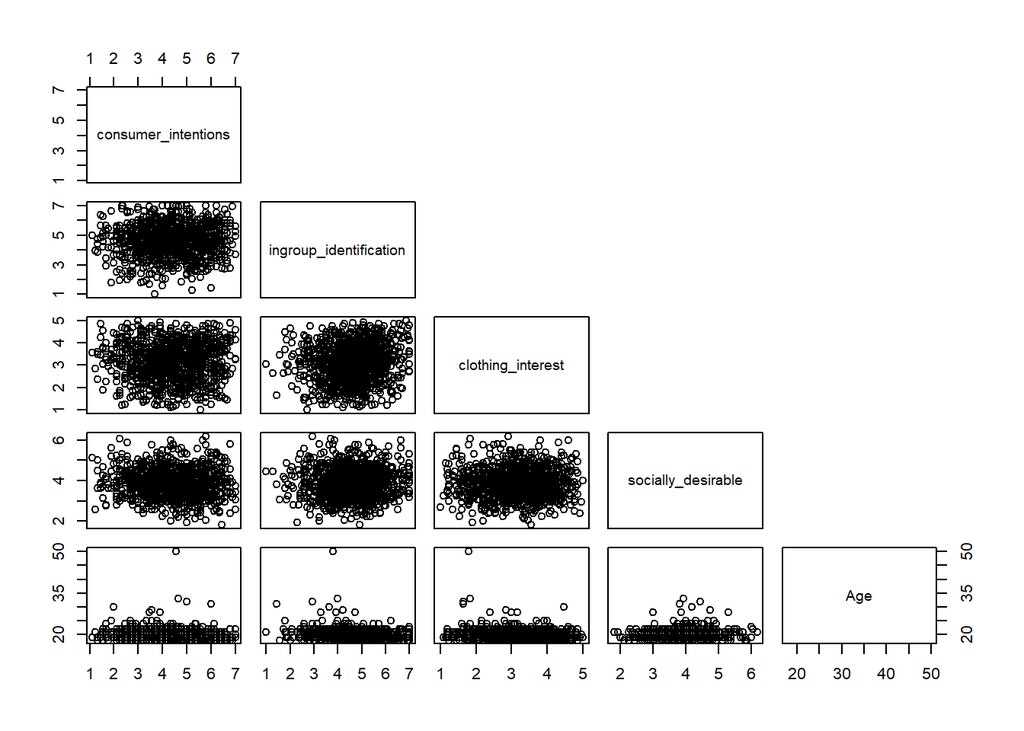

```r
# Consumer intentions with ingroup identification, clothing interest, socially desirable, age
data_R %>%
  select(consumer_intentions, ingroup_identification, clothing_interest, socially_desirable, Age) %>%
  pairs(upper.panel = NULL)
```

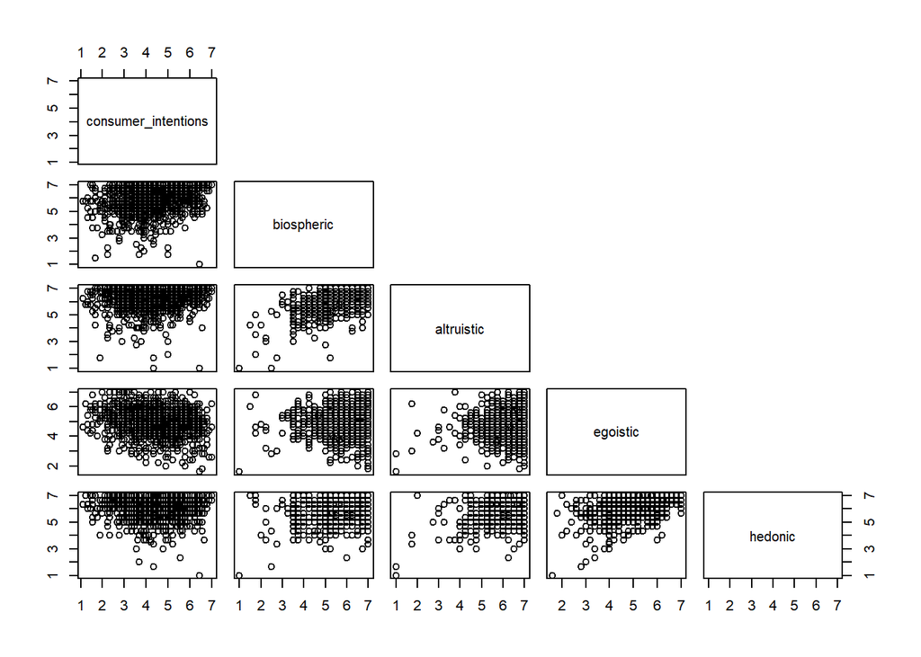

```r
# Consumer intentions with values
data_R %>%
  select(consumer_intentions, biospheric, altruistic, egoistic, hedonic) %>%
  pairs(upper.panel = NULL)
```

# Regression Analysis (DV = Consumer Intentions)

## Center Covariates

- Socially desirable responding
- Clothing interest
- Values
- Ingroup identification
- Age
- Gender
- Income (not sure how to handle inconsistencies in this variable was responded to)

## Contrast Coding

```r
# Gender
contrasts(data_R$Gender) <- c(-1/2, 1/2)
contrasts(data_R$Gender)
```

```
##       [,1]
## Woman -0.5
## Man    0.5
```

```r
# Framing
FrameCode1 <- c(-1/2, 0, 1/2) # control vs self-enhancing
FrameCode2 <- c(-1/3, 2/3, -1/3) # arbitrary code

contrasts(data_R$framing_condition) <- cbind(FrameCode1, FrameCode2)
contrasts(data_R$framing_condition)
```

```
##                  FrameCode1 FrameCode2
## control_framing        -0.5 -0.3333333
## pro_env_framing         0.0  0.6666667
## self_enh_framing        0.5 -0.3333333
```

```r
# Norm
contrasts(data_R$norm_condition) <- contr.helmert(5)
contrasts(data_R$norm_condition) # control vs DN
```

```
##                  [,1] [,2] [,3] [,4]
## control_norm       -1   -1   -1   -1
## descriptive_norm    1   -1   -1   -1
## convention_norm     0    2   -1   -1
## social_norm         0    0    3   -1
## moral_norm          0    0    0    4
```

```r
# Skepticism
contrasts(data_R$skepticism) <- c(-1/2, 1/2)
```

## Running Model

```r
full_model_1a <- lm(consumer_intentions ~ framing_condition*norm_condition*biospheric_center + framing_condition*norm_condition*altruistic_center + framing_condition*norm_condition*egoistic_center + framing_condition*norm_condition*hedonic_center + framing_condition*norm_condition*ingroup_identification_center + socially_desirable_center + clothing_interest_center + Gender + Age_center, data = data_R)
```

## Model Output

Full Summary

- 156 observations deleted due to missingness
- n = 977
- number of parameters = 94
- F(93, 883) = 3.541, p < .001, adj_R_sq = .195

### ANOVA Summary

```r
anova(full_model_1a) %>%
  knitr::kable(digits = 3)
```

|  | Df | Sum Sq | Mean Sq | F value | Pr(>F) |
| --- | --- | --- | --- | --- | --- |
| framing_condition | 2 | 3.749 | 1.875 | 1.673 | 0.188 |
| norm_condition | 4 | 7.514 | 1.879 | 1.676 | 0.153 |
| biospheric_center | 1 | 113.442 | 113.442 | 101.228 | 0.000 |
| altruistic_center | 1 | 0.036 | 0.036 | 0.032 | 0.858 |
| egoistic_center | 1 | 112.083 | 112.083 | 100.016 | 0.000 |
| hedonic_center | 1 | 2.088 | 2.088 | 1.863 | 0.173 |
| ingroup_identification_center | 1 | 5.886 | 5.886 | 5.252 | 0.022 |
| socially_desirable_center | 1 | 9.626 | 9.626 | 8.589 | 0.003 |
| clothing_interest_center | 1 | 0.314 | 0.314 | 0.280 | 0.597 |
| Gender | 1 | 4.003 | 4.003 | 3.572 | 0.059 |
| Age_center | 1 | 6.563 | 6.563 | 5.857 | 0.016 |
| framing_condition:norm_condition | 8 | 4.893 | 0.612 | 0.546 | 0.822 |
| framing_condition:biospheric_center | 2 | 1.009 | 0.504 | 0.450 | 0.638 |
| norm_condition:biospheric_center | 4 | 8.357 | 2.089 | 1.864 | 0.115 |
| framing_condition:altruistic_center | 2 | 0.239 | 0.120 | 0.107 | 0.899 |
| norm_condition:altruistic_center | 4 | 3.455 | 0.864 | 0.771 | 0.544 |
| framing_condition:egoistic_center | 2 | 1.974 | 0.987 | 0.881 | 0.415 |
| norm_condition:egoistic_center | 4 | 0.901 | 0.225 | 0.201 | 0.938 |
| framing_condition:hedonic_center | 2 | 1.410 | 0.705 | 0.629 | 0.533 |
| norm_condition:hedonic_center | 4 | 11.622 | 2.905 | 2.593 | 0.035 |
| framing_condition:ingroup_identification_center | 2 | 0.844 | 0.422 | 0.377 | 0.686 |
| norm_condition:ingroup_identification_center | 4 | 0.632 | 0.158 | 0.141 | 0.967 |
| framing_condition:norm_condition:biospheric_center | 8 | 12.157 | 1.520 | 1.356 | 0.212 |
| framing_condition:norm_condition:altruistic_center | 8 | 16.882 | 2.110 | 1.883 | 0.059 |
| framing_condition:norm_condition:egoistic_center | 8 | 19.008 | 2.376 | 2.120 | 0.032 |
| framing_condition:norm_condition:hedonic_center | 8 | 7.245 | 0.906 | 0.808 | 0.595 |
| framing_condition:norm_condition:ingroup_identification_center | 8 | 13.073 | 1.634 | 1.458 | 0.169 |
| Residuals | 883 | 989.536 | 1.121 | NA | NA |

### Effect Sizes

#### Eta-Squared

```r
eta_squared(full_model_1a, ci = 0.95, alternative = "two.sided", partial = FALSE)
```

```
## # Effect Size for ANOVA (Type I)
##
## Parameter                                                      |     Eta2 |       95% CI
## ----------------------------------------------------------------------------------------
## framing_condition                                              | 2.76e-03 | [0.00, 0.01]
## norm_condition                                                 | 5.53e-03 | [0.00, 0.01]
## biospheric_center                                              |     0.08 | [0.05, 0.12]
## altruistic_center                                              | 2.64e-05 | [0.00, 0.00]
## egoistic_center                                                |     0.08 | [0.05, 0.12]
## hedonic_center                                                 | 1.54e-03 | [0.00, 0.01]
## ingroup_identification_center                                  | 4.33e-03 | [0.00, 0.02]
## socially_desirable_center                                      | 7.09e-03 | [0.00, 0.02]
## clothing_interest_center                                       | 2.31e-04 | [0.00, 0.01]
## Gender                                                         | 2.95e-03 | [0.00, 0.01]
## Age_center                                                     | 4.83e-03 | [0.00, 0.02]
## framing_condition:norm_condition                               | 3.60e-03 | [0.00, 0.00]
## framing_condition:biospheric_center                            | 7.42e-04 | [0.00, 0.01]
## norm_condition:biospheric_center                               | 6.15e-03 | [0.00, 0.02]
## framing_condition:altruistic_center                            | 1.76e-04 | [0.00, 0.00]
## norm_condition:altruistic_center                               | 2.54e-03 | [0.00, 0.01]
## framing_condition:egoistic_center                              | 1.45e-03 | [0.00, 0.01]
## norm_condition:egoistic_center                                 | 6.63e-04 | [0.00, 0.00]
## framing_condition:hedonic_center                               | 1.04e-03 | [0.00, 0.01]
## norm_condition:hedonic_center                                  | 8.55e-03 | [0.00, 0.02]
## framing_condition:ingroup_identification_center                | 6.21e-04 | [0.00, 0.01]
## norm_condition:ingroup_identification_center                   | 4.65e-04 | [0.00, 0.00]
## framing_condition:norm_condition:biospheric_center             | 8.95e-03 | [0.00, 0.02]
## framing_condition:norm_condition:altruistic_center             |     0.01 | [0.00, 0.02]
## framing_condition:norm_condition:egoistic_center               |     0.01 | [0.00, 0.02]
## framing_condition:norm_condition:hedonic_center                | 5.33e-03 | [0.00, 0.01]
## framing_condition:norm_condition:ingroup_identification_center | 9.62e-03 | [0.00, 0.02]
```

#### Partial Eta-Squared

```r
eta_squared(full_model_1a, ci = 0.95, alternative = "two.sided")
```

```
## # Effect Size for ANOVA (Type I)
##
## Parameter                                                      | Eta2 (partial) |       95% CI
## ----------------------------------------------------------------------------------------------
## framing_condition                                              |       3.77e-03 | [0.00, 0.01]
## norm_condition                                                 |       7.54e-03 | [0.00, 0.02]
## biospheric_center                                              |           0.10 | [0.07, 0.14]
## altruistic_center                                              |       3.62e-05 | [0.00, 0.00]
## egoistic_center                                                |           0.10 | [0.07, 0.14]
## hedonic_center                                                 |       2.11e-03 | [0.00, 0.01]
## ingroup_identification_center                                  |       5.91e-03 | [0.00, 0.02]
## socially_desirable_center                                      |       9.63e-03 | [0.00, 0.03]
## clothing_interest_center                                       |       3.17e-04 | [0.00, 0.01]
## Gender                                                         |       4.03e-03 | [0.00, 0.02]
## Age_center                                                     |       6.59e-03 | [0.00, 0.02]
## framing_condition:norm_condition                               |       4.92e-03 | [0.00, 0.01]
## framing_condition:biospheric_center                            |       1.02e-03 | [0.00, 0.01]
## norm_condition:biospheric_center                               |       8.38e-03 | [0.00, 0.02]
## framing_condition:altruistic_center                            |       2.42e-04 | [0.00, 0.00]
## norm_condition:altruistic_center                               |       3.48e-03 | [0.00, 0.01]
## framing_condition:egoistic_center                              |       1.99e-03 | [0.00, 0.01]
## norm_condition:egoistic_center                                 |       9.10e-04 | [0.00, 0.00]
## framing_condition:hedonic_center                               |       1.42e-03 | [0.00, 0.01]
## norm_condition:hedonic_center                                  |           0.01 | [0.00, 0.03]
## framing_condition:ingroup_identification_center                |       8.52e-04 | [0.00, 0.01]
## norm_condition:ingroup_identification_center                   |       6.39e-04 | [0.00, 0.00]
## framing_condition:norm_condition:biospheric_center             |           0.01 | [0.00, 0.02]
## framing_condition:norm_condition:altruistic_center             |           0.02 | [0.00, 0.03]
## framing_condition:norm_condition:egoistic_center               |           0.02 | [0.00, 0.03]
## framing_condition:norm_condition:hedonic_center                |       7.27e-03 | [0.00, 0.01]
## framing_condition:norm_condition:ingroup_identification_center |           0.01 | [0.00, 0.03]
```

### Regression Summary

```r
regr_summary$coefficients %>%
  knitr::kable(digits = 3)
```

|  | Estimate | Std. Error | t value | Pr(>\|t\|) |
| --- | --- | --- | --- | --- |
| (Intercept) | 4.378 | 0.037 | 119.845 | 0.000 |
| framing_conditionFrameCode1 | 0.039 | 0.088 | 0.446 | 0.656 |
| framing_conditionFrameCode2 | 0.119 | 0.075 | 1.589 | 0.112 |
| norm_condition1 | 0.017 | 0.055 | 0.301 | 0.763 |
| norm_condition2 | 0.024 | 0.032 | 0.743 | 0.458 |
| norm_condition3 | -0.046 | 0.023 | -1.982 | 0.048 |
| norm_condition4 | -0.017 | 0.018 | -0.967 | 0.334 |
| biospheric_center | 0.353 | 0.050 | 7.091 | 0.000 |
| altruistic_center | 0.129 | 0.067 | 1.924 | 0.055 |
| egoistic_center | -0.353 | 0.047 | -7.488 | 0.000 |
| hedonic_center | -0.099 | 0.058 | -1.721 | 0.086 |
| ingroup_identification_center | 0.032 | 0.037 | 0.880 | 0.379 |
| socially_desirable_center | -0.145 | 0.054 | -2.689 | 0.007 |
| clothing_interest_center | 0.005 | 0.049 | 0.113 | 0.910 |
| Gender1 | -0.090 | 0.081 | -1.107 | 0.269 |
| Age_center | -0.054 | 0.022 | -2.432 | 0.015 |
| framing_conditionFrameCode1:norm_condition1 | 0.163 | 0.135 | 1.209 | 0.227 |
| framing_conditionFrameCode2:norm_condition1 | -0.123 | 0.117 | -1.048 | 0.295 |
| framing_conditionFrameCode1:norm_condition2 | 0.002 | 0.081 | 0.030 | 0.976 |
| framing_conditionFrameCode2:norm_condition2 | -0.059 | 0.067 | -0.877 | 0.381 |
| framing_conditionFrameCode1:norm_condition3 | 0.026 | 0.056 | 0.462 | 0.644 |
| framing_conditionFrameCode2:norm_condition3 | 0.038 | 0.049 | 0.762 | 0.446 |
| framing_conditionFrameCode1:norm_condition4 | 0.028 | 0.045 | 0.629 | 0.529 |
| framing_conditionFrameCode2:norm_condition4 | -0.003 | 0.037 | -0.072 | 0.943 |
| framing_conditionFrameCode1:biospheric_center | -0.031 | 0.128 | -0.240 | 0.811 |
| framing_conditionFrameCode2:biospheric_center | 0.075 | 0.099 | 0.760 | 0.448 |
| norm_condition1:biospheric_center | -0.069 | 0.074 | -0.938 | 0.348 |
| norm_condition2:biospheric_center | 0.059 | 0.045 | 1.305 | 0.192 |
| norm_condition3:biospheric_center | -0.038 | 0.032 | -1.188 | 0.235 |
| norm_condition4:biospheric_center | -0.050 | 0.027 | -1.875 | 0.061 |

[output cut: 64 more lines]

## Regression Diagnostics

### Checking non-linearity

First, assess non-linearity using a residuals plots:

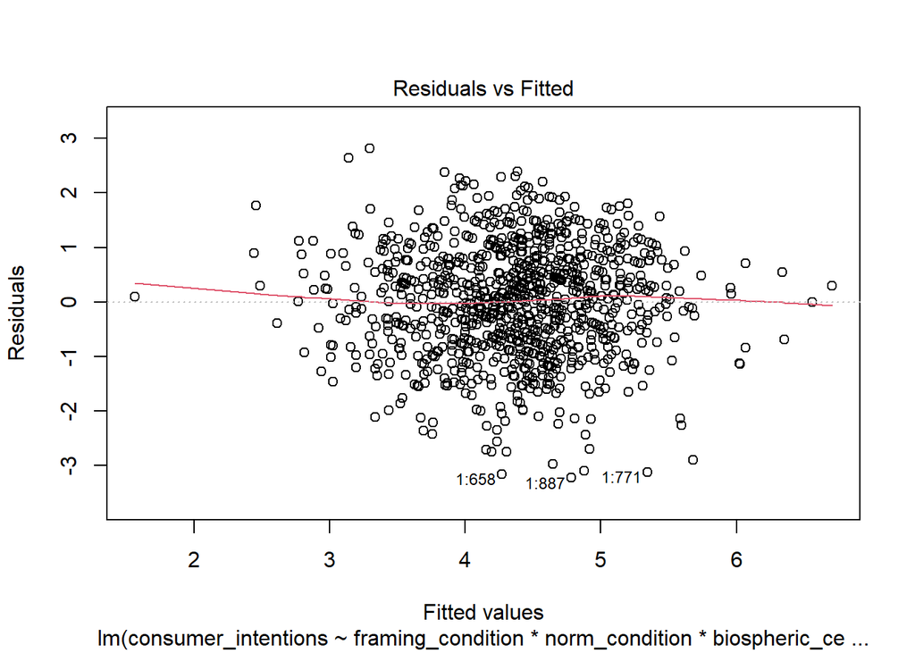

```r
plot(full_model_1a, 1)
```

There does not appear to be a systematic pattern suggesting an uncaptured, non-linear trend.

### Checking non-normally distributed errors

Second, assess non-normally distributed errors by plotting the residuals & using a QQ-plot:

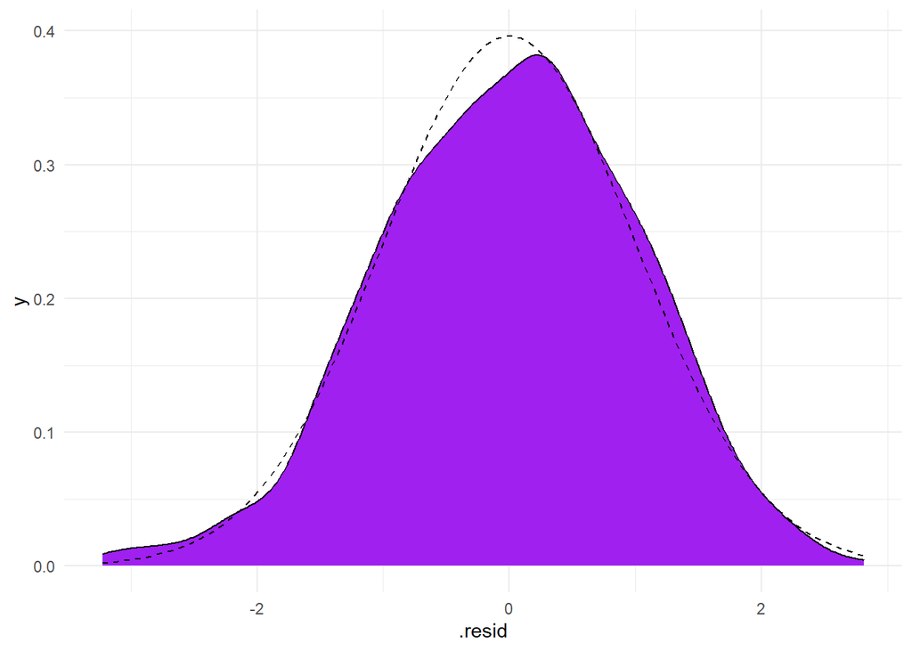

```r
# storing residuals
full_model_1a_aug <- augment(full_model_1a)

# plotting histogram of residuals
ggplot(data = full_model_1a_aug, aes(x = .resid)) +
  geom_density(fill = "purple") +
  stat_function(linetype = 2,
                fun      = dnorm,
                args     = list(mean = mean(full_model_1a_aug$.resid),
                                sd   =   sd(full_model_1a_aug$.resid))) +
  theme_minimal()
```

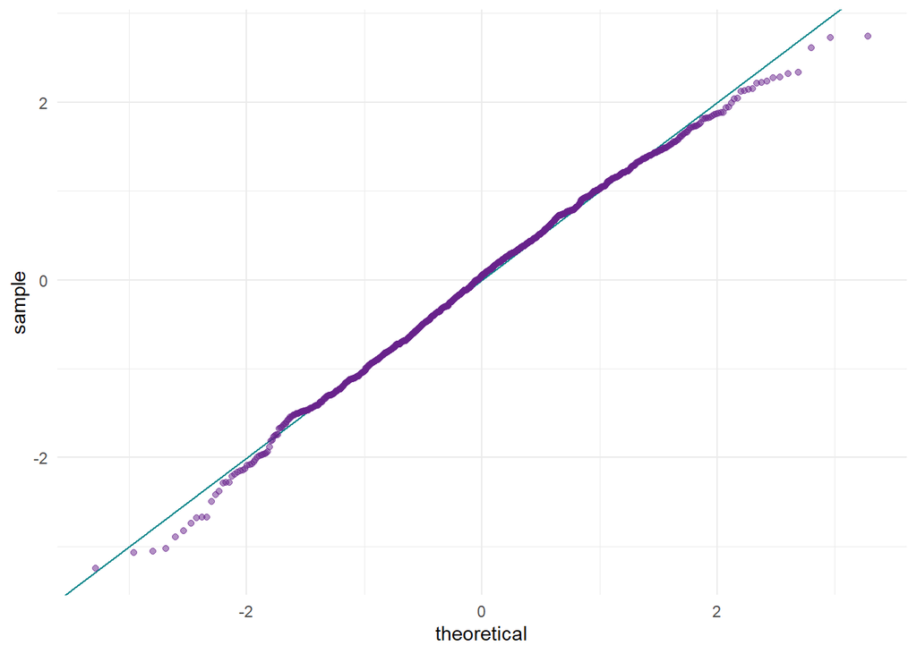

```r
# QQ-plot
ggplot(full_model_1a) +
  geom_abline(color = "turquoise4") +
  stat_qq(aes(sample = .stdresid), color = "darkorchid4", alpha = .50) +
  theme_minimal()
```

The distribution of residuals & QQ-plot suggest approximately normally distributed residuals.

### Checking heteroscedasticity

Third, check for heteroscedasticity by looking at spread of residuals on residuals plot:

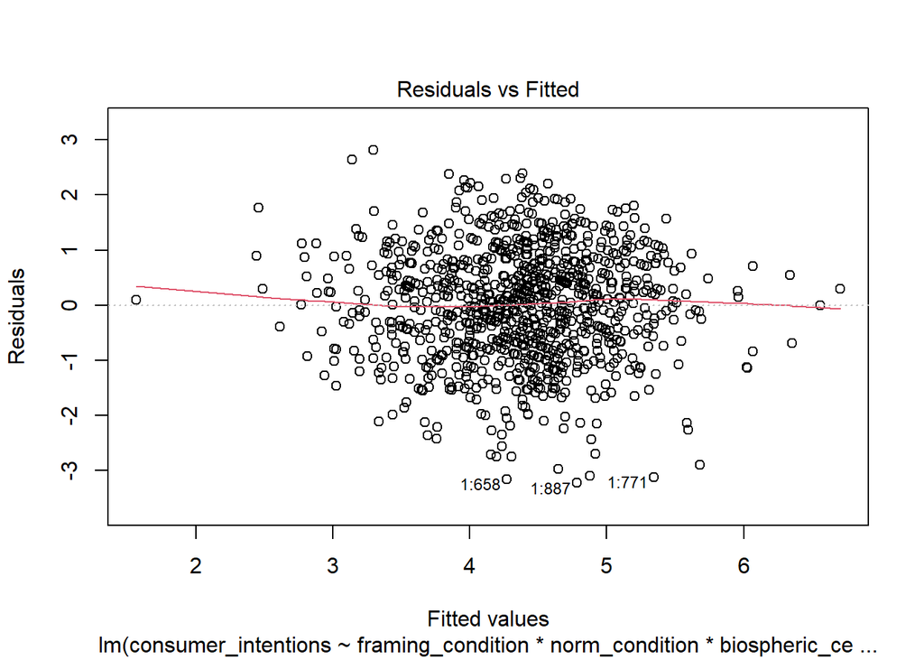

```r
plot(full_model_1a, 1)
```

There does not appear to be an issue with heteroscedasticity.

### Checking multivariate outliers

Outliers based on distance from model using standardized residuals:

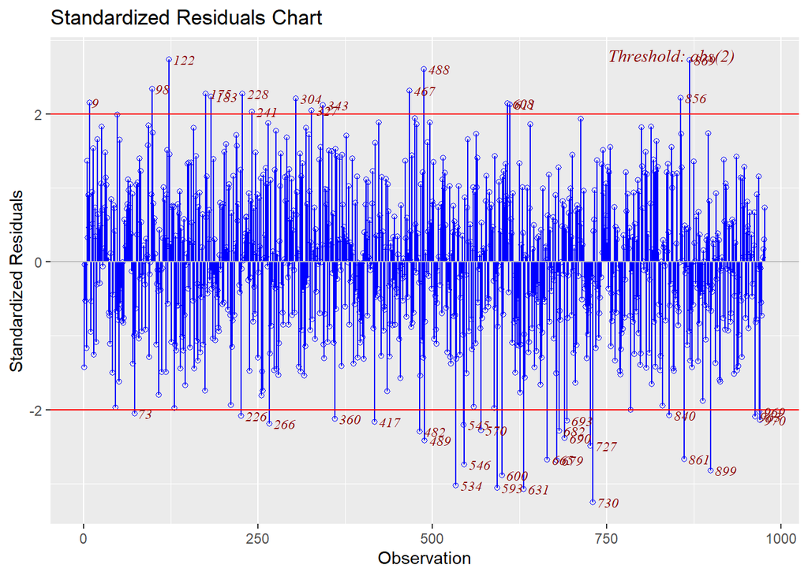

```r
# using olsrr function
ols_plot_resid_stand(full_model_1a)
```

```r
# or grabbing from model augment output
full_model_1a_aug <- augment(full_model_1a)

full_model_1a_aug$id <- full_model_1a_aug$.rownames

std_resids <- full_model_1a_aug %>%
  select(.rownames, .std.resid) %>%
  arrange(desc(abs(.std.resid)))

print(std_resids, n = 15)
```

```
## # A tibble: 977 × 2
##    .rownames .std.resid
##    <chr>          <dbl>
##  1 1:887          -3.25
##  2 1:771          -3.07
##  3 1:727          -3.05
##  4 1:658          -3.03
##  5 1:734          -2.89
##  6 1:1064         -2.82
##  7 1:140           2.74
##  8 1:671          -2.74
##  9 1:1034          2.73
## 10 1:828          -2.68
## 11 1:813          -2.67
## 12 1:1026         -2.67
## 13 1:605           2.61
## 14 1:884          -2.49
## 15 1:606          -2.42
## # ℹ 962 more rows
```

Examine outliers with standardized residuals greater than +/-2 or +/-3.

Outliers based on influence on model using Cook’s Distance:

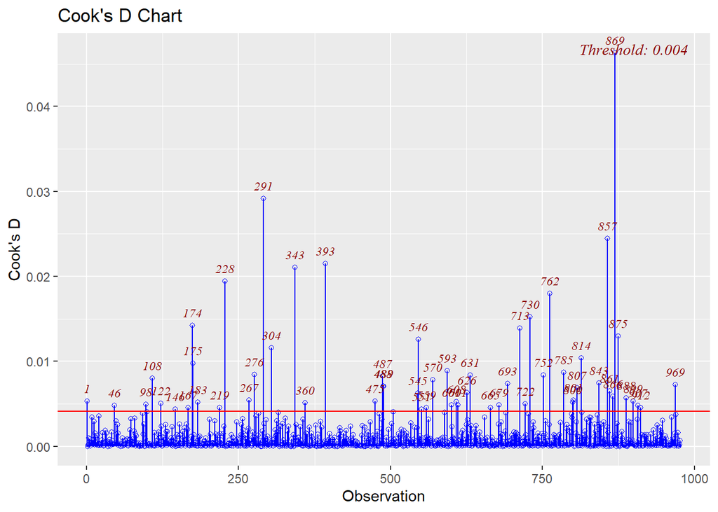

```r
# using olsrr function
ols_plot_cooksd_chart(full_model_1a)
```

```r
# or grabbing from model augment output
cooks_d <- full_model_1a_aug %>%
  select(.rownames, .cooksd) %>%
  arrange(desc(abs(.cooksd)))

print(cooks_d, n = 15)
```

```
## # A tibble: 977 × 2
##    .rownames .cooksd
##    <chr>       <dbl>
##  1 1:1034    0.0463
##  2 1:351     0.0291
##  3 1:1022    0.0245
##  4 1:487     0.0215
##  5 1:422     0.0210
##  6 1:278     0.0194
##  7 1:921     0.0180
##  8 1:887     0.0152
##  9 1:211     0.0142
## 10 1:870     0.0139
## 11 1:1040    0.0130
## 12 1:671     0.0126
## 13 1:369     0.0116
## 14 1:977     0.0104
## 15 1:213     0.00976
## # ℹ 962 more rows
```

One standard is that Cook’s D values greater than 3 times the average Cook’s D values are worth investigating.

### Checking multicollinearity

Using VIFs & tolerance:

```r
ols_vif_tol(full_model_1a) %>%
  arrange(desc(abs(VIF)))
```

```
##                                                                    Variables
## 1              framing_conditionFrameCode1:norm_condition4:altruistic_center
## 2                                          norm_condition4:altruistic_center
## 3              framing_conditionFrameCode1:norm_condition4:biospheric_center
## 4                              framing_conditionFrameCode1:altruistic_center
## 5              framing_conditionFrameCode1:norm_condition2:altruistic_center
## 6                                                          altruistic_center
## 7                                          norm_condition4:biospheric_center
## 8              framing_conditionFrameCode1:norm_condition3:altruistic_center
## 9              framing_conditionFrameCode2:norm_condition4:altruistic_center
## 10             framing_conditionFrameCode1:norm_condition2:biospheric_center
## 11             framing_conditionFrameCode1:norm_condition1:altruistic_center
## 12                             framing_conditionFrameCode1:biospheric_center
## 13                                         norm_condition2:altruistic_center
## 14             framing_conditionFrameCode1:norm_condition3:biospheric_center
```

[output cut: 173 more lines]

Either a *low* tolerance (below 0.20 is one rule of thumb) or a *high* VIF (above 5 or 10) is an indication of a problem with multicollinearity.

## Simple Effects

### Framing Condition

> > H1: Consumer intentions/behaviors will be lower in the self-enhancing framing than in the pro-environmental or control framing conditions.

Comparing each level of framing condition:

```r
frame_means <- emmeans(full_model_1a, pairwise ~ framing_condition, adjust = "none")
frame_means
```

```
## $emmeans
##  framing_condition emmean     SE  df lower.CL upper.CL
##  control_framing     4.30 0.0621 883     4.18     4.42
##  pro_env_framing     4.44 0.0611 883     4.32     4.56
##  self_enh_framing    4.34 0.0627 883     4.22     4.46
##
## Results are averaged over the levels of: norm_condition, Gender
## Confidence level used: 0.95
##
## $contrasts
##  contrast                           estimate     SE  df t.ratio p.value
##  control_framing - pro_env_framing   -0.1436 0.0863 883  -1.663  0.0967
##  control_framing - self_enh_framing  -0.0396 0.0875 883  -0.453  0.6507
##  pro_env_framing - self_enh_framing   0.1039 0.0867 883   1.199  0.2309
##
## Results are averaged over the levels of: norm_condition, Gender
```

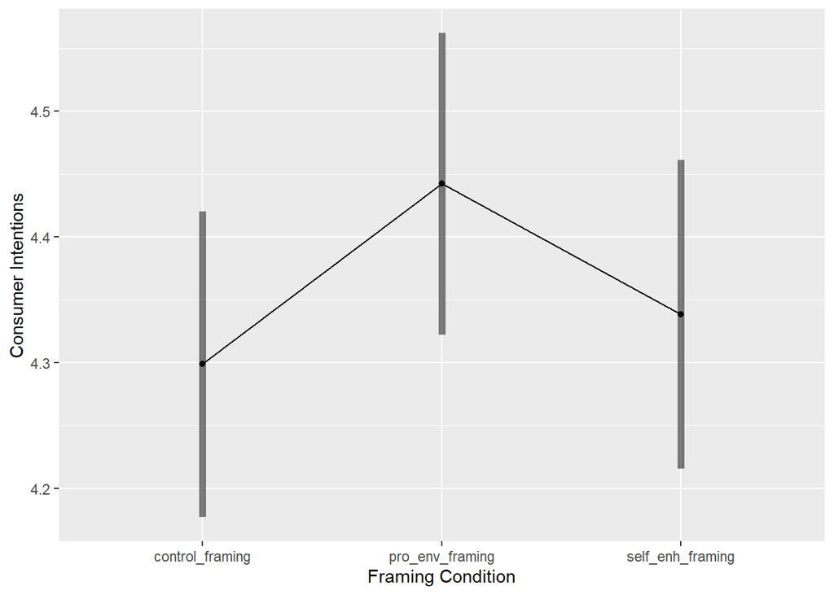

```r
emmip(full_model_1a, ~ framing_condition, CIs = TRUE, xlab = "Framing Condition", ylab = "Consumer Intentions")
```

- Intentions are highest in the pro-environmental condition, but the difference between the pro-environmental and self-enhancing framings (t(883) = 1.20, p = .231) and the pro-environmental and control framing (t(883) = -1.66, p = .097) is not significant.
- The difference between self-enhancing and control framing is also not significant, t(883) = -0.45, p = .651.

Effect Sizes (Cohen’s D):

```r
eff_size(frame_means, sigma = sigma(full_model_1a), edf = df.residual(full_model_1a))
```

```
##  contrast                             effect.size     SE  df lower.CL upper.CL
##  (control_framing - pro_env_framing)      -0.1356 0.0816 883  -0.2958   0.0246
##  (control_framing - self_enh_framing)     -0.0374 0.0827 883  -0.1996   0.1248
##  (pro_env_framing - self_enh_framing)      0.0982 0.0819 883  -0.0626   0.2590
##
## Results are averaged over the levels of: norm_condition, Gender
## sigma used for effect sizes: 1.059
## Confidence level used: 0.95
```

### Norm Condition

> > H2: Consumer intentions/behaviors will be lower in each norm condition compared to the control norm condition.

Comparing each level of norm condition:

```r
norm_means <- emmeans(full_model_1a, pairwise ~ norm_condition, adjust = "none")
norm_means
```

```
## $emmeans
##  norm_condition   emmean     SE  df lower.CL upper.CL
##  control_norm       4.38 0.0773 883     4.23     4.53
##  descriptive_norm   4.42 0.0793 883     4.26     4.57
##  convention_norm    4.47 0.0803 883     4.31     4.63
##  social_norm        4.24 0.0804 883     4.08     4.40
##  moral_norm         4.29 0.0808 883     4.13     4.45
##
## Results are averaged over the levels of: framing_condition, Gender
## Confidence level used: 0.95
##
## $contrasts
##  contrast                           estimate    SE  df t.ratio p.value
##  control_norm - descriptive_norm     -0.0391 0.110 883  -0.355  0.7225
##  control_norm - convention_norm      -0.0929 0.111 883  -0.837  0.4030
##  control_norm - social_norm           0.1369 0.111 883   1.237  0.2163
##  control_norm - moral_norm            0.0893 0.111 883   0.804  0.4218
##  descriptive_norm - convention_norm  -0.0538 0.112 883  -0.479  0.6322
##  descriptive_norm - social_norm       0.1760 0.112 883   1.570  0.1167
##  descriptive_norm - moral_norm        0.1284 0.112 883   1.142  0.2538
##  convention_norm - social_norm        0.2298 0.113 883   2.034  0.0423
##  convention_norm - moral_norm         0.1822 0.114 883   1.604  0.1091
##  social_norm - moral_norm            -0.0476 0.113 883  -0.420  0.6745
##
## Results are averaged over the levels of: framing_condition, Gender
```

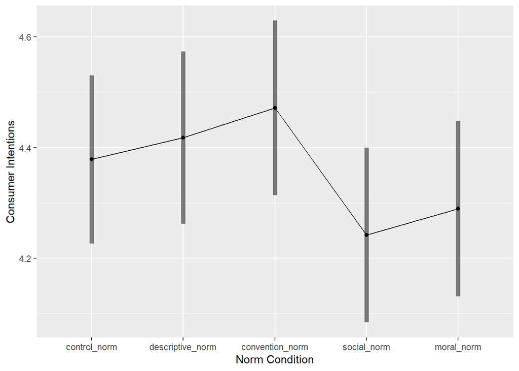

```r
emmip(full_model_1a, ~ norm_condition, CIs = TRUE, xlab = "Norm Condition", ylab = "Consumer Intentions")
```

- There was no significant difference between any norm condition compared to the control condition (all ps > .216)

Effect Sizes (Cohen’s D):

```r
eff_size(norm_means, sigma = sigma(full_model_1a), edf = df.residual(full_model_1a))
```

```
##  contrast                             effect.size    SE  df lower.CL upper.CL
##  (control_norm - descriptive_norm)        -0.0369 0.104 883 -0.24095    0.167
##  (control_norm - convention_norm)         -0.0877 0.105 883 -0.29360    0.118
##  (control_norm - social_norm)              0.1293 0.105 883 -0.07592    0.335
##  (control_norm - moral_norm)               0.0844 0.105 883 -0.12173    0.291
##  (descriptive_norm - convention_norm)     -0.0508 0.106 883 -0.25908    0.157
##  (descriptive_norm - social_norm)          0.1663 0.106 883 -0.04169    0.374
##  (descriptive_norm - moral_norm)           0.1213 0.106 883 -0.08726    0.330
##  (convention_norm - social_norm)           0.2171 0.107 883  0.00733    0.427
##  (convention_norm - moral_norm)            0.1721 0.107 883 -0.03868    0.383
##  (social_norm - moral_norm)               -0.0450 0.107 883 -0.25500    0.165
##
## Results are averaged over the levels of: framing_condition, Gender
## sigma used for effect sizes: 1.059
## Confidence level used: 0.95
```

### Framing X Norm

> > H3: There will be a two-way interaction between framing & norm condition such that the effect of each norm will be stronger in the self-enhancing framing than in the pro-environmental or control framing conditions.

Effect of norm condition at each level of framing condition:

```r
cell_means <- emmeans(full_model_1a, pairwise ~ norm_condition | framing_condition, adjust = "none")
cell_means
```

```
## $emmeans
## framing_condition = control_framing:
##  norm_condition   emmean    SE  df lower.CL upper.CL
##  control_norm       4.39 0.131 883     4.13     4.64
##  descriptive_norm   4.32 0.145 883     4.04     4.61
##  convention_norm    4.48 0.145 883     4.20     4.77
##  social_norm        4.11 0.120 883     3.87     4.35
##  moral_norm         4.19 0.146 883     3.90     4.48
##
## framing_condition = pro_env_framing:
##  norm_condition   emmean    SE  df lower.CL upper.CL
##  control_norm       4.55 0.136 883     4.28     4.82
##  descriptive_norm   4.43 0.135 883     4.17     4.70
##  convention_norm    4.46 0.129 883     4.21     4.71
##  social_norm        4.40 0.143 883     4.12     4.68
##  moral_norm         4.37 0.132 883     4.11     4.63
##
## framing_condition = self_enh_framing:
##  norm_condition   emmean    SE  df lower.CL upper.CL
##  control_norm       4.20 0.133 883     3.94     4.46
##  descriptive_norm   4.50 0.131 883     4.24     4.76
##  convention_norm    4.47 0.142 883     4.19     4.75
##  social_norm        4.22 0.151 883     3.92     4.51
##  moral_norm         4.31 0.140 883     4.04     4.58
##
## Results are averaged over the levels of: Gender
## Confidence level used: 0.95
##
## $contrasts
## framing_condition = control_framing:
##  contrast                           estimate    SE  df t.ratio p.value
##  control_norm - descriptive_norm      0.0648 0.195 883   0.332  0.7400
##  control_norm - convention_norm      -0.0968 0.196 883  -0.495  0.6210
##  control_norm - social_norm           0.2784 0.178 883   1.566  0.1177
##  control_norm - moral_norm            0.1956 0.197 883   0.995  0.3198
##  descriptive_norm - convention_norm  -0.1616 0.205 883  -0.789  0.4305
##  descriptive_norm - social_norm       0.2136 0.188 883   1.139  0.2550
##  descriptive_norm - moral_norm        0.1309 0.205 883   0.637  0.5243
##  convention_norm - social_norm        0.3752 0.189 883   1.989  0.0470
##  convention_norm - moral_norm         0.2925 0.206 883   1.418  0.1564
```

[output cut: 14 more lines]

```
##
## framing_condition = self_enh_framing:
##  contrast                           estimate    SE  df t.ratio p.value
##  control_norm - descriptive_norm     -0.3011 0.186 883  -1.621  0.1055
##  control_norm - convention_norm      -0.2740 0.194 883  -1.413  0.1579
##  control_norm - social_norm          -0.0183 0.201 883  -0.091  0.9274
##  control_norm - moral_norm           -0.1126 0.193 883  -0.584  0.5591
##  descriptive_norm - convention_norm   0.0271 0.192 883   0.141  0.8879
##  descriptive_norm - social_norm       0.2828 0.200 883   1.417  0.1568
##  descriptive_norm - moral_norm        0.1884 0.192 883   0.982  0.3264
##  convention_norm - social_norm        0.2557 0.206 883   1.239  0.2155
##  convention_norm - moral_norm         0.1614 0.200 883   0.809  0.4188
##  social_norm - moral_norm            -0.0943 0.206 883  -0.458  0.6467
##
## Results are averaged over the levels of: Gender
```

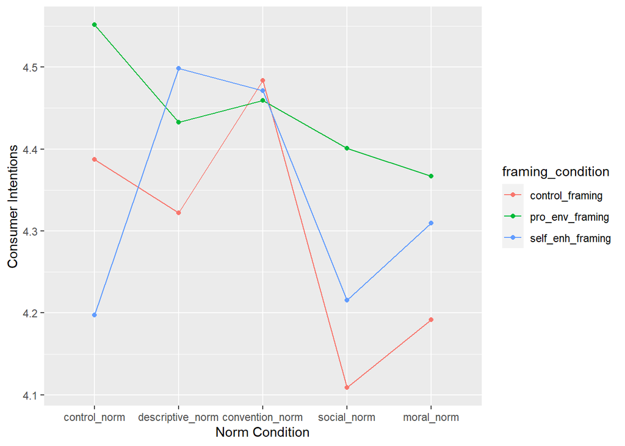

```r
emmip(full_model_1a, framing_condition ~ norm_condition, CIs = FALSE, xlab = "Norm Condition", ylab = "Consumer Intentions")
```

- Differences between the control norm condition & other norm conditions were not significant within any of the framing conditions.

Effect Sizes (Cohen’s D):

```r
eff_size(cell_means, sigma = sigma(full_model_1a), edf = df.residual(full_model_1a))
```

```
## framing_condition = control_framing:
##  contrast                             effect.size    SE  df lower.CL upper.CL
##  (control_norm - descriptive_norm)         0.0612 0.184 883 -0.30053   0.4229
##  (control_norm - convention_norm)         -0.0915 0.185 883 -0.45454   0.2716
##  (control_norm - social_norm)              0.2630 0.168 883 -0.06685   0.5928
##  (control_norm - moral_norm)               0.1848 0.186 883 -0.17964   0.5492
##  (descriptive_norm - convention_norm)     -0.1527 0.194 883 -0.53261   0.2273
##  (descriptive_norm - social_norm)          0.2018 0.177 883 -0.14605   0.5496
##  (descriptive_norm - moral_norm)           0.1236 0.194 883 -0.25732   0.5046
##  (convention_norm - social_norm)           0.3544 0.178 883  0.00439   0.7045
##  (convention_norm - moral_norm)            0.2763 0.195 883 -0.10624   0.6588
##  (social_norm - moral_norm)               -0.0782 0.179 883 -0.42924   0.2729
##
## framing_condition = pro_env_framing:
##  contrast                             effect.size    SE  df lower.CL upper.CL
##  (control_norm - descriptive_norm)         0.1124 0.181 883 -0.24238   0.4672
##  (control_norm - convention_norm)          0.0871 0.177 883 -0.26001   0.4341
##  (control_norm - social_norm)              0.1424 0.186 883 -0.22301   0.5077
##  (control_norm - moral_norm)               0.1748 0.179 883 -0.17574   0.5252
##  (descriptive_norm - convention_norm)     -0.0254 0.176 883 -0.37108   0.3204
##  (descriptive_norm - social_norm)          0.0299 0.186 883 -0.33425   0.3941
##  (descriptive_norm - moral_norm)           0.0623 0.178 883 -0.28763   0.4123
##  (convention_norm - social_norm)           0.0553 0.181 883 -0.30076   0.4114
##  (convention_norm - moral_norm)            0.0877 0.174 883 -0.25307   0.4285
##  (social_norm - moral_norm)                0.0324 0.183 883 -0.32650   0.3913
##
## framing_condition = self_enh_framing:
##  contrast                             effect.size    SE  df lower.CL upper.CL
##  (control_norm - descriptive_norm)        -0.2844 0.176 883 -0.62906   0.0603
##  (control_norm - convention_norm)         -0.2588 0.183 883 -0.61835   0.1008
##  (control_norm - social_norm)             -0.0173 0.190 883 -0.38923   0.3547
##  (control_norm - moral_norm)              -0.1064 0.182 883 -0.46360   0.2509
##  (descriptive_norm - convention_norm)      0.0256 0.181 883 -0.33058   0.3818
##  (descriptive_norm - social_norm)          0.2671 0.189 883 -0.10306   0.6373
##  (descriptive_norm - moral_norm)           0.1780 0.181 883 -0.17787   0.5339
##  (convention_norm - social_norm)           0.2415 0.195 883 -0.14110   0.6241
##  (convention_norm - moral_norm)            0.1524 0.188 883 -0.21752   0.5224
##  (social_norm - moral_norm)               -0.0891 0.194 883 -0.47047   0.2923
##
## Results are averaged over the levels of: Gender
## sigma used for effect sizes: 1.059
## Confidence level used: 0.95
```

- The effect sizes are larger comparing the control norm condition to the other norm conditions within the self-enhancing framing condition compared to within the control framing or pro-environmental framing conditions
  - But, inspection of the cell means demonstrates that this is being driven by the fact that consumer intentions in the self-enhancing framing/control norm condition started out lower than the control norm condition in the other two framing conditions.

Comparing consumer intentions for each norm condition between each framing condition:

```r
# Control norm
chosen_values <- list(norm_condition = c("control_norm"), framing_condition = c("control_framing", "pro_env_framing", "self_enh_framing"))

control_norm_means <- emmeans(full_model_1a, pairwise ~ norm_condition*framing_condition, at = chosen_values, adjust = "none")

control_norm_means
```

```
## $emmeans
##  norm_condition framing_condition emmean    SE  df lower.CL upper.CL
##  control_norm   control_framing     4.39 0.131 883     4.13     4.64
##  control_norm   pro_env_framing     4.55 0.136 883     4.28     4.82
##  control_norm   self_enh_framing    4.20 0.133 883     3.94     4.46
##
## Results are averaged over the levels of: Gender
## Confidence level used: 0.95
##
## $contrasts
##  contrast                                                     estimate    SE
##  control_norm control_framing - control_norm pro_env_framing    -0.165 0.189
##  control_norm control_framing - control_norm self_enh_framing    0.190 0.186
##  control_norm pro_env_framing - control_norm self_enh_framing    0.354 0.190
##   df t.ratio p.value
##  883  -0.871  0.3840
##  883   1.020  0.3082
##  883   1.870  0.0619
##
## Results are averaged over the levels of: Gender
```

```r
eff_size(control_norm_means, sigma = sigma(full_model_1a), edf = df.residual(full_model_1a)) # cohen's d
```

```
##  contrast                                                       effect.size
##  (control_norm control_framing - control_norm pro_env_framing)       -0.155
##  (control_norm control_framing - control_norm self_enh_framing)       0.179
##  (control_norm pro_env_framing - control_norm self_enh_framing)       0.335
##     SE  df lower.CL upper.CL
##  0.178 883   -0.506    0.195
##  0.176 883   -0.166    0.525
##  0.179 883   -0.017    0.687
##
## Results are averaged over the levels of: Gender
## sigma used for effect sizes: 1.059
## Confidence level used: 0.95
```

```r
# Descriptive norm
chosen_values <- list(norm_condition = c("descriptive_norm"), framing_condition = c("control_framing", "pro_env_framing", "self_enh_framing"))

descr_norm_means <- emmeans(full_model_1a, pairwise ~ norm_condition*framing_condition, at = chosen_values, adjust = "none")
descr_norm_means
```

```
## $emmeans
##  norm_condition   framing_condition emmean    SE  df lower.CL upper.CL
##  descriptive_norm control_framing     4.32 0.145 883     4.04     4.61
##  descriptive_norm pro_env_framing     4.43 0.135 883     4.17     4.70
##  descriptive_norm self_enh_framing    4.50 0.131 883     4.24     4.76
##
## Results are averaged over the levels of: Gender
## Confidence level used: 0.95
##
## $contrasts
##  contrast                                                             estimate
##  descriptive_norm control_framing - descriptive_norm pro_env_framing   -0.1103
##  descriptive_norm control_framing - descriptive_norm self_enh_framing  -0.1759
##  descriptive_norm pro_env_framing - descriptive_norm self_enh_framing  -0.0656
##     SE  df t.ratio p.value
##  0.198 883  -0.557  0.5775
##  0.195 883  -0.903  0.3670
##  0.189 883  -0.348  0.7282
##
## Results are averaged over the levels of: Gender
```

```r
eff_size(descr_norm_means, sigma = sigma(full_model_1a), edf = df.residual(full_model_1a)) # cohen's d
```

```
##  contrast
##  (descriptive_norm control_framing - descriptive_norm pro_env_framing)
##  (descriptive_norm control_framing - descriptive_norm self_enh_framing)
##  (descriptive_norm pro_env_framing - descriptive_norm self_enh_framing)
##  effect.size    SE  df lower.CL upper.CL
##      -0.1042 0.187 883   -0.471    0.263
##      -0.1661 0.184 883   -0.527    0.195
##      -0.0619 0.178 883   -0.412    0.288
##
## Results are averaged over the levels of: Gender
## sigma used for effect sizes: 1.059
## Confidence level used: 0.95
```

```r
# Convention norm
chosen_values <- list(norm_condition = c("convention_norm"), framing_condition = c("control_framing", "pro_env_framing", "self_enh_framing"))

conv_norm_means <- emmeans(full_model_1a, pairwise ~ norm_condition*framing_condition, at = chosen_values, adjust = "none")
conv_norm_means
```

```
## $emmeans
##  norm_condition  framing_condition emmean    SE  df lower.CL upper.CL
##  convention_norm control_framing     4.48 0.145 883     4.20     4.77
##  convention_norm pro_env_framing     4.46 0.129 883     4.21     4.71
##  convention_norm self_enh_framing    4.47 0.142 883     4.19     4.75
##
## Results are averaged over the levels of: Gender
## Confidence level used: 0.95
##
## $contrasts
##  contrast                                                           estimate
##  convention_norm control_framing - convention_norm pro_env_framing    0.0245
##  convention_norm control_framing - convention_norm self_enh_framing   0.0128
##  convention_norm pro_env_framing - convention_norm self_enh_framing  -0.0116
##     SE  df t.ratio p.value
##  0.194 883   0.126  0.8998
##  0.203 883   0.063  0.9496
##  0.191 883  -0.061  0.9515
##
## Results are averaged over the levels of: Gender
```

```r
eff_size(conv_norm_means, sigma = sigma(full_model_1a), edf = df.residual(full_model_1a)) # cohen's d
```

```
##  contrast
##  (convention_norm control_framing - convention_norm pro_env_framing)
##  (convention_norm control_framing - convention_norm self_enh_framing)
##  (convention_norm pro_env_framing - convention_norm self_enh_framing)
##  effect.size    SE  df lower.CL upper.CL
##       0.0231 0.183 883   -0.337    0.383
##       0.0121 0.192 883   -0.364    0.388
##      -0.0110 0.181 883   -0.365    0.343
##
## Results are averaged over the levels of: Gender
## sigma used for effect sizes: 1.059
## Confidence level used: 0.95
```

```r
# Social norm
chosen_values <- list(norm_condition = c("social_norm"), framing_condition = c("control_framing", "pro_env_framing", "self_enh_framing"))

soc_norm_means <- emmeans(full_model_1a, pairwise ~ norm_condition*framing_condition, at = chosen_values, adjust = "none")
soc_norm_means
```

```
## $emmeans
##  norm_condition framing_condition emmean    SE  df lower.CL upper.CL
##  social_norm    control_framing     4.11 0.120 883     3.87     4.35
##  social_norm    pro_env_framing     4.40 0.143 883     4.12     4.68
##  social_norm    self_enh_framing    4.22 0.151 883     3.92     4.51
##
## Results are averaged over the levels of: Gender
## Confidence level used: 0.95
##
## $contrasts
##  contrast                                                   estimate    SE  df
##  social_norm control_framing - social_norm pro_env_framing    -0.292 0.187 883
##  social_norm control_framing - social_norm self_enh_framing   -0.107 0.192 883
##  social_norm pro_env_framing - social_norm self_enh_framing    0.185 0.208 883
##  t.ratio p.value
##   -1.564  0.1181
##   -0.555  0.5794
##    0.893  0.3720
##
## Results are averaged over the levels of: Gender
```

```r
eff_size(soc_norm_means, sigma = sigma(full_model_1a), edf = df.residual(full_model_1a)) # cohen's d
```

```
##  contrast                                                     effect.size    SE
##  (social_norm control_framing - social_norm pro_env_framing)       -0.276 0.177
##  (social_norm control_framing - social_norm self_enh_framing)      -0.101 0.182
##  (social_norm pro_env_framing - social_norm self_enh_framing)       0.175 0.196
##   df lower.CL upper.CL
##  883   -0.623   0.0706
##  883   -0.458   0.2561
##  883   -0.210   0.5603
##
## Results are averaged over the levels of: Gender
## sigma used for effect sizes: 1.059
## Confidence level used: 0.95
```

```r
# Moral norm
chosen_values <- list(norm_condition = c("moral_norm"), framing_condition = c("control_framing", "pro_env_framing", "self_enh_framing"))

moral_norm_means <- emmeans(full_model_1a, pairwise ~ norm_condition*framing_condition, at = chosen_values, adjust = "none")
moral_norm_means
```

```
## $emmeans
##  norm_condition framing_condition emmean    SE  df lower.CL upper.CL
##  moral_norm     control_framing     4.19 0.146 883     3.90     4.48
##  moral_norm     pro_env_framing     4.37 0.132 883     4.11     4.63
##  moral_norm     self_enh_framing    4.31 0.140 883     4.04     4.58
##
## Results are averaged over the levels of: Gender
## Confidence level used: 0.95
##
## $contrasts
##  contrast                                                 estimate    SE  df
##  moral_norm control_framing - moral_norm pro_env_framing   -0.1752 0.197 883
##  moral_norm control_framing - moral_norm self_enh_framing  -0.1183 0.202 883
##  moral_norm pro_env_framing - moral_norm self_enh_framing   0.0569 0.192 883
##  t.ratio p.value
##   -0.891  0.3732
##   -0.586  0.5583
##    0.296  0.7672
##
## Results are averaged over the levels of: Gender
```

```r
eff_size(moral_norm_means, sigma = sigma(full_model_1a), edf = df.residual(full_model_1a)) # cohen's d
```

```
##  contrast                                                   effect.size    SE
##  (moral_norm control_framing - moral_norm pro_env_framing)      -0.1655 0.186
##  (moral_norm control_framing - moral_norm self_enh_framing)     -0.1117 0.191
##  (moral_norm pro_env_framing - moral_norm self_enh_framing)      0.0537 0.182
##   df lower.CL upper.CL
##  883   -0.530    0.199
##  883   -0.486    0.263
##  883   -0.303    0.410
##
## Results are averaged over the levels of: Gender
## sigma used for effect sizes: 1.059
## Confidence level used: 0.95
```

### Values Interactions

> > H4: There will be a three-way interaction between values (biospheric, egoistic, altruistic, hedonic), framing condition, & norm condition such that when a pro-environmental or control framing is used, values will moderate the effect of each norm condition, but not when a self-enhancing framing is used.

### Biospheric Values

First, relationship between biospheric values & consumer intentions for each norm condition:

```r
emtrends(full_model_1a, ~norm_condition, var = "biospheric_center", adjust = "none")
```

```
##  norm_condition   biospheric_center.trend     SE  df lower.CL upper.CL
##  control_norm                       0.452 0.0996 883   0.2564    0.647
##  descriptive_norm                   0.313 0.1096 883   0.0978    0.528
##  convention_norm                    0.558 0.1127 883   0.3372    0.779
##  social_norm                        0.290 0.1109 883   0.0726    0.508
##  moral_norm                         0.153 0.1223 883  -0.0874    0.392
##
## Results are averaged over the levels of: framing_condition, Gender
## Confidence level used: 0.95
```

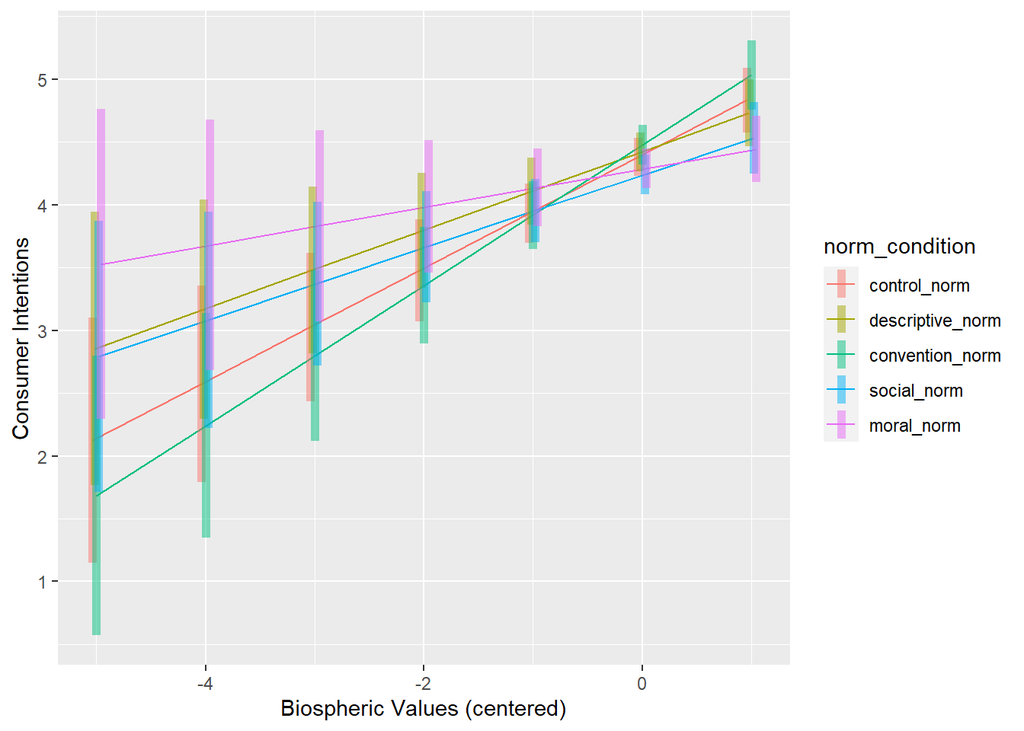

```r
# On a single graph
at_list <- list(biospheric_center = seq(-5, 1.3, by = 1))

emmip(full_model_1a, norm_condition ~ biospheric_center, at = at_list, CIs = TRUE, xlab = "Biospheric Values (centered)", ylab = "Consumer Intentions")
```

- Biospheric values was a significant, positive predictor of consumer intentions in all norm conditions except for the moral norm conditions in which it was a non-significant, positive predictor.

Is the slope of the relationship between biospheric values & consumer intentions stronger in any one of the norm conditions compared to the others?

```r
emtrends(full_model_1a, pairwise~norm_condition, var = "biospheric_center", adjust = "none")
```

```
## $emtrends
##  norm_condition   biospheric_center.trend     SE  df lower.CL upper.CL
##  control_norm                       0.452 0.0996 883   0.2564    0.647
##  descriptive_norm                   0.313 0.1096 883   0.0978    0.528
##  convention_norm                    0.558 0.1127 883   0.3372    0.779
##  social_norm                        0.290 0.1109 883   0.0726    0.508
##  moral_norm                         0.153 0.1223 883  -0.0874    0.392
##
## Results are averaged over the levels of: framing_condition, Gender
## Confidence level used: 0.95
##
## $contrasts
##  contrast                           estimate    SE  df t.ratio p.value
##  control_norm - descriptive_norm      0.1389 0.148 883   0.938  0.3483
##  control_norm - convention_norm      -0.1065 0.150 883  -0.708  0.4792
##  control_norm - social_norm           0.1615 0.149 883   1.083  0.2793
##  control_norm - moral_norm            0.2992 0.158 883   1.899  0.0578
##  descriptive_norm - convention_norm  -0.2454 0.157 883  -1.562  0.1186
##  descriptive_norm - social_norm       0.0227 0.156 883   0.146  0.8843
##  descriptive_norm - moral_norm        0.1603 0.164 883   0.978  0.3284
##  convention_norm - social_norm        0.2680 0.158 883   1.700  0.0895
##  convention_norm - moral_norm         0.4057 0.166 883   2.437  0.0150
##  social_norm - moral_norm             0.1377 0.165 883   0.834  0.4048
##
## Results are averaged over the levels of: framing_condition, Gender
```

Second, relationship between biospheric values & consumer intentions for each framing condition:

```r
emtrends(full_model_1a, ~framing_condition, var = "biospheric_center", adjust = "none")
```

```
##  framing_condition biospheric_center.trend     SE  df lower.CL upper.CL
##  control_framing                     0.343 0.0880 883    0.171    0.516
##  pro_env_framing                     0.403 0.0755 883    0.255    0.551
##  self_enh_framing                    0.313 0.0937 883    0.129    0.497
##
## Results are averaged over the levels of: norm_condition, Gender
## Confidence level used: 0.95
```

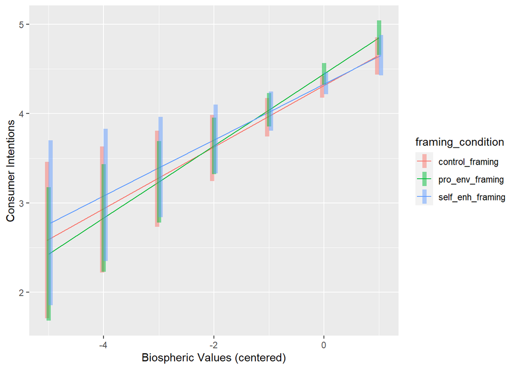

```r
# On a single graph
at_list <- list(biospheric_center = seq(-5, 1.3, by = 1))

emmip(full_model_1a, framing_condition ~ biospheric_center, at = at_list, CIs = TRUE, xlab = "Biospheric Values (centered)", ylab = "Consumer Intentions")
```

- Biospheric values were significantly, positively related to consumer intentions in all framing conditions.

Is the slope of the relationship between biospheric values & consumer intentions stronger in any one of the framing conditions compared to the others?

```r
emtrends(full_model_1a, pairwise~framing_condition, var = "biospheric_center", adjust = "none")
```

```
## $emtrends
##  framing_condition biospheric_center.trend     SE  df lower.CL upper.CL
##  control_framing                     0.343 0.0880 883    0.171    0.516
##  pro_env_framing                     0.403 0.0755 883    0.255    0.551
##  self_enh_framing                    0.313 0.0937 883    0.129    0.497
##
## Results are averaged over the levels of: norm_condition, Gender
## Confidence level used: 0.95
##
## $contrasts
##  contrast                           estimate    SE  df t.ratio p.value
##  control_framing - pro_env_framing   -0.0598 0.116 883  -0.517  0.6054
##  control_framing - self_enh_framing   0.0308 0.128 883   0.240  0.8106
##  pro_env_framing - self_enh_framing   0.0906 0.120 883   0.754  0.4511
##
## Results are averaged over the levels of: norm_condition, Gender
```

Third, interaction between biospheric values, framing, & norm condition:

```r
emtrends(full_model_1a, ~norm_condition | framing_condition, var = "biospheric_center", adjust = "none")
```

```
## framing_condition = control_framing:
##  norm_condition   biospheric_center.trend    SE  df lower.CL upper.CL
##  control_norm                      0.5386 0.160 883  0.22445    0.853
##  descriptive_norm                  0.5155 0.206 883  0.11036    0.921
##  convention_norm                   0.8138 0.195 883  0.43047    1.197
##  social_norm                      -0.0367 0.171 883 -0.37242    0.299
##  moral_norm                       -0.1140 0.241 883 -0.58676    0.359
##
## framing_condition = pro_env_framing:
##  norm_condition   biospheric_center.trend    SE  df lower.CL upper.CL
##  control_norm                      0.2920 0.161 883 -0.02342    0.607
##  descriptive_norm                  0.1860 0.174 883 -0.15549    0.528
##  convention_norm                   0.6157 0.189 883  0.24424    0.987
##  social_norm                       0.4477 0.160 883  0.13428    0.761
##  moral_norm                        0.4751 0.159 883  0.16372    0.786
##
## framing_condition = self_enh_framing:
##  norm_condition   biospheric_center.trend    SE  df lower.CL upper.CL
##  control_norm                      0.5247 0.194 883  0.14322    0.906
##  descriptive_norm                  0.2371 0.186 883 -0.12849    0.603
##  convention_norm                   0.2453 0.200 883 -0.14807    0.639
##  social_norm                       0.4597 0.236 883 -0.00285    0.922
##  moral_norm                        0.0966 0.227 883 -0.34797    0.541
##
## Results are averaged over the levels of: Gender
## Confidence level used: 0.95
```

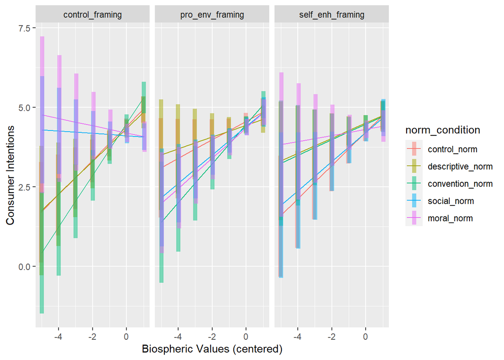

```r
# Separate graph for each framing condition
at_list <- list(biospheric_center = seq(-5, 1.3, by = 1))

emmip(full_model_1a, norm_condition ~ biospheric_center | framing_condition, at = at_list, CIs = TRUE, xlab = "Biospheric Values (centered)", ylab = "Consumer Intentions")
```

- In the control framing condition, biospheric values were significantly, positively related to consumer intentions in the **control norm**, **descriptive norm**, and **convention** conditions but non-significantly, negatively related in the **social norm** and **moral norm** conditions.
- In the pro-environmental framing condition, biospheric values were significantly, positively realted to consumer intentions in the **convention**, **social norm** and **moral norm** conditions, and non-significantly, positively related in the **control norm** and **descriptive norm** conditions.
- In the self-enhancing framing condition, biospheric values were significantly, positively related to consumer intentions in the **control norm** condition, but non-significantly, positively related in all other norm conditions.

### Altruistic Values

First, relationship between altruistic values & consumer intentions for each norm condition:

```r
emtrends(full_model_1a, ~norm_condition, var = "altruistic_center", adjust = "none")
```

```
##  norm_condition   altruistic_center.trend    SE  df lower.CL upper.CL
##  control_norm                      0.2435 0.154 883  -0.0585    0.545
##  descriptive_norm                 -0.1085 0.143 883  -0.3900    0.173
##  convention_norm                  -0.0371 0.140 883  -0.3128    0.239
##  social_norm                       0.1312 0.159 883  -0.1812    0.444
##  moral_norm                        0.4151 0.139 883   0.1432    0.687
##
## Results are averaged over the levels of: framing_condition, Gender
## Confidence level used: 0.95
```

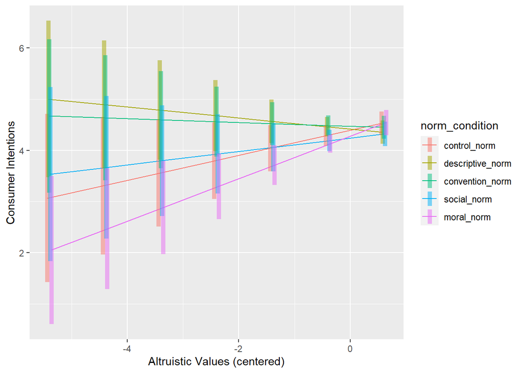

```r
# On a single graph
at_list <- list(altruistic_center = seq(-5.4, 1, by = 1))

emmip(full_model_1a, norm_condition ~ altruistic_center, at = at_list, CIs = TRUE, xlab = "Altruistic Values (centered)", ylab = "Consumer Intentions")
```

- Altruistic values was a non-significant predictor of consumer intentions in the **control norm**, **descriptive norm**, **convention**, and **social norm** conditions.
- Altruistic values was a significant, positive predictor of consumer intentions in the **moral norm** condition.

Is the slope of the relationship between altruistic values & consumer intentions stronger in any one of the norm conditions compared to the others?

```r
emtrends(full_model_1a, pairwise~norm_condition, var = "altruistic_center", adjust = "none")
```

```
## $emtrends
##  norm_condition   altruistic_center.trend    SE  df lower.CL upper.CL
##  control_norm                      0.2435 0.154 883  -0.0585    0.545
##  descriptive_norm                 -0.1085 0.143 883  -0.3900    0.173
##  convention_norm                  -0.0371 0.140 883  -0.3128    0.239
##  social_norm                       0.1312 0.159 883  -0.1812    0.444
##  moral_norm                        0.4151 0.139 883   0.1432    0.687
##
## Results are averaged over the levels of: framing_condition, Gender
## Confidence level used: 0.95
##
## $contrasts
##  contrast                           estimate    SE  df t.ratio p.value
##  control_norm - descriptive_norm      0.3520 0.210 883   1.679  0.0936
##  control_norm - convention_norm       0.2806 0.207 883   1.357  0.1752
##  control_norm - social_norm           0.1123 0.220 883   0.510  0.6101
##  control_norm - moral_norm           -0.1716 0.205 883  -0.835  0.4039
##  descriptive_norm - convention_norm  -0.0714 0.200 883  -0.356  0.7216
##  descriptive_norm - social_norm      -0.2397 0.214 883  -1.120  0.2629
##  descriptive_norm - moral_norm       -0.5236 0.199 883  -2.631  0.0087
##  convention_norm - social_norm       -0.1683 0.212 883  -0.795  0.4267
##  convention_norm - moral_norm        -0.4522 0.196 883  -2.303  0.0215
##  social_norm - moral_norm            -0.2839 0.210 883  -1.350  0.1773
##
## Results are averaged over the levels of: framing_condition, Gender
```

Second, relationship between altruistic values & consumer intentions for each framing condition:

```r
emtrends(full_model_1a, ~framing_condition, var = "altruistic_center", adjust = "none")
```

```
##  framing_condition altruistic_center.trend    SE  df lower.CL upper.CL
##  control_framing                    0.1708 0.114 883  -0.0536    0.395
##  pro_env_framing                    0.0501 0.104 883  -0.1536    0.254
##  self_enh_framing                   0.1655 0.124 883  -0.0778    0.409
##
## Results are averaged over the levels of: norm_condition, Gender
## Confidence level used: 0.95
```

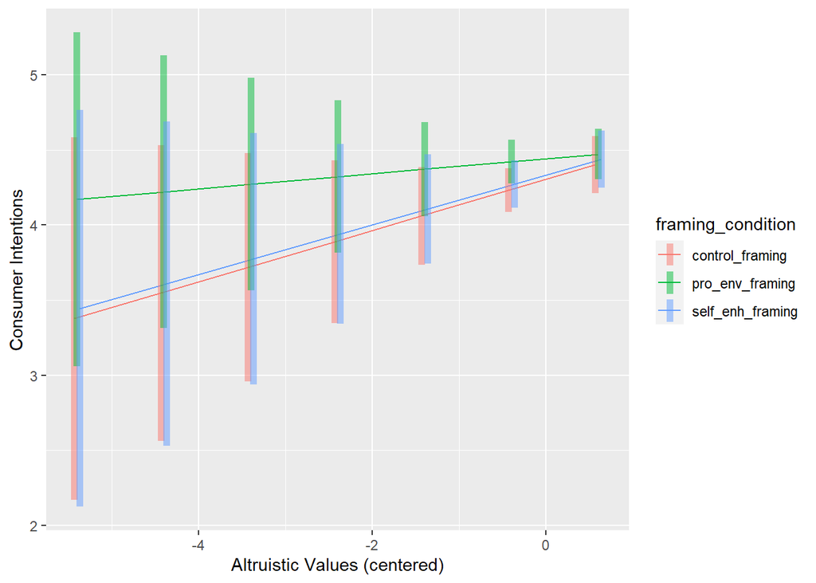

```r
# On a single graph
at_list <- list(altruistic_center = seq(-5.4, 1, by = 1))

emmip(full_model_1a, framing_condition ~ altruistic_center, at = at_list, CIs = TRUE, xlab = "Altruistic Values (centered)", ylab = "Consumer Intentions")
```

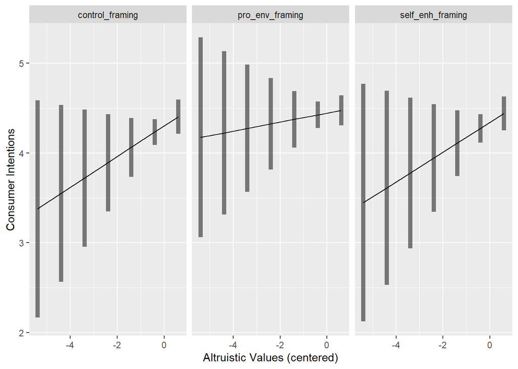

```r
# Separate graph for each norm
emmip(full_model_1a, ~ altruistic_center | framing_condition, at = at_list, CIs = TRUE, xlab = "Altruistic Values (centered)", ylab = "Consumer Intentions")
```

- Altruistic values are positively, but non-significantly, related to consumer intentions in each framing condition.

Is the slope of the relationship between altruistic values & consumer intentions stronger in any one of the framing conditions compared to the others?

```r
emtrends(full_model_1a, pairwise~framing_condition, var = "altruistic_center", adjust = "none")
```

```
## $emtrends
##  framing_condition altruistic_center.trend    SE  df lower.CL upper.CL
##  control_framing                    0.1708 0.114 883  -0.0536    0.395
##  pro_env_framing                    0.0501 0.104 883  -0.1536    0.254
##  self_enh_framing                   0.1655 0.124 883  -0.0778    0.409
##
## Results are averaged over the levels of: norm_condition, Gender
## Confidence level used: 0.95
##
## $contrasts
##  contrast                           estimate    SE  df t.ratio p.value
##  control_framing - pro_env_framing   0.12065 0.153 883   0.788  0.4310
##  control_framing - self_enh_framing  0.00524 0.167 883   0.031  0.9750
##  pro_env_framing - self_enh_framing -0.11541 0.161 883  -0.718  0.4729
##
## Results are averaged over the levels of: norm_condition, Gender
```

Third, interaction between altruistic values, framing, & norm condition:

```r
emtrends(full_model_1a, ~norm_condition | framing_condition, var = "altruistic_center", adjust = "none")
```

```
## framing_condition = control_framing:
##  norm_condition   altruistic_center.trend    SE  df lower.CL upper.CL
##  control_norm                     0.17410 0.197 883  -0.2126   0.5608
##  descriptive_norm                -0.12142 0.283 883  -0.6760   0.4332
##  convention_norm                 -0.40472 0.246 883  -0.8877   0.0783
##  social_norm                      0.58750 0.248 883   0.1003   1.0747
##  moral_norm                       0.61849 0.287 883   0.0554   1.1816
##
## framing_condition = pro_env_framing:
##  norm_condition   altruistic_center.trend    SE  df lower.CL upper.CL
##  control_norm                     0.11608 0.246 883  -0.3671   0.5993
##  descriptive_norm                 0.06335 0.231 883  -0.3900   0.5167
##  convention_norm                  0.00929 0.223 883  -0.4291   0.4477
##  social_norm                      0.01758 0.247 883  -0.4664   0.5015
##  moral_norm                       0.04439 0.204 883  -0.3564   0.4452
##
## framing_condition = self_enh_framing:
##  norm_condition   altruistic_center.trend    SE  df lower.CL upper.CL
##  control_norm                     0.44023 0.333 883  -0.2136   1.0941
##  descriptive_norm                -0.26741 0.228 883  -0.7150   0.1802
##  convention_norm                  0.28416 0.258 883  -0.2220   0.7903
##  social_norm                     -0.21155 0.324 883  -0.8477   0.4246
##  moral_norm                       0.58230 0.218 883   0.1553   1.0093
##
## Results are averaged over the levels of: Gender
## Confidence level used: 0.95
```

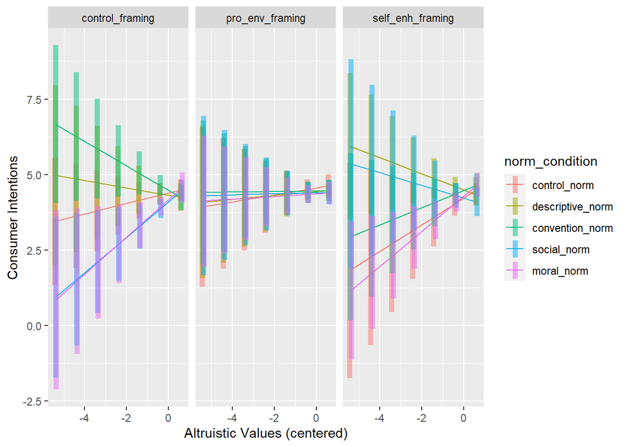

```r
# Separate graph for each framing condition
at_list <- list(altruistic_center = seq(-5.4, 1, by = 1))

emmip(full_model_1a, norm_condition ~ altruistic_center | framing_condition, at = at_list, CIs = TRUE, xlab = "Altruistic Values (centered)", ylab = "Consumer Intentions")
```

- In the control framing condition, altruistic values were significantly, positively related to consumer intentions in the **social norm** and **moral norm** conditions, but non-significantly related in the **control norm**, **descriptive norm**, and **convention** conditions.
- In the pro-environmental framing condition, altruistic values were not significantly related to consumer intentions in any of the norm conditions.
- In the self-enhancing framing condition, altruistic values were significantly, positively related to consumer intentions in the **moral norm** condition, but non-significantly related in all other norm conditions.

### Egoistic Values

First, relationship between egoistic values & consumer intentions for each norm condition:

```r
emtrends(full_model_1a, ~norm_condition, var = "egoistic_center", adjust = "none")
```

```
##  norm_condition   egoistic_center.trend     SE  df lower.CL upper.CL
##  control_norm                    -0.399 0.0963 883   -0.588  -0.2100
##  descriptive_norm                -0.378 0.1166 883   -0.607  -0.1494
##  convention_norm                 -0.402 0.0952 883   -0.589  -0.2152
##  social_norm                     -0.325 0.0992 883   -0.519  -0.1301
##  moral_norm                      -0.259 0.1068 883   -0.468  -0.0492
##
## Results are averaged over the levels of: framing_condition, Gender
## Confidence level used: 0.95
```

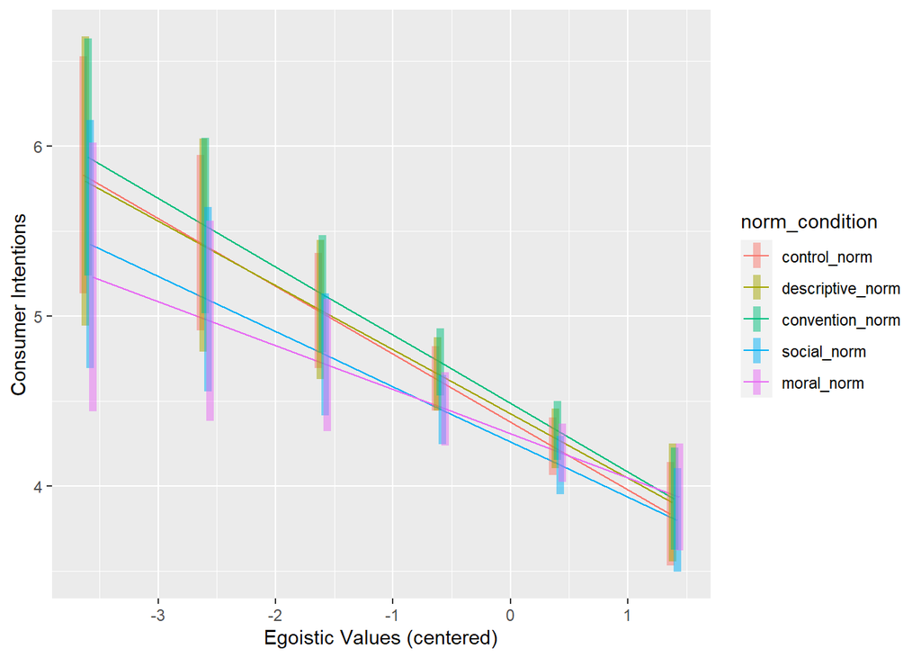

```r
# On a single graph
at_list <- list(egoistic_center = seq(-3.6, 2.2, by = 1))

emmip(full_model_1a, norm_condition ~ egoistic_center, at = at_list, CIs = TRUE, xlab = "Egoistic Values (centered)", ylab = "Consumer Intentions")
```

- Egoistic values were a significant, negative predictor of consumer intentions within each norm condition

Is the slope of the relationship between egoistic values & consumer intentions stronger in any one of the norm conditions compared to the others?

```r
emtrends(full_model_1a, pairwise~norm_condition, var = "egoistic_center", adjust = "none")
```

```
## $emtrends
##  norm_condition   egoistic_center.trend     SE  df lower.CL upper.CL
##  control_norm                    -0.399 0.0963 883   -0.588  -0.2100
##  descriptive_norm                -0.378 0.1166 883   -0.607  -0.1494
##  convention_norm                 -0.402 0.0952 883   -0.589  -0.2152
##  social_norm                     -0.325 0.0992 883   -0.519  -0.1301
##  moral_norm                      -0.259 0.1068 883   -0.468  -0.0492
##
## Results are averaged over the levels of: framing_condition, Gender
## Confidence level used: 0.95
##
## $contrasts
##  contrast                           estimate    SE  df t.ratio p.value
##  control_norm - descriptive_norm    -0.02077 0.150 883  -0.138  0.8903
##  control_norm - convention_norm      0.00313 0.135 883   0.023  0.9814
##  control_norm - social_norm         -0.07424 0.138 883  -0.539  0.5897
##  control_norm - moral_norm          -0.14028 0.143 883  -0.981  0.3267
##  descriptive_norm - convention_norm  0.02390 0.150 883   0.159  0.8733
##  descriptive_norm - social_norm     -0.05347 0.152 883  -0.351  0.7256
##  descriptive_norm - moral_norm      -0.11951 0.157 883  -0.760  0.4472
##  convention_norm - social_norm      -0.07737 0.137 883  -0.565  0.5724
##  convention_norm - moral_norm       -0.14341 0.142 883  -1.008  0.3138
##  social_norm - moral_norm           -0.06604 0.145 883  -0.457  0.6481
##
## Results are averaged over the levels of: framing_condition, Gender
```

No, the difference between any two slopes was not significant.

Second, relationship between egoistic values & consumer intentions for each framing condition:

```r
emtrends(full_model_1a, ~framing_condition, var = "egoistic_center", adjust = "none")
```

```
##  framing_condition egoistic_center.trend     SE  df lower.CL upper.CL
##  control_framing                  -0.414 0.0833 883   -0.577   -0.250
##  pro_env_framing                  -0.283 0.0741 883   -0.428   -0.137
##  self_enh_framing                 -0.361 0.0828 883   -0.524   -0.199
##
## Results are averaged over the levels of: norm_condition, Gender
## Confidence level used: 0.95
```

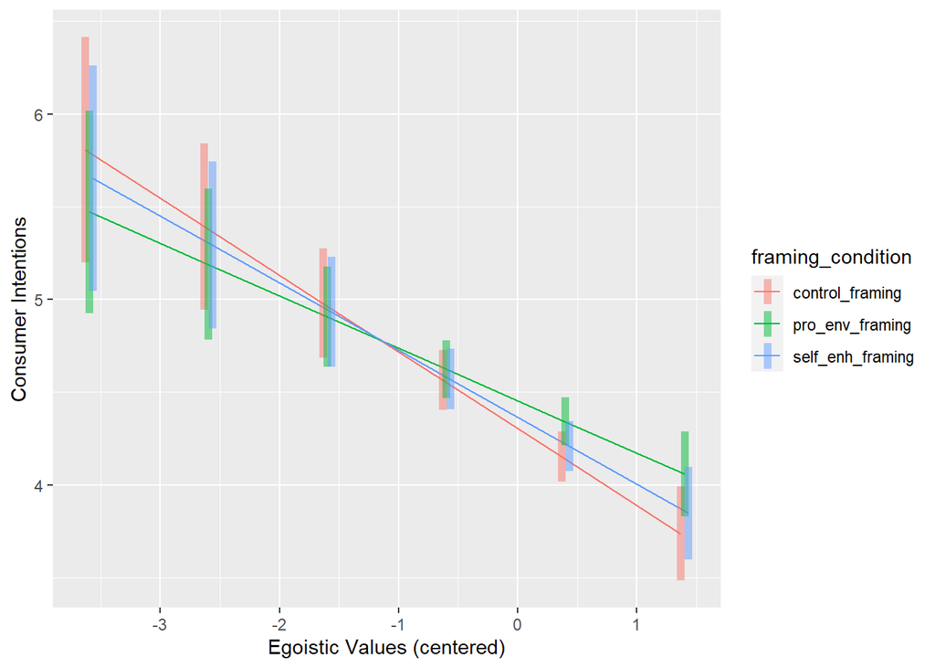

```r
# On a single graph
at_list <- list(egoistic_center = seq(-3.6, 2.2, by = 1))

emmip(full_model_1a, framing_condition ~ egoistic_center, at = at_list, CIs = TRUE, xlab = "Egoistic Values (centered)", ylab = "Consumer Intentions")
```

- Egoistic values were a significant, negative predictor of consumer intentions within each framing condition

Is the slope of the relationship between egoistic values & consumer intentions stronger in any one of the framing conditions compared to the others?

```r
emtrends(full_model_1a, pairwise~framing_condition, var = "egoistic_center", adjust = "none")
```

```
## $emtrends
##  framing_condition egoistic_center.trend     SE  df lower.CL upper.CL
##  control_framing                  -0.414 0.0833 883   -0.577   -0.250
##  pro_env_framing                  -0.283 0.0741 883   -0.428   -0.137
##  self_enh_framing                 -0.361 0.0828 883   -0.524   -0.199
##
## Results are averaged over the levels of: norm_condition, Gender
## Confidence level used: 0.95
##
## $contrasts
##  contrast                           estimate    SE  df t.ratio p.value
##  control_framing - pro_env_framing   -0.1314 0.111 883  -1.188  0.2353
##  control_framing - self_enh_framing  -0.0526 0.116 883  -0.452  0.6513
##  pro_env_framing - self_enh_framing   0.0788 0.110 883   0.716  0.4745
##
## Results are averaged over the levels of: norm_condition, Gender
```

No, the difference between any two slopes was not significant.

Third, interaction between egoistic values, framing, & norm condition:

```r
emtrends(full_model_1a, ~norm_condition | framing_condition, var = "egoistic_center", adjust = "none")
```

```
## framing_condition = control_framing:
##  norm_condition   egoistic_center.trend    SE  df lower.CL upper.CL
##  control_norm                    -0.290 0.162 883   -0.608   0.0282
##  descriptive_norm                -0.736 0.218 883   -1.164  -0.3075
##  convention_norm                 -0.432 0.160 883   -0.746  -0.1186
##  social_norm                     -0.587 0.165 883   -0.912  -0.2629
##  moral_norm                      -0.024 0.210 883   -0.436   0.3880
##
## framing_condition = pro_env_framing:
##  norm_condition   egoistic_center.trend    SE  df lower.CL upper.CL
##  control_norm                    -0.599 0.163 883   -0.919  -0.2790
##  descriptive_norm                -0.253 0.165 883   -0.577   0.0710
##  convention_norm                 -0.110 0.170 883   -0.444   0.2233
##  social_norm                     -0.182 0.167 883   -0.508   0.1452
##  moral_norm                      -0.269 0.160 883   -0.583   0.0449
##
## framing_condition = self_enh_framing:
##  norm_condition   egoistic_center.trend    SE  df lower.CL upper.CL
##  control_norm                    -0.308 0.174 883   -0.649   0.0327
##  descriptive_norm                -0.146 0.216 883   -0.571   0.2788
##  convention_norm                 -0.664 0.163 883   -0.985  -0.3433
##  social_norm                     -0.205 0.180 883   -0.559   0.1480
##  moral_norm                      -0.483 0.180 883   -0.836  -0.1296
##
## Results are averaged over the levels of: Gender
## Confidence level used: 0.95
```

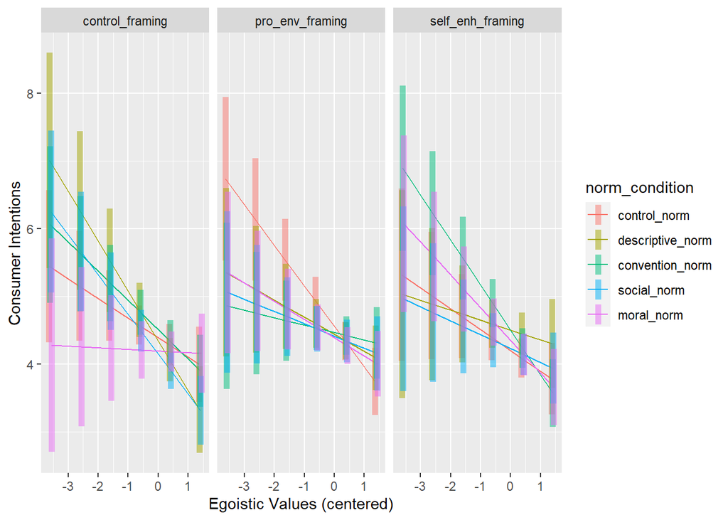

```r
# Separate graph for each framing condition
at_list <- list(egoistic_center = seq(-3.6, 2.2, by = 1))

emmip(full_model_1a, norm_condition ~ egoistic_center | framing_condition, at = at_list, CIs = TRUE, xlab = "Egoistic Values (centered)", ylab = "Consumer Intentions")
```

- In the control framing condition, egoistic values were *not* significantly related to consumer intentions in the **control norm** or **moral norm** conditions (but were signifcantly, negatively related to consumer intentions in the other norm conditions).
- In the pro-environmental framing condition, egoistic values were *not* significantly related to consumer intentions in the **descriptive norm**, **convention**, **social norm**, and **moral norm** conditions (but were still significantly, negatively related in the control norm condition).
- In the self-enhancing framing condition, egoistic values were *not* significantly related to consumer intentions in the **control norm**, **descriptive norm** and **social norm** conditions (but were still significantly, negatively related in the convention & moral norm conditions).

### Hedoninc Values

First, relationship between hedonic values & consumer intentions for each norm condition:

```r
emtrends(full_model_1a, ~norm_condition, var = "hedonic_center", adjust = "none")
```

```
##  norm_condition   hedonic_center.trend    SE  df lower.CL upper.CL
##  control_norm                 -0.12422 0.131 883  -0.3820   0.1335
##  descriptive_norm             -0.00569 0.140 883  -0.2798   0.2684
##  convention_norm               0.16732 0.119 883  -0.0659   0.4005
##  social_norm                  -0.20636 0.131 883  -0.4641   0.0514
##  moral_norm                   -0.32713 0.122 883  -0.5658  -0.0884
##
## Results are averaged over the levels of: framing_condition, Gender
## Confidence level used: 0.95
```

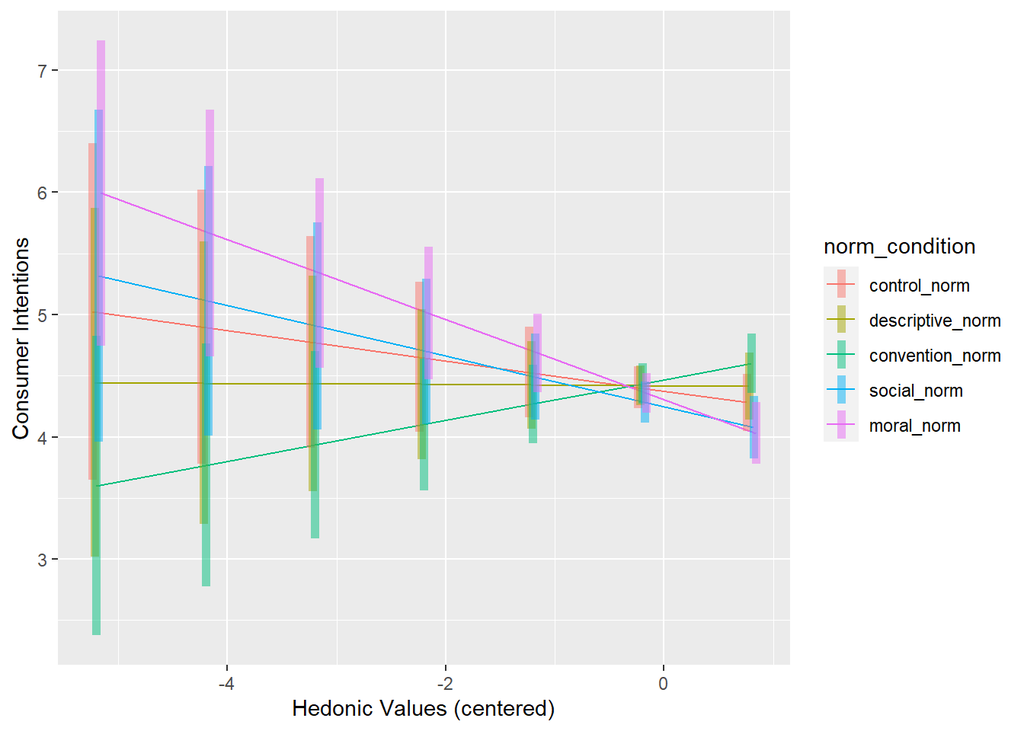

```r
# On a single graph
at_list <- list(hedonic_center = seq(-5.2, 1.2, by = 1))

emmip(full_model_1a, norm_condition ~ hedonic_center, at = at_list, CIs = TRUE, xlab = "Hedonic Values (centered)", ylab = "Consumer Intentions")
```

- Hedonic values were not significantly related to consumer intentions in any norm condition except for the moral norm condition in which they were significantly, negatively related to consumer intentions.

Is the slope of the relationship between hedonic values & consumer intentions stronger in any one of the norm conditions compared to the others?

```r
emtrends(full_model_1a, pairwise~norm_condition, var = "hedonic_center", adjust = "none")
```

```
## $emtrends
##  norm_condition   hedonic_center.trend    SE  df lower.CL upper.CL
##  control_norm                 -0.12422 0.131 883  -0.3820   0.1335
##  descriptive_norm             -0.00569 0.140 883  -0.2798   0.2684
##  convention_norm               0.16732 0.119 883  -0.0659   0.4005
##  social_norm                  -0.20636 0.131 883  -0.4641   0.0514
##  moral_norm                   -0.32713 0.122 883  -0.5658  -0.0884
##
## Results are averaged over the levels of: framing_condition, Gender
## Confidence level used: 0.95
##
## $contrasts
##  contrast                           estimate    SE  df t.ratio p.value
##  control_norm - descriptive_norm     -0.1185 0.192 883  -0.619  0.5363
##  control_norm - convention_norm      -0.2915 0.177 883  -1.646  0.1002
##  control_norm - social_norm           0.0821 0.186 883   0.443  0.6582
##  control_norm - moral_norm            0.2029 0.179 883   1.135  0.2568
##  descriptive_norm - convention_norm  -0.1730 0.183 883  -0.944  0.3456
##  descriptive_norm - social_norm       0.2007 0.192 883   1.046  0.2956
##  descriptive_norm - moral_norm        0.3214 0.185 883   1.737  0.0827
##  convention_norm - social_norm        0.3737 0.177 883   2.110  0.0352
##  convention_norm - moral_norm         0.4944 0.170 883   2.908  0.0037
##  social_norm - moral_norm             0.1208 0.179 883   0.675  0.4998
##
## Results are averaged over the levels of: framing_condition, Gender
```

Second, relationship between hedonic values & consumer intentions for each framing condition:

```r
emtrends(full_model_1a, ~framing_condition, var = "hedonic_center", adjust = "none")
```

```
##  framing_condition hedonic_center.trend     SE  df lower.CL upper.CL
##  control_framing                -0.0845 0.0968 883   -0.275    0.106
##  pro_env_framing                -0.0171 0.0972 883   -0.208    0.174
##  self_enh_framing               -0.1961 0.1050 883   -0.402    0.010
##
## Results are averaged over the levels of: norm_condition, Gender
## Confidence level used: 0.95
```

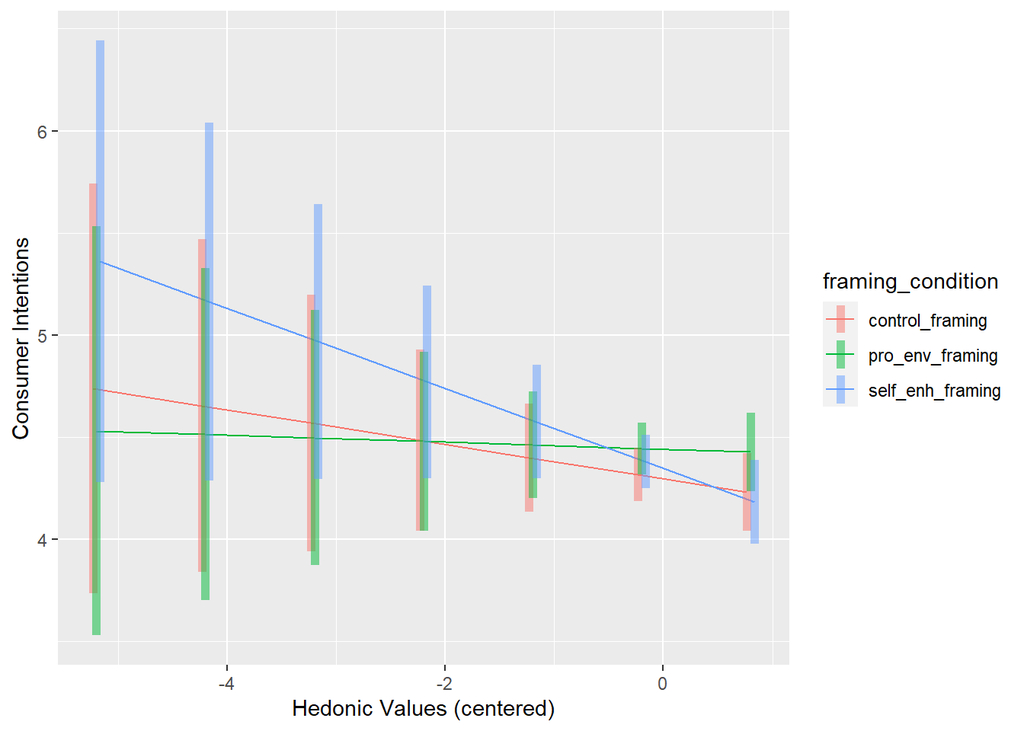

```r
# On a single graph
at_list <- list(hedonic_center = seq(-5.2, 1.2, by = 1))

emmip(full_model_1a, framing_condition ~ hedonic_center, at = at_list, CIs = TRUE, xlab = "Hedonic Values (centered)", ylab = "Consumer Intentions")
```

- Hedonic values were non-significantly, negatively related to consumer intentions in all framing conditions.